# DADA2: Run 2

Eva Kim

10/23/2024

# 1 General Information

There were two runs that went into BioProject PRJNA1111477. This file is for processing files in Run 2, aka the large run in which most of the samples were run.

### 1.0.1 Info for data analysis

For the lung tissue samples, primer sequences have been removed. However, for fecal samples, they will have to be removed.

### 1.0.2 Database

I’m using Silva version 138 with training data formatted for DADA2 from https://zenodo.org/record/3731176#.ZElLBnbMKUl.

### 1.0.3 Codes

Please note that many of the coding lines below are from Dr. Callahan’s [DADA2 tutorial](https://benjjneb.github.io/dada2/tutorial.html).

### 1.0.4 Data availability

For reproducibility, this file assumes that you have download the files from BioProject PRJNA1111477 of NCBI SRA database in `.fastq` format. There should be 293 SRR files under that BioProject. For convenience, I have also downloaded the metadata to convert SRR names to sample names.

# 2 Load libraries

```r
library(dada2)
library(readr)
library(stringr)
library(dplyr)
library(tibble)
library(magrittr)
library(phyloseq)
library(ggplot2)
library(fs)
library(tidyr)
library(ShortRead)
library(Biostrings)
library(tidyverse)
library(vegan)
library(decontam)
library(pals)
library(tools)
library(seqTools)
library(DT)
```

# 3 Directories

```r
rm(list=ls()) # clear environment

# Project-related directories: change as needed!
dmc.dir = file.path("/hpc/group/dmc/Eva") # CHANGE ME to parent directory
git.dir = file.path(dmc.dir, "GLP_KO_Microbiome_Study") # CHANGE ME to Git Directory
data.dir = path.expand(file.path(dmc.dir, paste0("tmp_GLPKO_data"))) # CHANGE ME to where sequencing files are stored (.fastq.gz)

scratch.dir = file.path("/work/yk132/GLP_KO_Microbiome_Study") # CHANGE ME to project work directory
output.dir = path.expand(file.path(scratch.dir, paste0("output")))

map.file = file.path(git.dir, "Metadata_GLP1.csv")
meta.df = read_csv(map.file, show_col_types = FALSE)

sra.file = file.path(git.dir, "GLP1_study_SraRunTable.txt")
sra.df = read_csv(sra.file, show_col_types = FALSE)

if (dir_exists(scratch.dir)) {
  dir_delete(scratch.dir)
}
dir_create(scratch.dir)

filt.dir = path.expand(file.path(scratch.dir,paste0("filt")))
dir_create(filt.dir)

Sys.setenv(OUT_DIR = output.dir)
Sys.setenv(SCRATCH_DIR = scratch.dir)
Sys.setenv(DATA_DIR = data.dir)
Sys.setenv(FILT_DIR = filt.dir)

# Ref database
### Silva v138.1 database formatted for DADA2 is available for download: https://zenodo.org/records/4587955
database.dir = file.path("/hpc/group/dmc/Eva/databases/silva_v138.1") # CHANGE ME to database folder
silva_v138.ref = path.expand(file.path(database.dir, paste0("silva_nr99_v138.1_train_set.fa.gz")))
silva_v138.species.ref =  path.expand(file.path(database.dir, paste0("silva_species_assignment_v138.1.fa.gz")))
```

```r
scratch.dir
```

```
## [1] "/work/yk132/GLP_KO_Microbiome_Study"
```

# 4 Check Metadata and files

After files have been downloaded, there should be:

```r
293*2
```

```
## [1] 586
```

586 files.

```r
sra.df %>% select(`Library Name`, Run) %>%
  dplyr::rename(Label = `Library Name`) %>%
  left_join(meta.df, by = "Label") -> meta.run

meta.run
```

| Label | Run | Concentration-(ng/uL) | Sample_type | Type | Sequencing_Run | Mouse | Cage-Mouse | Genotype | Sex | Diet | Intranasal_Treatment | Surgery | Intranasal_Dose | Cohort | Cage | Week | Lung_index | Kit | DNA_ng_ul_raw | Sample_Label | Cage_Notation | Feces_weight | Orig_label | Notes | Glucose_tolerance_wk0_0m | Glucose_tolerance_wk0_10m | Glucose_tolerance_wk0_30m | Glucose_tolerance_wk0_90m | Weight_g_wk0 | … |
| --- | --- | --- | --- | --- | --- | --- | --- | --- | --- | --- | --- | --- | --- | --- | --- | --- | --- | --- | --- | --- | --- | --- | --- | --- | --- | --- | --- | --- | --- | --- |
| 227 | SRR29054901 | NA | Fecal | True Sample | 2 | JI-727 | 1489566-4 | WT | Female | Normal_Chow | HDM | None | 50ug/40ul | 2 | 1489566 | 10 | NA | PS_2 | 97.00 | NA | 566-4 | 33.5 | 566-4 Fecal wk 10 | NA | 212 | 418 | 311 | 162 | 17.43 | … |
| 226 | SRR29054902 | NA | Fecal | True Sample | 2 | JI-742 | 1489601-3 | WT | Male | Normal_Chow | HDM | None | 50ug/40ul | 2 | 1489601 | 10 | NA | PS_2 | 42.90 | NA | 601-3 | 23.0 | 601-3 Fecal wk 10 | NA | 175 | 342 | 317 | 166 | 22.59 | … |
| 225 | SRR29054903 | NA | Fecal | True Sample | 2 | JI-743 | 1489601-4 | WT | Male | Normal_Chow | PBS | None | 40ul | 2 | 1489601 | 10 | NA | PS_2 | 18.20 | NA | 601-4 | 22.0 | 601-4 Fecal wk 10 | NA | 168 | 391 | 317 | 170 | 23.06 | … |
| 224 | SRR29054904 | NA | Fecal | True Sample | 2 | JI-761 | 1489602-2 | WT | Female | High_Fat_Diet | PBS | None | 40ul | 2 | 1489602 | 10 | NA | PS_2 | 51.00 | NA | 602-2 | 36.5 | 602-2 Fecal wk 10 | NA | 166 | 291 | 234 | 141 | 19.71 | … |
| 223 | SRR29054905 | NA | Fecal | True Sample | 2 | JI-741 | 1489601-2 | WT | Male | Normal_Chow | HDM | None | 50ug/40ul | 2 | 1489601 | 10 | NA | PS_2 | 161.00 | NA | 601-2 | 83.0 | 601-2 Fecal wk 10 | NA | 171 | 354 | 259 | 136 | 22.62 | … |
| 222 | SRR29054906 | NA | Fecal | True Sample | 2 | JI-726 | 1489566-3 | WT | Female | Normal_Chow | PBS | None | 40ul | 2 | 1489566 | 13 | NA | PS_2 | 78.40 | NA | JI-726 | 54.0 | JI-726 Fecal wk 13 | NA | 194 | 395 | 325 | 172 | 19.54 | … |
| 221 | SRR29054907 | NA | Fecal | True Sample | 2 | JI-761 | 1489602-2 | WT | Female | High_Fat_Diet | PBS | None | 40ul | 2 | 1489602 | 0 | NA | PS_2 | 40.90 | NA | 602-2 | 25.5 | 602-2 Fecal wk 0 | NA | 166 | 291 | 234 | 141 | 19.71 | … |
| 220 | SRR29054908 | NA | Fecal | Neg Control | 2 | Blank_2 | NA | NA | NA | NA | NA | NA | NA | NA | NA | NA | NA | PS_2 | 0.01 | Kit_blank_6 | NA | NA | Kit_blank_6 | NA | NA | NA | NA | NA | NA | … |
| 219 | SRR29054909 | NA | Fecal | True Sample | 2 | JI-759 | 1522806/1489569-2 | WT | Female | High_Fat_Diet | PBS | Sham | 40ul | 2 | 1522806 | 10 | NA | PS_2 | 87.90 | NA | 569-2 | 60.0 | 569-2 Fecal wk 10 | NA | 170 | 291 | 198 | 152 | 20.60 | … |
| 218 | SRR29054910 | NA | Fecal | True Sample | 2 | JI-761 | 1489602-2 | WT | Female | High_Fat_Diet | PBS | None | 40ul | 2 | 1489602 | 13 | NA | PS_2 | 17.80 | NA | JI-761 | 49.0 | JI-761 Fecal wk 13 | NA | 166 | 291 | 234 | 141 | 19.71 | … |

[output cut: 283 more lines]

```r
meta.run %>% dplyr::count(Sequencing_Run)
```

| Sequencing_Run | n |
| --- | --- |
| 1 | 11 |
| 2 | 282 |

This file is for Sequencing Run #2.

```r
meta.run %>% filter(Sequencing_Run == 2) -> meta.df
nrow(meta.df)
```

```
## [1] 282
```

# 5 Large Run: DADA2

## 5.1 Remove primers for Fecal Samples only!

Only fecal samples, whose libraries were prepared in-house, have primers still.

```r
meta.df %>% filter(Sample_type == "Fecal") -> meta_F
meta_F
```

| Label | Run | Concentration-(ng/uL) | Sample_type | Type | Sequencing_Run | Mouse | Cage-Mouse | Genotype | Sex | Diet | Intranasal_Treatment | Surgery | Intranasal_Dose | Cohort | Cage | Week | Lung_index | Kit | DNA_ng_ul_raw | Sample_Label | Cage_Notation | Feces_weight | Orig_label | Notes | Glucose_tolerance_wk0_0m | Glucose_tolerance_wk0_10m | Glucose_tolerance_wk0_30m | Glucose_tolerance_wk0_90m | Weight_g_wk0 | … |
| --- | --- | --- | --- | --- | --- | --- | --- | --- | --- | --- | --- | --- | --- | --- | --- | --- | --- | --- | --- | --- | --- | --- | --- | --- | --- | --- | --- | --- | --- | --- |
| 227 | SRR29054901 | NA | Fecal | True Sample | 2 | JI-727 | 1489566-4 | WT | Female | Normal_Chow | HDM | None | 50ug/40ul | 2 | 1489566 | 10 | NA | PS_2 | 97.00 | NA | 566-4 | 33.5 | 566-4 Fecal wk 10 | NA | 212 | 418 | 311 | 162 | 17.43 | … |
| 226 | SRR29054902 | NA | Fecal | True Sample | 2 | JI-742 | 1489601-3 | WT | Male | Normal_Chow | HDM | None | 50ug/40ul | 2 | 1489601 | 10 | NA | PS_2 | 42.90 | NA | 601-3 | 23.0 | 601-3 Fecal wk 10 | NA | 175 | 342 | 317 | 166 | 22.59 | … |
| 225 | SRR29054903 | NA | Fecal | True Sample | 2 | JI-743 | 1489601-4 | WT | Male | Normal_Chow | PBS | None | 40ul | 2 | 1489601 | 10 | NA | PS_2 | 18.20 | NA | 601-4 | 22.0 | 601-4 Fecal wk 10 | NA | 168 | 391 | 317 | 170 | 23.06 | … |
| 224 | SRR29054904 | NA | Fecal | True Sample | 2 | JI-761 | 1489602-2 | WT | Female | High_Fat_Diet | PBS | None | 40ul | 2 | 1489602 | 10 | NA | PS_2 | 51.00 | NA | 602-2 | 36.5 | 602-2 Fecal wk 10 | NA | 166 | 291 | 234 | 141 | 19.71 | … |
| 223 | SRR29054905 | NA | Fecal | True Sample | 2 | JI-741 | 1489601-2 | WT | Male | Normal_Chow | HDM | None | 50ug/40ul | 2 | 1489601 | 10 | NA | PS_2 | 161.00 | NA | 601-2 | 83.0 | 601-2 Fecal wk 10 | NA | 171 | 354 | 259 | 136 | 22.62 | … |
| 222 | SRR29054906 | NA | Fecal | True Sample | 2 | JI-726 | 1489566-3 | WT | Female | Normal_Chow | PBS | None | 40ul | 2 | 1489566 | 13 | NA | PS_2 | 78.40 | NA | JI-726 | 54.0 | JI-726 Fecal wk 13 | NA | 194 | 395 | 325 | 172 | 19.54 | … |
| 221 | SRR29054907 | NA | Fecal | True Sample | 2 | JI-761 | 1489602-2 | WT | Female | High_Fat_Diet | PBS | None | 40ul | 2 | 1489602 | 0 | NA | PS_2 | 40.90 | NA | 602-2 | 25.5 | 602-2 Fecal wk 0 | NA | 166 | 291 | 234 | 141 | 19.71 | … |
| 220 | SRR29054908 | NA | Fecal | Neg Control | 2 | Blank_2 | NA | NA | NA | NA | NA | NA | NA | NA | NA | NA | NA | PS_2 | 0.01 | Kit_blank_6 | NA | NA | Kit_blank_6 | NA | NA | NA | NA | NA | NA | … |
| 219 | SRR29054909 | NA | Fecal | True Sample | 2 | JI-759 | 1522806/1489569-2 | WT | Female | High_Fat_Diet | PBS | Sham | 40ul | 2 | 1522806 | 10 | NA | PS_2 | 87.90 | NA | 569-2 | 60.0 | 569-2 Fecal wk 10 | NA | 170 | 291 | 198 | 152 | 20.60 | … |
| 218 | SRR29054910 | NA | Fecal | True Sample | 2 | JI-761 | 1489602-2 | WT | Female | High_Fat_Diet | PBS | None | 40ul | 2 | 1489602 | 13 | NA | PS_2 | 17.80 | NA | JI-761 | 49.0 | JI-761 Fecal wk 13 | NA | 166 | 291 | 234 | 141 | 19.71 | … |

[output cut: 220 more lines]

```r
meta_F$Run -> sample.names.fecal
sample.names.fecal
```

```
##   [1] "SRR29054901" "SRR29054902" "SRR29054903" "SRR29054904" "SRR29054905"
##   [6] "SRR29054906" "SRR29054907" "SRR29054908" "SRR29054909" "SRR29054910"
##  [11] "SRR29054911" "SRR29054912" "SRR29054913" "SRR29054914" "SRR29054915"
##  [16] "SRR29054916" "SRR29054917" "SRR29054922" "SRR29054933" "SRR29054944"
##  [21] "SRR29054951" "SRR29054952" "SRR29054953" "SRR29054954" "SRR29054955"
##  [26] "SRR29054956" "SRR29054957" "SRR29054958" "SRR29054959" "SRR29054960"
##  [31] "SRR29054961" "SRR29054962" "SRR29054963" "SRR29054964" "SRR29054967"
##  [36] "SRR29054974" "SRR29054975" "SRR29054976" "SRR29054977" "SRR29054978"
##  [41] "SRR29054979" "SRR29054980" "SRR29054981" "SRR29054982" "SRR29054983"
##  [46] "SRR29054984" "SRR29054985" "SRR29054986" "SRR29054987" "SRR29054988"
##  [51] "SRR29054989" "SRR29054990" "SRR29054991" "SRR29054992" "SRR29054993"
##  [56] "SRR29054994" "SRR29054995" "SRR29054996" "SRR29054997" "SRR29054998"
##  [61] "SRR29054999" "SRR29055000" "SRR29055001" "SRR29055002" "SRR29055003"
##  [66] "SRR29055004" "SRR29055005" "SRR29055006" "SRR29055007" "SRR29055008"
##  [71] "SRR29055009" "SRR29055010" "SRR29055011" "SRR29055012" "SRR29055013"
```

[output cut: 31 more lines]

```r
fnFs_fecal <- file.path(data.dir, paste0(sample.names.fecal, "_1.fastq"))
fnRs_fecal <- file.path(data.dir, paste0(sample.names.fecal, "_2.fastq"))
names(fnFs_fecal) <- sample.names.fecal
names(fnRs_fecal) <- sample.names.fecal
```

```r
length(fnRs_fecal)
```

```
## [1] 230
```

Since I did not use heterogeneous spacers, I will use the `FilterAndTrim` function in DADA2 to remove primers. Please note that lung tissue samples do not require primer / barcode removal.

### 5.1.1 Data Quality: Fecal Samples

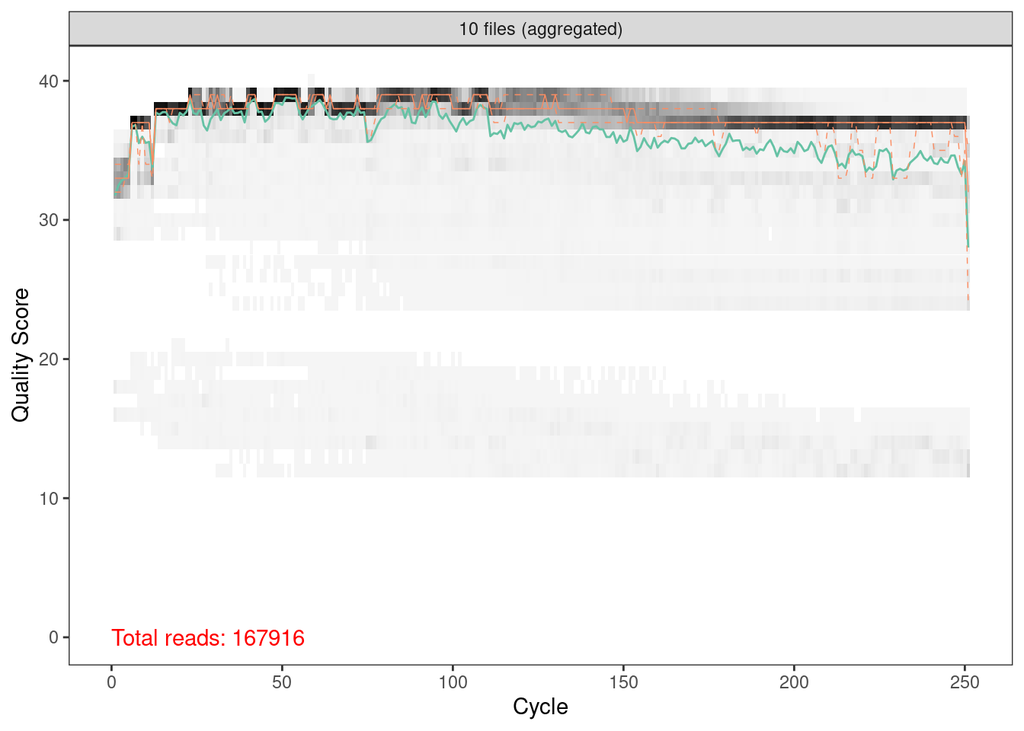

```r
plotQualityProfile(fnFs_fecal[c(1:10)], aggregate = T) # 10 fecal samples
```

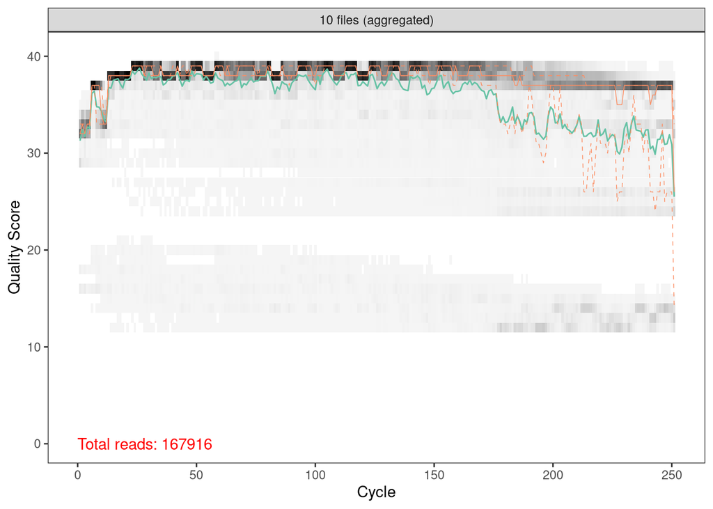

```r
plotQualityProfile(fnRs_fecal[c(1:10)], aggregate = T)
```

The forward primer sequence is 19 bp long, and the reverse primer sequence is 20 bp long.

### 5.1.2 Filter And Trim: Fecal samples

```r
filtFs_Fecal <- file.path(filt.dir, "filtered", paste0(sample.names.fecal, "_F_filt.fastq.gz"))
filtRs_Fecal <- file.path(filt.dir, "filtered", paste0(sample.names.fecal, "_R_filt.fastq.gz"))
names(filtFs_Fecal) <- sample.names.fecal
names(filtRs_Fecal) <- sample.names.fecal
```

```r
filt.out_Fecal <- filterAndTrim(fnFs_fecal, filtFs_Fecal, fnRs_fecal, filtRs_Fecal,
                          trimLeft = 19, trimRight = 20, # remove primers
                          maxN=0, maxEE=c(2,2), truncQ=2, rm.phix=TRUE,
                          compress=TRUE, multithread=TRUE)
```

```
## Creating output directory: /work/yk132/GLP_KO_Microbiome_Study/filt/filtered
```

```
## Some input samples had no reads pass the filter.
```

```r
filtFs.survived_Fecal <- sort(list.files(path.expand(file.path(filt.dir,paste0("filtered"))), pattern="_F_filt.fastq.gz", full.names = TRUE))
filtRs.survived_Fecal <- sort(list.files(path.expand(file.path(filt.dir,paste0("filtered"))), pattern="_R_filt.fastq.gz", full.names = TRUE))

end = "_F_filt.fastq.gz"
filtFs.survived_Fecal %>%
  basename %>%
  str_replace(end, "") -> sample.names.filter.fecal

sample.names.fecal[which(!sample.names.fecal %in% sample.names.filter.fecal)] # See which reads did not survive filter
```

```
## [1] "SRR29054951" "SRR29055043"
```

```r
meta.df %>% filter(Run ==  "SRR29054951"|Run == "SRR29055043")
```

| Label | Run | Concentration-(ng/uL) | Sample_type | Type | Sequencing_Run | Mouse | Cage-Mouse | Genotype | Sex | Diet | Intranasal_Treatment | Surgery | Intranasal_Dose | Cohort | Cage | Week | Lung_index | Kit | DNA_ng_ul_raw | Sample_Label | Cage_Notation | Feces_weight | Orig_label | Notes | Glucose_tolerance_wk0_0m | Glucose_tolerance_wk0_10m | Glucose_tolerance_wk0_30m | Glucose_tolerance_wk0_90m | Weight_g_wk0 | … |
| --- | --- | --- | --- | --- | --- | --- | --- | --- | --- | --- | --- | --- | --- | --- | --- | --- | --- | --- | --- | --- | --- | --- | --- | --- | --- | --- | --- | --- | --- | --- |
| PCR-Bl3 | SRR29054951 | 0.01 | Fecal | Neg Control | 2 | NA | NA | NA | NA | NA | NA | NA | NA | NA | NA | NA | NA | NA | NA | NA | NA | NA | NA | NA | NA | NA | NA | NA | NA | … |
| DW5-3 | SRR29055043 | 0.01 | Fecal | Neg Control | 2 | NA | NA | NA | NA | NA | NA | NA | NA | NA | NA | NA | NA | NA | NA | NA | NA | NA | NA | NA | NA | NA | NA | NA | NA | … |

Only the two blanks did not survive the filtering step.

Check that primers are removed:

```r
FWD <- "GTGYCAGCMGCCGCGGTAA"   # full primer seq TCGTCGGCAGCGTCAGATGTGTATAAGAGACAGGTGYCAGCMGCCGCGGTAA  515F
REV <- "GGACTACNVGGGTWTCTAAT"  # full primre seq GTCTCGTGGGCTCGGAGATGTGTATAAGAGACAGGGACTACNVGGGTWTCTAAT 806rB

allOrients <- function(primer) {
    # Create all orientations of the input sequence
    require(Biostrings)
    dna <- DNAString(primer)  # The Biostrings works w/ DNAString objects rather than character vectors
    orients <- c(Forward = dna, Complement = complement(dna), Reverse = reverse(dna),
        RevComp = reverseComplement(dna))
    return(sapply(orients, toString))  # Convert back to character vector
}
FWD.orients <- allOrients(FWD)
REV.orients <- allOrients(REV)

primerHits <- function(primer, fn) {
    # Counts number of reads in which the primer is found
    nhits <- vcountPattern(primer, sread(readFastq(fn)), fixed = FALSE)
    return(sum(nhits > 0))
}

rbind(FWD.ForwardReads = sapply(FWD.orients, primerHits, fn = filtFs_Fecal[[1]]),
    FWD.ReverseReads = sapply(FWD.orients, primerHits, fn = filtRs_Fecal[[1]]),
    REV.ForwardReads = sapply(REV.orients, primerHits, fn = filtFs_Fecal[[1]]),
    REV.ReverseReads = sapply(REV.orients, primerHits, fn = filtRs_Fecal[[1]]))
```

```
##                  Forward Complement Reverse RevComp
## FWD.ForwardReads       0          0       0       0
## FWD.ReverseReads       0          0       0       0
## REV.ForwardReads       0          0       0       0
## REV.ReverseReads       0          0       0       0
```

And here is the data quality after trimming:

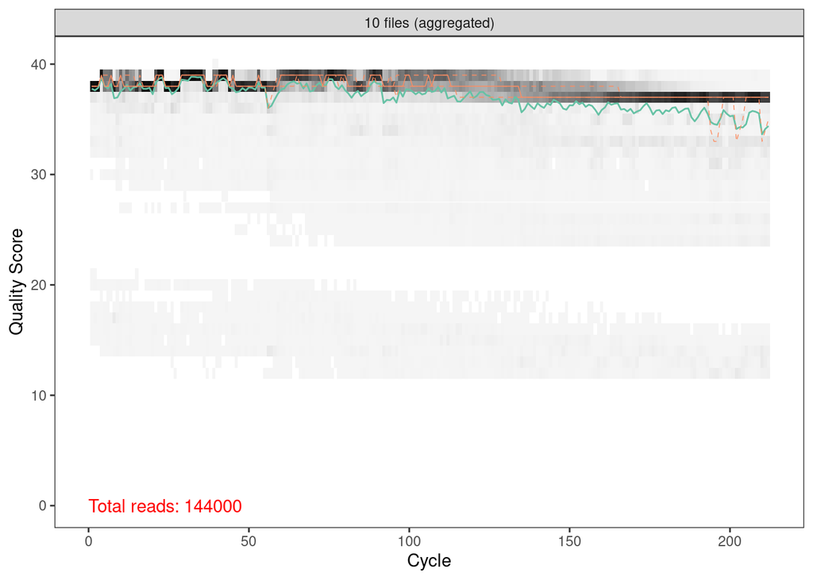

```r
plotQualityProfile(filtFs_Fecal[c(1:10)], aggregate = T) # 10 fecal samples
```

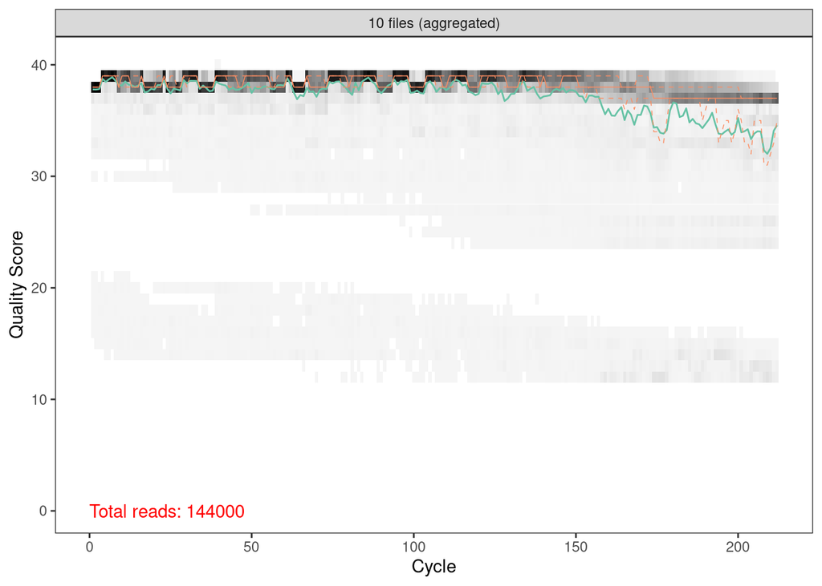

```r
plotQualityProfile(filtRs_Fecal[c(1:10)], aggregate = T)
```

## 5.2 Filter and Trim lung tissue samples

The primers are already removed for the lung tissue samples, but it should still undergo the same filtering step (minus the trimming).

```r
meta.df %>% filter(Sample_type == "Lung Tissue") -> meta_LT
meta_LT
```

| Label | Run | Concentration-(ng/uL) | Sample_type | Type | Sequencing_Run | Mouse | Cage-Mouse | Genotype | Sex | Diet | Intranasal_Treatment | Surgery | Intranasal_Dose | Cohort | Cage | Week | Lung_index | Kit | DNA_ng_ul_raw | Sample_Label | Cage_Notation | Feces_weight | Orig_label | Notes | Glucose_tolerance_wk0_0m | Glucose_tolerance_wk0_10m | Glucose_tolerance_wk0_30m | Glucose_tolerance_wk0_90m | Weight_g_wk0 | … |
| --- | --- | --- | --- | --- | --- | --- | --- | --- | --- | --- | --- | --- | --- | --- | --- | --- | --- | --- | --- | --- | --- | --- | --- | --- | --- | --- | --- | --- | --- | --- |
| JI-689 | SRR29054918 | NA | Lung Tissue | True Sample | 2 | JI-689 | 1477812/1420964-3 | KO | Female | High_Fat_Diet | PBS | Sham | 40ul | 1 | 1477812 | 13 | 41 | BT_1 | 489.00 | NA | NA | NA | NA | NA | NA | NA | NA | NA | 19.26 | … |
| JI-688-Redo | SRR29054919 | NA | Lung Tissue | True Sample | 2 | JI-688 | 1477807/1467746-1 | KO | Female | High_Fat_Diet | HDM | VSG | 50ug/40ul | 1 | 1477807 | 13 | 40 | BT_1 | 42.00 | NA | NA | NA | NA | NA | NA | NA | NA | NA | 19.34 | … |
| JI-687 | SRR29054921 | NA | Lung Tissue | True Sample | 2 | JI-687 | 1477817/1467744-1 | KO | Female | High_Fat_Diet | HDM | Sham | 50ug/40ul | 1 | 1477817 | 13 | 34 | BT_1 | 173.00 | NA | NA | NA | NA | NA | 183 | 295 | 235 | 171 | 17.91 | … |
| JI-686 | SRR29054923 | NA | Lung Tissue | True Sample | 2 | JI-686 | 1477811/1420964-5 | KO | Female | High_Fat_Diet | PBS | VSG | 40ul | 1 | 1477811 | 13 | 4 | BT_1 | 330.00 | NA | NA | NA | NA | NA | NA | NA | NA | NA | 18.24 | … |
| JI-685 | SRR29054924 | NA | Lung Tissue | True Sample | 2 | JI-685 | 1420959-3 | KO | Female | Normal_Chow | HDM | None | 50ug/40ul | 1 | 1420959 | 13 | 35 | BT_1 | 131.00 | NA | NA | NA | NA | NA | 172 | 350 | 301 | 160 | 18.23 | … |
| JI-684 | SRR29054925 | NA | Lung Tissue | True Sample | 2 | JI-684 | 1420959-2 | KO | Female | Normal_Chow | PBS | None | 40ul | 1 | 1420959 | 13 | 46 | BT_1 | 351.00 | NA | NA | NA | NA | NA | 176 | 307 | 211 | 148 | 19.66 | … |
| JI-683 | SRR29054926 | NA | Lung Tissue | True Sample | 2 | JI-683 | 1420959-1 | KO | Female | Normal_Chow | HDM | None | 50ug/40ul | 1 | 1420959 | 13 | 54 | BT_2 | 151.00 | NA | NA | NA | NA | NA | 177 | 280 | 293 | 141 | 19.98 | … |
| JI-682 | SRR29054927 | NA | Lung Tissue | True Sample | 2 | JI-682 | 1420960-3 | WT | Female | High_Fat_Diet | PBS | Sham | 40ul | 1 | 1420960 | 13 | 1 | BT_1 | 464.00 | NA | NA | NA | NA | NA | 207 | 360 | 373 | 176 | 18.72 | … |
| JI-681 | SRR29054928 | NA | Lung Tissue | True Sample | 2 | JI-681 | 1477818/1420960-2 | WT | Female | High_Fat_Diet | HDM | VSG | 50ug/40ul | 1 | 1477818 | 13 | 19 | BT_1 | 420.00 | NA | NA | NA | NA | NA | 168 | 306 | 291 | 156 | 17.74 | … |
| JI-680 | SRR29054929 | NA | Lung Tissue | True Sample | 2 | JI-680 | 1467743-1 | WT | Female | High_Fat_Diet | HDM | None | 50ug/40ul | 1 | 1467743 | 13 | 55 | BT_2 | 187.00 | NA | NA | NA | NA | NA | NA | NA | NA | NA | 17.98 | … |

[output cut: 42 more lines]

```r
meta_LT$Run -> sample.names.lt
sample.names.lt
```

```
##  [1] "SRR29054918" "SRR29054919" "SRR29054921" "SRR29054923" "SRR29054924"
##  [6] "SRR29054925" "SRR29054926" "SRR29054927" "SRR29054928" "SRR29054929"
## [11] "SRR29054930" "SRR29054932" "SRR29054935" "SRR29054936" "SRR29054937"
## [16] "SRR29054938" "SRR29054940" "SRR29054942" "SRR29054943" "SRR29054945"
## [21] "SRR29054947" "SRR29054948" "SRR29054950" "SRR29054965" "SRR29054966"
## [26] "SRR29054969" "SRR29054970" "SRR29054971" "SRR29054972" "SRR29054973"
## [31] "SRR29055035" "SRR29055036" "SRR29055134" "SRR29055135" "SRR29055136"
## [36] "SRR29055137" "SRR29055138" "SRR29055139" "SRR29055140" "SRR29055141"
## [41] "SRR29055142" "SRR29055144" "SRR29055145" "SRR29055146" "SRR29055147"
## [46] "SRR29055149" "SRR29055150" "SRR29055151" "SRR29055152" "SRR29055157"
## [51] "SRR29055158" "SRR29055159"
```

```r
fnFs_LT <- file.path(data.dir, paste0(sample.names.lt, "_1.fastq"))
fnRs_LT <- file.path(data.dir, paste0(sample.names.lt, "_2.fastq"))
names(fnFs_LT) <- sample.names.lt
names(fnRs_LT) <- sample.names.lt
```

```r
length(fnRs_LT)
```

```
## [1] 52
```

## 5.3 Data Quality: Lung Tissue Samples

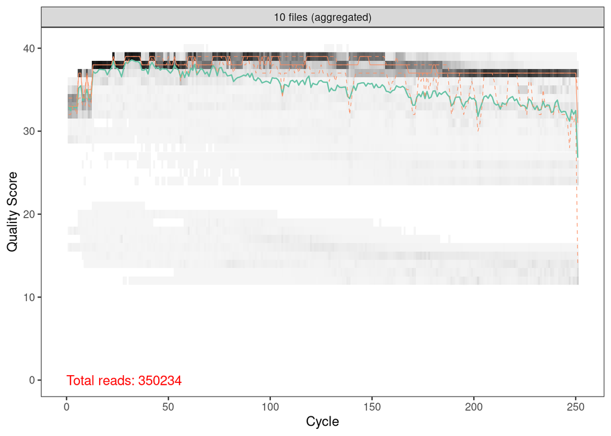

```r
plotQualityProfile(fnFs_LT[c(1:10)], aggregate = T) # 10 LT samples
```

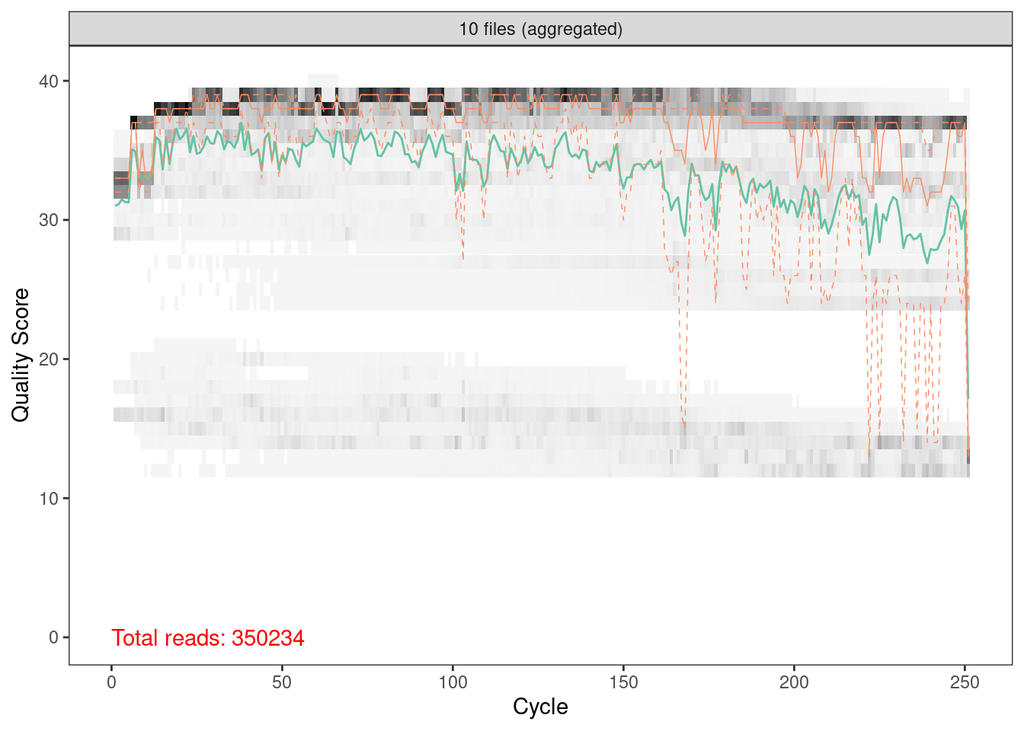

```r
plotQualityProfile(fnRs_LT[c(1:10)], aggregate = T)
```

## 5.4 Filter and Trim

```r
filtFs_LT <- file.path(filt.dir, "filtered", paste0(sample.names.lt, "_F_filt.fastq.gz"))
filtRs_LT <- file.path(filt.dir, "filtered", paste0(sample.names.lt, "_R_filt.fastq.gz"))
names(filtFs_LT) <- sample.names.lt
names(filtRs_LT) <- sample.names.lt
```

```r
length(fnFs_LT)
```

```
## [1] 52
```

```r
length(filtFs_LT) # make sure the lengths match
```

```
## [1] 52
```

```r
filt.out <- filterAndTrim(fnFs_LT, filtFs_LT, fnRs_LT, filtRs_LT,maxN=0, maxEE=c(2, 2), truncQ=2, rm.phix=TRUE,
                          compress=TRUE, multithread=TRUE)  # Primer/barcode already removed so not setting truncation based on length
                                                            # Otherwise same with fecal samples
```

All lung tissue samples survived the filtering step.

## 5.5 Error Correction

Let’s check that the list of files include both lung and fecal samples:

```r
filtFs.survived <- sort(list.files(path.expand(file.path(filt.dir,paste0("filtered"))), pattern="_F_filt.fastq.gz", full.names = TRUE))
filtRs.survived <- sort(list.files(path.expand(file.path(filt.dir,paste0("filtered"))), pattern="_R_filt.fastq.gz", full.names = TRUE))

end = "_F_filt.fastq.gz"
filtFs.survived %>%
  basename %>%
  str_replace(end, "") -> sample.names.filter

meta.df$Run -> sample.names

length(sample.names.filter)
```

```
## [1] 280
```

```r
length(sample.names)
```

```
## [1] 282
```

```r
sample.names[which(!sample.names %in% sample.names.filter)] # See which reads did not survive filter
```

```
## [1] "SRR29054951" "SRR29055043"
```

These are the two negative controls from fecal samples.

```r
errF <- learnErrors(filtFs.survived, multithread=TRUE)
```

```
## 103043421 total bases in 450450 reads from 27 samples will be used for learning the error rates.
```

```r
errR <- learnErrors(filtRs.survived, multithread=TRUE)
```

```
## 103043421 total bases in 450450 reads from 27 samples will be used for learning the error rates.
```

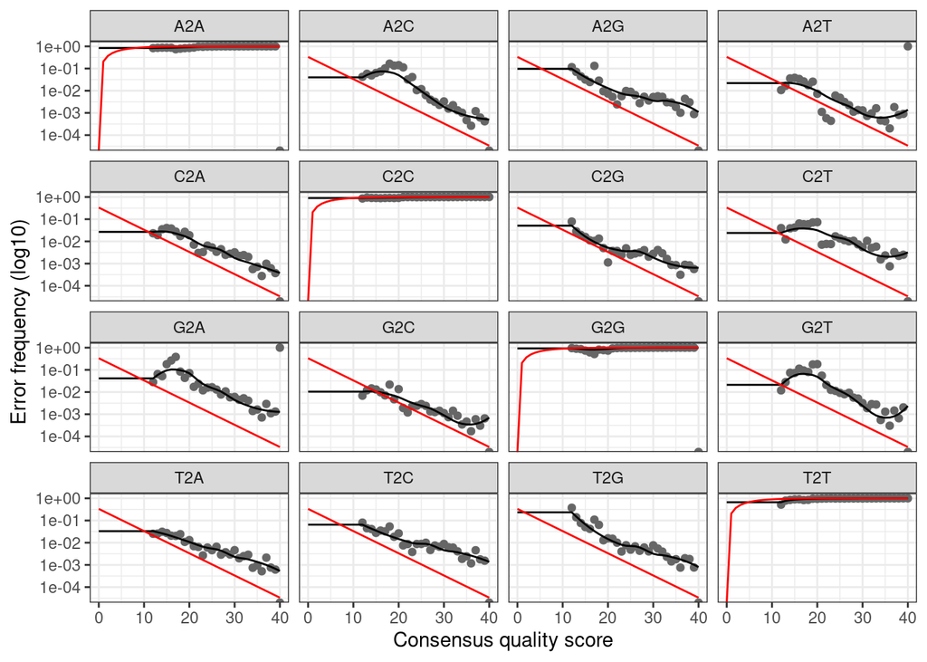

```r
plotErrors(errF, nominalQ=TRUE)
```

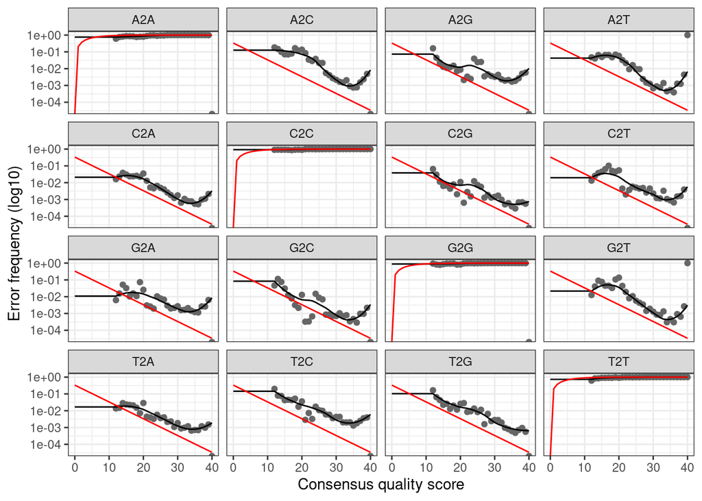

```r
plotErrors(errR, nominalQ=TRUE)
```

## 5.6 Dereplication

```r
derepFs <- derepFastq(filtFs.survived, verbose=TRUE)
```

```
## Dereplicating sequence entries in Fastq file: /work/yk132/GLP_KO_Microbiome_Study/filt/filtered/SRR29054901_F_filt.fastq.gz
```

```
## Encountered 7371 unique sequences from 20015 total sequences read.
```

```
## Dereplicating sequence entries in Fastq file: /work/yk132/GLP_KO_Microbiome_Study/filt/filtered/SRR29054902_F_filt.fastq.gz
```

```
## Encountered 5391 unique sequences from 13949 total sequences read.
```

```
## Dereplicating sequence entries in Fastq file: /work/yk132/GLP_KO_Microbiome_Study/filt/filtered/SRR29054903_F_filt.fastq.gz
```

```
## Encountered 4341 unique sequences from 12680 total sequences read.
```

```
## Dereplicating sequence entries in Fastq file: /work/yk132/GLP_KO_Microbiome_Study/filt/filtered/SRR29054904_F_filt.fastq.gz
```

```
## Encountered 7043 unique sequences from 21678 total sequences read.
```

```
## Dereplicating sequence entries in Fastq file: /work/yk132/GLP_KO_Microbiome_Study/filt/filtered/SRR29054905_F_filt.fastq.gz
```

```
## Encountered 7301 unique sequences from 19231 total sequences read.
```

```
## Dereplicating sequence entries in Fastq file: /work/yk132/GLP_KO_Microbiome_Study/filt/filtered/SRR29054906_F_filt.fastq.gz
```

```
## Encountered 6629 unique sequences from 18159 total sequences read.
```

```
## Dereplicating sequence entries in Fastq file: /work/yk132/GLP_KO_Microbiome_Study/filt/filtered/SRR29054907_F_filt.fastq.gz
```

```
## Encountered 4102 unique sequences from 12902 total sequences read.
```

```
## Dereplicating sequence entries in Fastq file: /work/yk132/GLP_KO_Microbiome_Study/filt/filtered/SRR29054908_F_filt.fastq.gz
```

```
## Encountered 64 unique sequences from 114 total sequences read.
```

```
## Dereplicating sequence entries in Fastq file: /work/yk132/GLP_KO_Microbiome_Study/filt/filtered/SRR29054909_F_filt.fastq.gz
```

```
## Encountered 4961 unique sequences from 17076 total sequences read.
```

```
## Dereplicating sequence entries in Fastq file: /work/yk132/GLP_KO_Microbiome_Study/filt/filtered/SRR29054910_F_filt.fastq.gz
```

```
## Encountered 3057 unique sequences from 8196 total sequences read.
```

```
## Dereplicating sequence entries in Fastq file: /work/yk132/GLP_KO_Microbiome_Study/filt/filtered/SRR29054911_F_filt.fastq.gz
```

```
## Encountered 7678 unique sequences from 26450 total sequences read.
```

```
## Dereplicating sequence entries in Fastq file: /work/yk132/GLP_KO_Microbiome_Study/filt/filtered/SRR29054912_F_filt.fastq.gz
```

```
## Encountered 2869 unique sequences from 7542 total sequences read.
```

```
## Dereplicating sequence entries in Fastq file: /work/yk132/GLP_KO_Microbiome_Study/filt/filtered/SRR29054913_F_filt.fastq.gz
```

```
## Encountered 2950 unique sequences from 7255 total sequences read.
```

```
## Dereplicating sequence entries in Fastq file: /work/yk132/GLP_KO_Microbiome_Study/filt/filtered/SRR29054914_F_filt.fastq.gz
```

```
## Encountered 3597 unique sequences from 10416 total sequences read.
```

```
## Dereplicating sequence entries in Fastq file: /work/yk132/GLP_KO_Microbiome_Study/filt/filtered/SRR29054915_F_filt.fastq.gz
```

```
## Encountered 4665 unique sequences from 14527 total sequences read.
```

```
## Dereplicating sequence entries in Fastq file: /work/yk132/GLP_KO_Microbiome_Study/filt/filtered/SRR29054916_F_filt.fastq.gz
```

```
## Encountered 4095 unique sequences from 10664 total sequences read.
```

```
## Dereplicating sequence entries in Fastq file: /work/yk132/GLP_KO_Microbiome_Study/filt/filtered/SRR29054917_F_filt.fastq.gz
```

```
## Encountered 3737 unique sequences from 10270 total sequences read.
```

```
## Dereplicating sequence entries in Fastq file: /work/yk132/GLP_KO_Microbiome_Study/filt/filtered/SRR29054918_F_filt.fastq.gz
```

```
## Encountered 2069 unique sequences from 25886 total sequences read.
```

```
## Dereplicating sequence entries in Fastq file: /work/yk132/GLP_KO_Microbiome_Study/filt/filtered/SRR29054919_F_filt.fastq.gz
```

```
## Encountered 727 unique sequences from 11095 total sequences read.
```

```
## Dereplicating sequence entries in Fastq file: /work/yk132/GLP_KO_Microbiome_Study/filt/filtered/SRR29054921_F_filt.fastq.gz
```

```
## Encountered 1517 unique sequences from 25477 total sequences read.
```

```
## Dereplicating sequence entries in Fastq file: /work/yk132/GLP_KO_Microbiome_Study/filt/filtered/SRR29054922_F_filt.fastq.gz
```

```
## Encountered 10357 unique sequences from 25787 total sequences read.
```

```
## Dereplicating sequence entries in Fastq file: /work/yk132/GLP_KO_Microbiome_Study/filt/filtered/SRR29054923_F_filt.fastq.gz
```

```
## Encountered 3704 unique sequences from 33382 total sequences read.
```

```
## Dereplicating sequence entries in Fastq file: /work/yk132/GLP_KO_Microbiome_Study/filt/filtered/SRR29054924_F_filt.fastq.gz
```

```
## Encountered 1152 unique sequences from 13277 total sequences read.
```

```
## Dereplicating sequence entries in Fastq file: /work/yk132/GLP_KO_Microbiome_Study/filt/filtered/SRR29054925_F_filt.fastq.gz
```

```
## Encountered 1277 unique sequences from 11795 total sequences read.
```

```
## Dereplicating sequence entries in Fastq file: /work/yk132/GLP_KO_Microbiome_Study/filt/filtered/SRR29054926_F_filt.fastq.gz
```

```
## Encountered 1237 unique sequences from 16572 total sequences read.
```

```
## Dereplicating sequence entries in Fastq file: /work/yk132/GLP_KO_Microbiome_Study/filt/filtered/SRR29054927_F_filt.fastq.gz
```

```
## Encountered 2551 unique sequences from 38689 total sequences read.
```

```
## Dereplicating sequence entries in Fastq file: /work/yk132/GLP_KO_Microbiome_Study/filt/filtered/SRR29054928_F_filt.fastq.gz
```

```
## Encountered 1262 unique sequences from 17366 total sequences read.
```

```
## Dereplicating sequence entries in Fastq file: /work/yk132/GLP_KO_Microbiome_Study/filt/filtered/SRR29054929_F_filt.fastq.gz
```

```
## Encountered 5258 unique sequences from 59313 total sequences read.
```

```
## Dereplicating sequence entries in Fastq file: /work/yk132/GLP_KO_Microbiome_Study/filt/filtered/SRR29054930_F_filt.fastq.gz
```

```
## Encountered 2856 unique sequences from 28915 total sequences read.
```

```
## Dereplicating sequence entries in Fastq file: /work/yk132/GLP_KO_Microbiome_Study/filt/filtered/SRR29054932_F_filt.fastq.gz
```

```
## Encountered 2225 unique sequences from 33418 total sequences read.
```

```
## Dereplicating sequence entries in Fastq file: /work/yk132/GLP_KO_Microbiome_Study/filt/filtered/SRR29054933_F_filt.fastq.gz
```

```
## Encountered 6252 unique sequences from 19183 total sequences read.
```

```
## Dereplicating sequence entries in Fastq file: /work/yk132/GLP_KO_Microbiome_Study/filt/filtered/SRR29054935_F_filt.fastq.gz
```

```
## Encountered 1616 unique sequences from 14916 total sequences read.
```

```
## Dereplicating sequence entries in Fastq file: /work/yk132/GLP_KO_Microbiome_Study/filt/filtered/SRR29054936_F_filt.fastq.gz
```

```
## Encountered 729 unique sequences from 9007 total sequences read.
```

```
## Dereplicating sequence entries in Fastq file: /work/yk132/GLP_KO_Microbiome_Study/filt/filtered/SRR29054937_F_filt.fastq.gz
```

```
## Encountered 2025 unique sequences from 34144 total sequences read.
```

```
## Dereplicating sequence entries in Fastq file: /work/yk132/GLP_KO_Microbiome_Study/filt/filtered/SRR29054938_F_filt.fastq.gz
```

```
## Encountered 889 unique sequences from 14024 total sequences read.
```

```
## Dereplicating sequence entries in Fastq file: /work/yk132/GLP_KO_Microbiome_Study/filt/filtered/SRR29054940_F_filt.fastq.gz
```

```
## Encountered 2584 unique sequences from 21606 total sequences read.
```

```
## Dereplicating sequence entries in Fastq file: /work/yk132/GLP_KO_Microbiome_Study/filt/filtered/SRR29054942_F_filt.fastq.gz
```

```
## Encountered 937 unique sequences from 6759 total sequences read.
```

```
## Dereplicating sequence entries in Fastq file: /work/yk132/GLP_KO_Microbiome_Study/filt/filtered/SRR29054943_F_filt.fastq.gz
```

```
## Encountered 2883 unique sequences from 34064 total sequences read.
```

```
## Dereplicating sequence entries in Fastq file: /work/yk132/GLP_KO_Microbiome_Study/filt/filtered/SRR29054944_F_filt.fastq.gz
```

```
## Encountered 6851 unique sequences from 22004 total sequences read.
```

```
## Dereplicating sequence entries in Fastq file: /work/yk132/GLP_KO_Microbiome_Study/filt/filtered/SRR29054945_F_filt.fastq.gz
```

```
## Encountered 2871 unique sequences from 35694 total sequences read.
```

```
## Dereplicating sequence entries in Fastq file: /work/yk132/GLP_KO_Microbiome_Study/filt/filtered/SRR29054947_F_filt.fastq.gz
```

```
## Encountered 437 unique sequences from 6899 total sequences read.
```

```
## Dereplicating sequence entries in Fastq file: /work/yk132/GLP_KO_Microbiome_Study/filt/filtered/SRR29054948_F_filt.fastq.gz
```

```
## Encountered 1330 unique sequences from 23551 total sequences read.
```

```
## Dereplicating sequence entries in Fastq file: /work/yk132/GLP_KO_Microbiome_Study/filt/filtered/SRR29054950_F_filt.fastq.gz
```

```
## Encountered 939 unique sequences from 20189 total sequences read.
```

```
## Dereplicating sequence entries in Fastq file: /work/yk132/GLP_KO_Microbiome_Study/filt/filtered/SRR29054952_F_filt.fastq.gz
```

```
## Encountered 2 unique sequences from 9 total sequences read.
```

```
## Dereplicating sequence entries in Fastq file: /work/yk132/GLP_KO_Microbiome_Study/filt/filtered/SRR29054953_F_filt.fastq.gz
```

```
## Encountered 11 unique sequences from 18 total sequences read.
```

```
## Dereplicating sequence entries in Fastq file: /work/yk132/GLP_KO_Microbiome_Study/filt/filtered/SRR29054954_F_filt.fastq.gz
```

```
## Encountered 12 unique sequences from 16 total sequences read.
```

```
## Dereplicating sequence entries in Fastq file: /work/yk132/GLP_KO_Microbiome_Study/filt/filtered/SRR29054955_F_filt.fastq.gz
```

```
## Encountered 5 unique sequences from 6 total sequences read.
```

```
## Dereplicating sequence entries in Fastq file: /work/yk132/GLP_KO_Microbiome_Study/filt/filtered/SRR29054956_F_filt.fastq.gz
```

```
## Encountered 5769 unique sequences from 26428 total sequences read.
```

```
## Dereplicating sequence entries in Fastq file: /work/yk132/GLP_KO_Microbiome_Study/filt/filtered/SRR29054957_F_filt.fastq.gz
```

```
## Encountered 5 unique sequences from 5 total sequences read.
```

```
## Dereplicating sequence entries in Fastq file: /work/yk132/GLP_KO_Microbiome_Study/filt/filtered/SRR29054958_F_filt.fastq.gz
```

```
## Encountered 29 unique sequences from 36 total sequences read.
```

```
## Dereplicating sequence entries in Fastq file: /work/yk132/GLP_KO_Microbiome_Study/filt/filtered/SRR29054959_F_filt.fastq.gz
```

```
## Encountered 16 unique sequences from 19 total sequences read.
```

```
## Dereplicating sequence entries in Fastq file: /work/yk132/GLP_KO_Microbiome_Study/filt/filtered/SRR29054960_F_filt.fastq.gz
```

```
## Encountered 53 unique sequences from 132 total sequences read.
```

```
## Dereplicating sequence entries in Fastq file: /work/yk132/GLP_KO_Microbiome_Study/filt/filtered/SRR29054961_F_filt.fastq.gz
```

```
## Encountered 2 unique sequences from 2 total sequences read.
```

```
## Dereplicating sequence entries in Fastq file: /work/yk132/GLP_KO_Microbiome_Study/filt/filtered/SRR29054962_F_filt.fastq.gz
```

```
## Encountered 2 unique sequences from 2 total sequences read.
```

```
## Dereplicating sequence entries in Fastq file: /work/yk132/GLP_KO_Microbiome_Study/filt/filtered/SRR29054963_F_filt.fastq.gz
```

```
## Encountered 3 unique sequences from 3 total sequences read.
```

```
## Dereplicating sequence entries in Fastq file: /work/yk132/GLP_KO_Microbiome_Study/filt/filtered/SRR29054964_F_filt.fastq.gz
```

```
## Encountered 8 unique sequences from 8 total sequences read.
```

```
## Dereplicating sequence entries in Fastq file: /work/yk132/GLP_KO_Microbiome_Study/filt/filtered/SRR29054965_F_filt.fastq.gz
```

```
## Encountered 539 unique sequences from 8750 total sequences read.
```

```
## Dereplicating sequence entries in Fastq file: /work/yk132/GLP_KO_Microbiome_Study/filt/filtered/SRR29054966_F_filt.fastq.gz
```

```
## Encountered 1663 unique sequences from 22740 total sequences read.
```

```
## Dereplicating sequence entries in Fastq file: /work/yk132/GLP_KO_Microbiome_Study/filt/filtered/SRR29054967_F_filt.fastq.gz
```

```
## Encountered 14628 unique sequences from 55255 total sequences read.
```

```
## Dereplicating sequence entries in Fastq file: /work/yk132/GLP_KO_Microbiome_Study/filt/filtered/SRR29054969_F_filt.fastq.gz
```

```
## Encountered 1130 unique sequences from 25040 total sequences read.
```

```
## Dereplicating sequence entries in Fastq file: /work/yk132/GLP_KO_Microbiome_Study/filt/filtered/SRR29054970_F_filt.fastq.gz
```

```
## Encountered 1117 unique sequences from 15565 total sequences read.
```

```
## Dereplicating sequence entries in Fastq file: /work/yk132/GLP_KO_Microbiome_Study/filt/filtered/SRR29054971_F_filt.fastq.gz
```

```
## Encountered 915 unique sequences from 9416 total sequences read.
```

```
## Dereplicating sequence entries in Fastq file: /work/yk132/GLP_KO_Microbiome_Study/filt/filtered/SRR29054972_F_filt.fastq.gz
```

```
## Encountered 203 unique sequences from 913 total sequences read.
```

```
## Dereplicating sequence entries in Fastq file: /work/yk132/GLP_KO_Microbiome_Study/filt/filtered/SRR29054973_F_filt.fastq.gz
```

```
## Encountered 1026 unique sequences from 9011 total sequences read.
```

```
## Dereplicating sequence entries in Fastq file: /work/yk132/GLP_KO_Microbiome_Study/filt/filtered/SRR29054974_F_filt.fastq.gz
```

```
## Encountered 6620 unique sequences from 20417 total sequences read.
```

```
## Dereplicating sequence entries in Fastq file: /work/yk132/GLP_KO_Microbiome_Study/filt/filtered/SRR29054975_F_filt.fastq.gz
```

```
## Encountered 1 unique sequences from 1 total sequences read.
```

```
## Dereplicating sequence entries in Fastq file: /work/yk132/GLP_KO_Microbiome_Study/filt/filtered/SRR29054976_F_filt.fastq.gz
```

```
## Encountered 3 unique sequences from 3 total sequences read.
```

```
## Dereplicating sequence entries in Fastq file: /work/yk132/GLP_KO_Microbiome_Study/filt/filtered/SRR29054977_F_filt.fastq.gz
```

```
## Encountered 5594 unique sequences from 14112 total sequences read.
```

```
## Dereplicating sequence entries in Fastq file: /work/yk132/GLP_KO_Microbiome_Study/filt/filtered/SRR29054978_F_filt.fastq.gz
```

```
## Encountered 3476 unique sequences from 9207 total sequences read.
```

```
## Dereplicating sequence entries in Fastq file: /work/yk132/GLP_KO_Microbiome_Study/filt/filtered/SRR29054979_F_filt.fastq.gz
```

```
## Encountered 5056 unique sequences from 19325 total sequences read.
```

```
## Dereplicating sequence entries in Fastq file: /work/yk132/GLP_KO_Microbiome_Study/filt/filtered/SRR29054980_F_filt.fastq.gz
```

```
## Encountered 7412 unique sequences from 22738 total sequences read.
```

```
## Dereplicating sequence entries in Fastq file: /work/yk132/GLP_KO_Microbiome_Study/filt/filtered/SRR29054981_F_filt.fastq.gz
```

```
## Encountered 3287 unique sequences from 10855 total sequences read.
```

```
## Dereplicating sequence entries in Fastq file: /work/yk132/GLP_KO_Microbiome_Study/filt/filtered/SRR29054982_F_filt.fastq.gz
```

```
## Encountered 3200 unique sequences from 7781 total sequences read.
```

```
## Dereplicating sequence entries in Fastq file: /work/yk132/GLP_KO_Microbiome_Study/filt/filtered/SRR29054983_F_filt.fastq.gz
```

```
## Encountered 5198 unique sequences from 14432 total sequences read.
```

```
## Dereplicating sequence entries in Fastq file: /work/yk132/GLP_KO_Microbiome_Study/filt/filtered/SRR29054984_F_filt.fastq.gz
```

```
## Encountered 5761 unique sequences from 15568 total sequences read.
```

```
## Dereplicating sequence entries in Fastq file: /work/yk132/GLP_KO_Microbiome_Study/filt/filtered/SRR29054985_F_filt.fastq.gz
```

```
## Encountered 7094 unique sequences from 20374 total sequences read.
```

```
## Dereplicating sequence entries in Fastq file: /work/yk132/GLP_KO_Microbiome_Study/filt/filtered/SRR29054986_F_filt.fastq.gz
```

```
## Encountered 6374 unique sequences from 20935 total sequences read.
```

```
## Dereplicating sequence entries in Fastq file: /work/yk132/GLP_KO_Microbiome_Study/filt/filtered/SRR29054987_F_filt.fastq.gz
```

```
## Encountered 4901 unique sequences from 16476 total sequences read.
```

```
## Dereplicating sequence entries in Fastq file: /work/yk132/GLP_KO_Microbiome_Study/filt/filtered/SRR29054988_F_filt.fastq.gz
```

```
## Encountered 5314 unique sequences from 17525 total sequences read.
```

```
## Dereplicating sequence entries in Fastq file: /work/yk132/GLP_KO_Microbiome_Study/filt/filtered/SRR29054989_F_filt.fastq.gz
```

```
## Encountered 6161 unique sequences from 18314 total sequences read.
```

```
## Dereplicating sequence entries in Fastq file: /work/yk132/GLP_KO_Microbiome_Study/filt/filtered/SRR29054990_F_filt.fastq.gz
```

```
## Encountered 1672 unique sequences from 4514 total sequences read.
```

```
## Dereplicating sequence entries in Fastq file: /work/yk132/GLP_KO_Microbiome_Study/filt/filtered/SRR29054991_F_filt.fastq.gz
```

```
## Encountered 4871 unique sequences from 14757 total sequences read.
```

```
## Dereplicating sequence entries in Fastq file: /work/yk132/GLP_KO_Microbiome_Study/filt/filtered/SRR29054992_F_filt.fastq.gz
```

```
## Encountered 7901 unique sequences from 20932 total sequences read.
```

```
## Dereplicating sequence entries in Fastq file: /work/yk132/GLP_KO_Microbiome_Study/filt/filtered/SRR29054993_F_filt.fastq.gz
```

```
## Encountered 5711 unique sequences from 16935 total sequences read.
```

```
## Dereplicating sequence entries in Fastq file: /work/yk132/GLP_KO_Microbiome_Study/filt/filtered/SRR29054994_F_filt.fastq.gz
```

```
## Encountered 5339 unique sequences from 17456 total sequences read.
```

```
## Dereplicating sequence entries in Fastq file: /work/yk132/GLP_KO_Microbiome_Study/filt/filtered/SRR29054995_F_filt.fastq.gz
```

```
## Encountered 2812 unique sequences from 7440 total sequences read.
```

```
## Dereplicating sequence entries in Fastq file: /work/yk132/GLP_KO_Microbiome_Study/filt/filtered/SRR29054996_F_filt.fastq.gz
```

```
## Encountered 6 unique sequences from 7 total sequences read.
```

```
## Dereplicating sequence entries in Fastq file: /work/yk132/GLP_KO_Microbiome_Study/filt/filtered/SRR29054997_F_filt.fastq.gz
```

```
## Encountered 1 unique sequences from 1 total sequences read.
```

```
## Dereplicating sequence entries in Fastq file: /work/yk132/GLP_KO_Microbiome_Study/filt/filtered/SRR29054998_F_filt.fastq.gz
```

```
## Encountered 6858 unique sequences from 17683 total sequences read.
```

```
## Dereplicating sequence entries in Fastq file: /work/yk132/GLP_KO_Microbiome_Study/filt/filtered/SRR29054999_F_filt.fastq.gz
```

```
## Encountered 5365 unique sequences from 20302 total sequences read.
```

```
## Dereplicating sequence entries in Fastq file: /work/yk132/GLP_KO_Microbiome_Study/filt/filtered/SRR29055000_F_filt.fastq.gz
```

```
## Encountered 4678 unique sequences from 22670 total sequences read.
```

```
## Dereplicating sequence entries in Fastq file: /work/yk132/GLP_KO_Microbiome_Study/filt/filtered/SRR29055001_F_filt.fastq.gz
```

```
## Encountered 4459 unique sequences from 12359 total sequences read.
```

```
## Dereplicating sequence entries in Fastq file: /work/yk132/GLP_KO_Microbiome_Study/filt/filtered/SRR29055002_F_filt.fastq.gz
```

```
## Encountered 10572 unique sequences from 32679 total sequences read.
```

```
## Dereplicating sequence entries in Fastq file: /work/yk132/GLP_KO_Microbiome_Study/filt/filtered/SRR29055003_F_filt.fastq.gz
```

```
## Encountered 3869 unique sequences from 12256 total sequences read.
```

```
## Dereplicating sequence entries in Fastq file: /work/yk132/GLP_KO_Microbiome_Study/filt/filtered/SRR29055004_F_filt.fastq.gz
```

```
## Encountered 6156 unique sequences from 19515 total sequences read.
```

```
## Dereplicating sequence entries in Fastq file: /work/yk132/GLP_KO_Microbiome_Study/filt/filtered/SRR29055005_F_filt.fastq.gz
```

```
## Encountered 4769 unique sequences from 16139 total sequences read.
```

```
## Dereplicating sequence entries in Fastq file: /work/yk132/GLP_KO_Microbiome_Study/filt/filtered/SRR29055006_F_filt.fastq.gz
```

```
## Encountered 4769 unique sequences from 13547 total sequences read.
```

```
## Dereplicating sequence entries in Fastq file: /work/yk132/GLP_KO_Microbiome_Study/filt/filtered/SRR29055007_F_filt.fastq.gz
```

```
## Encountered 5056 unique sequences from 13849 total sequences read.
```

```
## Dereplicating sequence entries in Fastq file: /work/yk132/GLP_KO_Microbiome_Study/filt/filtered/SRR29055008_F_filt.fastq.gz
```

```
## Encountered 5340 unique sequences from 13457 total sequences read.
```

```
## Dereplicating sequence entries in Fastq file: /work/yk132/GLP_KO_Microbiome_Study/filt/filtered/SRR29055009_F_filt.fastq.gz
```

```
## Encountered 25063 unique sequences from 95725 total sequences read.
```

```
## Dereplicating sequence entries in Fastq file: /work/yk132/GLP_KO_Microbiome_Study/filt/filtered/SRR29055010_F_filt.fastq.gz
```

```
## Encountered 7534 unique sequences from 28423 total sequences read.
```

```
## Dereplicating sequence entries in Fastq file: /work/yk132/GLP_KO_Microbiome_Study/filt/filtered/SRR29055011_F_filt.fastq.gz
```

```
## Encountered 6177 unique sequences from 26344 total sequences read.
```

```
## Dereplicating sequence entries in Fastq file: /work/yk132/GLP_KO_Microbiome_Study/filt/filtered/SRR29055012_F_filt.fastq.gz
```

```
## Encountered 5307 unique sequences from 17696 total sequences read.
```

```
## Dereplicating sequence entries in Fastq file: /work/yk132/GLP_KO_Microbiome_Study/filt/filtered/SRR29055013_F_filt.fastq.gz
```

```
## Encountered 6747 unique sequences from 22981 total sequences read.
```

```
## Dereplicating sequence entries in Fastq file: /work/yk132/GLP_KO_Microbiome_Study/filt/filtered/SRR29055014_F_filt.fastq.gz
```

```
## Encountered 5 unique sequences from 5 total sequences read.
```

```
## Dereplicating sequence entries in Fastq file: /work/yk132/GLP_KO_Microbiome_Study/filt/filtered/SRR29055015_F_filt.fastq.gz
```

```
## Encountered 7823 unique sequences from 27364 total sequences read.
```

```
## Dereplicating sequence entries in Fastq file: /work/yk132/GLP_KO_Microbiome_Study/filt/filtered/SRR29055016_F_filt.fastq.gz
```

```
## Encountered 6532 unique sequences from 26365 total sequences read.
```

```
## Dereplicating sequence entries in Fastq file: /work/yk132/GLP_KO_Microbiome_Study/filt/filtered/SRR29055017_F_filt.fastq.gz
```

```
## Encountered 8088 unique sequences from 29905 total sequences read.
```

```
## Dereplicating sequence entries in Fastq file: /work/yk132/GLP_KO_Microbiome_Study/filt/filtered/SRR29055018_F_filt.fastq.gz
```

```
## Encountered 8240 unique sequences from 23817 total sequences read.
```

```
## Dereplicating sequence entries in Fastq file: /work/yk132/GLP_KO_Microbiome_Study/filt/filtered/SRR29055019_F_filt.fastq.gz
```

```
## Encountered 4751 unique sequences from 10599 total sequences read.
```

```
## Dereplicating sequence entries in Fastq file: /work/yk132/GLP_KO_Microbiome_Study/filt/filtered/SRR29055020_F_filt.fastq.gz
```

```
## Encountered 5878 unique sequences from 14570 total sequences read.
```

```
## Dereplicating sequence entries in Fastq file: /work/yk132/GLP_KO_Microbiome_Study/filt/filtered/SRR29055021_F_filt.fastq.gz
```

```
## Encountered 6488 unique sequences from 23068 total sequences read.
```

```
## Dereplicating sequence entries in Fastq file: /work/yk132/GLP_KO_Microbiome_Study/filt/filtered/SRR29055022_F_filt.fastq.gz
```

```
## Encountered 8557 unique sequences from 25274 total sequences read.
```

```
## Dereplicating sequence entries in Fastq file: /work/yk132/GLP_KO_Microbiome_Study/filt/filtered/SRR29055023_F_filt.fastq.gz
```

```
## Encountered 5891 unique sequences from 20455 total sequences read.
```

```
## Dereplicating sequence entries in Fastq file: /work/yk132/GLP_KO_Microbiome_Study/filt/filtered/SRR29055024_F_filt.fastq.gz
```

```
## Encountered 7215 unique sequences from 22759 total sequences read.
```

```
## Dereplicating sequence entries in Fastq file: /work/yk132/GLP_KO_Microbiome_Study/filt/filtered/SRR29055025_F_filt.fastq.gz
```

```
## Encountered 6417 unique sequences from 21429 total sequences read.
```

```
## Dereplicating sequence entries in Fastq file: /work/yk132/GLP_KO_Microbiome_Study/filt/filtered/SRR29055026_F_filt.fastq.gz
```

```
## Encountered 8502 unique sequences from 29881 total sequences read.
```

```
## Dereplicating sequence entries in Fastq file: /work/yk132/GLP_KO_Microbiome_Study/filt/filtered/SRR29055027_F_filt.fastq.gz
```

```
## Encountered 12585 unique sequences from 43740 total sequences read.
```

```
## Dereplicating sequence entries in Fastq file: /work/yk132/GLP_KO_Microbiome_Study/filt/filtered/SRR29055028_F_filt.fastq.gz
```

```
## Encountered 932 unique sequences from 4027 total sequences read.
```

```
## Dereplicating sequence entries in Fastq file: /work/yk132/GLP_KO_Microbiome_Study/filt/filtered/SRR29055029_F_filt.fastq.gz
```

```
## Encountered 4561 unique sequences from 14780 total sequences read.
```

```
## Dereplicating sequence entries in Fastq file: /work/yk132/GLP_KO_Microbiome_Study/filt/filtered/SRR29055030_F_filt.fastq.gz
```

```
## Encountered 5738 unique sequences from 18370 total sequences read.
```

```
## Dereplicating sequence entries in Fastq file: /work/yk132/GLP_KO_Microbiome_Study/filt/filtered/SRR29055031_F_filt.fastq.gz
```

```
## Encountered 7948 unique sequences from 26507 total sequences read.
```

```
## Dereplicating sequence entries in Fastq file: /work/yk132/GLP_KO_Microbiome_Study/filt/filtered/SRR29055032_F_filt.fastq.gz
```

```
## Encountered 7571 unique sequences from 27936 total sequences read.
```

```
## Dereplicating sequence entries in Fastq file: /work/yk132/GLP_KO_Microbiome_Study/filt/filtered/SRR29055033_F_filt.fastq.gz
```

```
## Encountered 8947 unique sequences from 32380 total sequences read.
```

```
## Dereplicating sequence entries in Fastq file: /work/yk132/GLP_KO_Microbiome_Study/filt/filtered/SRR29055035_F_filt.fastq.gz
```

```
## Encountered 23635 unique sequences from 188775 total sequences read.
```

```
## Dereplicating sequence entries in Fastq file: /work/yk132/GLP_KO_Microbiome_Study/filt/filtered/SRR29055036_F_filt.fastq.gz
```

```
## Encountered 2706 unique sequences from 40692 total sequences read.
```

```
## Dereplicating sequence entries in Fastq file: /work/yk132/GLP_KO_Microbiome_Study/filt/filtered/SRR29055037_F_filt.fastq.gz
```

```
## Encountered 61 unique sequences from 80 total sequences read.
```

```
## Dereplicating sequence entries in Fastq file: /work/yk132/GLP_KO_Microbiome_Study/filt/filtered/SRR29055038_F_filt.fastq.gz
```

```
## Encountered 15 unique sequences from 16 total sequences read.
```

```
## Dereplicating sequence entries in Fastq file: /work/yk132/GLP_KO_Microbiome_Study/filt/filtered/SRR29055039_F_filt.fastq.gz
```

```
## Encountered 19 unique sequences from 19 total sequences read.
```

```
## Dereplicating sequence entries in Fastq file: /work/yk132/GLP_KO_Microbiome_Study/filt/filtered/SRR29055040_F_filt.fastq.gz
```

```
## Encountered 13 unique sequences from 13 total sequences read.
```

```
## Dereplicating sequence entries in Fastq file: /work/yk132/GLP_KO_Microbiome_Study/filt/filtered/SRR29055041_F_filt.fastq.gz
```

```
## Encountered 6195 unique sequences from 18384 total sequences read.
```

```
## Dereplicating sequence entries in Fastq file: /work/yk132/GLP_KO_Microbiome_Study/filt/filtered/SRR29055042_F_filt.fastq.gz
```

```
## Encountered 17 unique sequences from 20 total sequences read.
```

```
## Dereplicating sequence entries in Fastq file: /work/yk132/GLP_KO_Microbiome_Study/filt/filtered/SRR29055044_F_filt.fastq.gz
```

```
## Encountered 25 unique sequences from 44 total sequences read.
```

```
## Dereplicating sequence entries in Fastq file: /work/yk132/GLP_KO_Microbiome_Study/filt/filtered/SRR29055045_F_filt.fastq.gz
```

```
## Encountered 25 unique sequences from 63 total sequences read.
```

```
## Dereplicating sequence entries in Fastq file: /work/yk132/GLP_KO_Microbiome_Study/filt/filtered/SRR29055046_F_filt.fastq.gz
```

```
## Encountered 1 unique sequences from 1 total sequences read.
```

```
## Dereplicating sequence entries in Fastq file: /work/yk132/GLP_KO_Microbiome_Study/filt/filtered/SRR29055047_F_filt.fastq.gz
```

```
## Encountered 2 unique sequences from 3 total sequences read.
```

```
## Dereplicating sequence entries in Fastq file: /work/yk132/GLP_KO_Microbiome_Study/filt/filtered/SRR29055048_F_filt.fastq.gz
```

```
## Encountered 1 unique sequences from 1 total sequences read.
```

```
## Dereplicating sequence entries in Fastq file: /work/yk132/GLP_KO_Microbiome_Study/filt/filtered/SRR29055049_F_filt.fastq.gz
```

```
## Encountered 14 unique sequences from 66 total sequences read.
```

```
## Dereplicating sequence entries in Fastq file: /work/yk132/GLP_KO_Microbiome_Study/filt/filtered/SRR29055050_F_filt.fastq.gz
```

```
## Encountered 496 unique sequences from 1858 total sequences read.
```

```
## Dereplicating sequence entries in Fastq file: /work/yk132/GLP_KO_Microbiome_Study/filt/filtered/SRR29055051_F_filt.fastq.gz
```

```
## Encountered 159 unique sequences from 563 total sequences read.
```

```
## Dereplicating sequence entries in Fastq file: /work/yk132/GLP_KO_Microbiome_Study/filt/filtered/SRR29055052_F_filt.fastq.gz
```

```
## Encountered 8434 unique sequences from 24700 total sequences read.
```

```
## Dereplicating sequence entries in Fastq file: /work/yk132/GLP_KO_Microbiome_Study/filt/filtered/SRR29055053_F_filt.fastq.gz
```

```
## Encountered 14078 unique sequences from 58294 total sequences read.
```

```
## Dereplicating sequence entries in Fastq file: /work/yk132/GLP_KO_Microbiome_Study/filt/filtered/SRR29055054_F_filt.fastq.gz
```

```
## Encountered 5 unique sequences from 6 total sequences read.
```

```
## Dereplicating sequence entries in Fastq file: /work/yk132/GLP_KO_Microbiome_Study/filt/filtered/SRR29055055_F_filt.fastq.gz
```

```
## Encountered 46 unique sequences from 61 total sequences read.
```

```
## Dereplicating sequence entries in Fastq file: /work/yk132/GLP_KO_Microbiome_Study/filt/filtered/SRR29055056_F_filt.fastq.gz
```

```
## Encountered 3912 unique sequences from 11828 total sequences read.
```

```
## Dereplicating sequence entries in Fastq file: /work/yk132/GLP_KO_Microbiome_Study/filt/filtered/SRR29055057_F_filt.fastq.gz
```

```
## Encountered 4462 unique sequences from 11100 total sequences read.
```

```
## Dereplicating sequence entries in Fastq file: /work/yk132/GLP_KO_Microbiome_Study/filt/filtered/SRR29055058_F_filt.fastq.gz
```

```
## Encountered 3392 unique sequences from 8719 total sequences read.
```

```
## Dereplicating sequence entries in Fastq file: /work/yk132/GLP_KO_Microbiome_Study/filt/filtered/SRR29055059_F_filt.fastq.gz
```

```
## Encountered 4719 unique sequences from 11914 total sequences read.
```

```
## Dereplicating sequence entries in Fastq file: /work/yk132/GLP_KO_Microbiome_Study/filt/filtered/SRR29055060_F_filt.fastq.gz
```

```
## Encountered 7387 unique sequences from 23731 total sequences read.
```

```
## Dereplicating sequence entries in Fastq file: /work/yk132/GLP_KO_Microbiome_Study/filt/filtered/SRR29055061_F_filt.fastq.gz
```

```
## Encountered 7169 unique sequences from 19972 total sequences read.
```

```
## Dereplicating sequence entries in Fastq file: /work/yk132/GLP_KO_Microbiome_Study/filt/filtered/SRR29055062_F_filt.fastq.gz
```

```
## Encountered 482 unique sequences from 1237 total sequences read.
```

```
## Dereplicating sequence entries in Fastq file: /work/yk132/GLP_KO_Microbiome_Study/filt/filtered/SRR29055063_F_filt.fastq.gz
```

```
## Encountered 4521 unique sequences from 14052 total sequences read.
```

```
## Dereplicating sequence entries in Fastq file: /work/yk132/GLP_KO_Microbiome_Study/filt/filtered/SRR29055064_F_filt.fastq.gz
```

```
## Encountered 35 unique sequences from 67 total sequences read.
```

```
## Dereplicating sequence entries in Fastq file: /work/yk132/GLP_KO_Microbiome_Study/filt/filtered/SRR29055065_F_filt.fastq.gz
```

```
## Encountered 7876 unique sequences from 29981 total sequences read.
```

```
## Dereplicating sequence entries in Fastq file: /work/yk132/GLP_KO_Microbiome_Study/filt/filtered/SRR29055066_F_filt.fastq.gz
```

```
## Encountered 5683 unique sequences from 22046 total sequences read.
```

```
## Dereplicating sequence entries in Fastq file: /work/yk132/GLP_KO_Microbiome_Study/filt/filtered/SRR29055067_F_filt.fastq.gz
```

```
## Encountered 3517 unique sequences from 9476 total sequences read.
```

```
## Dereplicating sequence entries in Fastq file: /work/yk132/GLP_KO_Microbiome_Study/filt/filtered/SRR29055068_F_filt.fastq.gz
```

```
## Encountered 2455 unique sequences from 6065 total sequences read.
```

```
## Dereplicating sequence entries in Fastq file: /work/yk132/GLP_KO_Microbiome_Study/filt/filtered/SRR29055069_F_filt.fastq.gz
```

```
## Encountered 4686 unique sequences from 16585 total sequences read.
```

```
## Dereplicating sequence entries in Fastq file: /work/yk132/GLP_KO_Microbiome_Study/filt/filtered/SRR29055070_F_filt.fastq.gz
```

```
## Encountered 4118 unique sequences from 13926 total sequences read.
```

```
## Dereplicating sequence entries in Fastq file: /work/yk132/GLP_KO_Microbiome_Study/filt/filtered/SRR29055071_F_filt.fastq.gz
```

```
## Encountered 6214 unique sequences from 19656 total sequences read.
```

```
## Dereplicating sequence entries in Fastq file: /work/yk132/GLP_KO_Microbiome_Study/filt/filtered/SRR29055072_F_filt.fastq.gz
```

```
## Encountered 5630 unique sequences from 19233 total sequences read.
```

```
## Dereplicating sequence entries in Fastq file: /work/yk132/GLP_KO_Microbiome_Study/filt/filtered/SRR29055073_F_filt.fastq.gz
```

```
## Encountered 4550 unique sequences from 17631 total sequences read.
```

```
## Dereplicating sequence entries in Fastq file: /work/yk132/GLP_KO_Microbiome_Study/filt/filtered/SRR29055074_F_filt.fastq.gz
```

```
## Encountered 7823 unique sequences from 25066 total sequences read.
```

```
## Dereplicating sequence entries in Fastq file: /work/yk132/GLP_KO_Microbiome_Study/filt/filtered/SRR29055075_F_filt.fastq.gz
```

```
## Encountered 7888 unique sequences from 23654 total sequences read.
```

```
## Dereplicating sequence entries in Fastq file: /work/yk132/GLP_KO_Microbiome_Study/filt/filtered/SRR29055076_F_filt.fastq.gz
```

```
## Encountered 3330 unique sequences from 7905 total sequences read.
```

```
## Dereplicating sequence entries in Fastq file: /work/yk132/GLP_KO_Microbiome_Study/filt/filtered/SRR29055077_F_filt.fastq.gz
```

```
## Encountered 5529 unique sequences from 18087 total sequences read.
```

```
## Dereplicating sequence entries in Fastq file: /work/yk132/GLP_KO_Microbiome_Study/filt/filtered/SRR29055078_F_filt.fastq.gz
```

```
## Encountered 3931 unique sequences from 16907 total sequences read.
```

```
## Dereplicating sequence entries in Fastq file: /work/yk132/GLP_KO_Microbiome_Study/filt/filtered/SRR29055079_F_filt.fastq.gz
```

```
## Encountered 4709 unique sequences from 17808 total sequences read.
```

```
## Dereplicating sequence entries in Fastq file: /work/yk132/GLP_KO_Microbiome_Study/filt/filtered/SRR29055080_F_filt.fastq.gz
```

```
## Encountered 4837 unique sequences from 15101 total sequences read.
```

```
## Dereplicating sequence entries in Fastq file: /work/yk132/GLP_KO_Microbiome_Study/filt/filtered/SRR29055081_F_filt.fastq.gz
```

```
## Encountered 4238 unique sequences from 13253 total sequences read.
```

```
## Dereplicating sequence entries in Fastq file: /work/yk132/GLP_KO_Microbiome_Study/filt/filtered/SRR29055082_F_filt.fastq.gz
```

```
## Encountered 7308 unique sequences from 26084 total sequences read.
```

```
## Dereplicating sequence entries in Fastq file: /work/yk132/GLP_KO_Microbiome_Study/filt/filtered/SRR29055083_F_filt.fastq.gz
```

```
## Encountered 6920 unique sequences from 22577 total sequences read.
```

```
## Dereplicating sequence entries in Fastq file: /work/yk132/GLP_KO_Microbiome_Study/filt/filtered/SRR29055084_F_filt.fastq.gz
```

```
## Encountered 3640 unique sequences from 12956 total sequences read.
```

```
## Dereplicating sequence entries in Fastq file: /work/yk132/GLP_KO_Microbiome_Study/filt/filtered/SRR29055085_F_filt.fastq.gz
```

```
## Encountered 7599 unique sequences from 20407 total sequences read.
```

```
## Dereplicating sequence entries in Fastq file: /work/yk132/GLP_KO_Microbiome_Study/filt/filtered/SRR29055086_F_filt.fastq.gz
```

```
## Encountered 3313 unique sequences from 7011 total sequences read.
```

```
## Dereplicating sequence entries in Fastq file: /work/yk132/GLP_KO_Microbiome_Study/filt/filtered/SRR29055087_F_filt.fastq.gz
```

```
## Encountered 4 unique sequences from 4 total sequences read.
```

```
## Dereplicating sequence entries in Fastq file: /work/yk132/GLP_KO_Microbiome_Study/filt/filtered/SRR29055088_F_filt.fastq.gz
```

```
## Encountered 7462 unique sequences from 25638 total sequences read.
```

```
## Dereplicating sequence entries in Fastq file: /work/yk132/GLP_KO_Microbiome_Study/filt/filtered/SRR29055089_F_filt.fastq.gz
```

```
## Encountered 7 unique sequences from 7 total sequences read.
```

```
## Dereplicating sequence entries in Fastq file: /work/yk132/GLP_KO_Microbiome_Study/filt/filtered/SRR29055090_F_filt.fastq.gz
```

```
## Encountered 19 unique sequences from 26 total sequences read.
```

```
## Dereplicating sequence entries in Fastq file: /work/yk132/GLP_KO_Microbiome_Study/filt/filtered/SRR29055091_F_filt.fastq.gz
```

```
## Encountered 5469 unique sequences from 16850 total sequences read.
```

```
## Dereplicating sequence entries in Fastq file: /work/yk132/GLP_KO_Microbiome_Study/filt/filtered/SRR29055092_F_filt.fastq.gz
```

```
## Encountered 7200 unique sequences from 21559 total sequences read.
```

```
## Dereplicating sequence entries in Fastq file: /work/yk132/GLP_KO_Microbiome_Study/filt/filtered/SRR29055093_F_filt.fastq.gz
```

```
## Encountered 6127 unique sequences from 17421 total sequences read.
```

```
## Dereplicating sequence entries in Fastq file: /work/yk132/GLP_KO_Microbiome_Study/filt/filtered/SRR29055094_F_filt.fastq.gz
```

```
## Encountered 5569 unique sequences from 16754 total sequences read.
```

```
## Dereplicating sequence entries in Fastq file: /work/yk132/GLP_KO_Microbiome_Study/filt/filtered/SRR29055095_F_filt.fastq.gz
```

```
## Encountered 7885 unique sequences from 20782 total sequences read.
```

```
## Dereplicating sequence entries in Fastq file: /work/yk132/GLP_KO_Microbiome_Study/filt/filtered/SRR29055096_F_filt.fastq.gz
```

```
## Encountered 7028 unique sequences from 24412 total sequences read.
```

```
## Dereplicating sequence entries in Fastq file: /work/yk132/GLP_KO_Microbiome_Study/filt/filtered/SRR29055097_F_filt.fastq.gz
```

```
## Encountered 8387 unique sequences from 29241 total sequences read.
```

```
## Dereplicating sequence entries in Fastq file: /work/yk132/GLP_KO_Microbiome_Study/filt/filtered/SRR29055098_F_filt.fastq.gz
```

```
## Encountered 7001 unique sequences from 18592 total sequences read.
```

```
## Dereplicating sequence entries in Fastq file: /work/yk132/GLP_KO_Microbiome_Study/filt/filtered/SRR29055099_F_filt.fastq.gz
```

```
## Encountered 8142 unique sequences from 27851 total sequences read.
```

```
## Dereplicating sequence entries in Fastq file: /work/yk132/GLP_KO_Microbiome_Study/filt/filtered/SRR29055100_F_filt.fastq.gz
```

```
## Encountered 13036 unique sequences from 53873 total sequences read.
```

```
## Dereplicating sequence entries in Fastq file: /work/yk132/GLP_KO_Microbiome_Study/filt/filtered/SRR29055101_F_filt.fastq.gz
```

```
## Encountered 4129 unique sequences from 10544 total sequences read.
```

```
## Dereplicating sequence entries in Fastq file: /work/yk132/GLP_KO_Microbiome_Study/filt/filtered/SRR29055102_F_filt.fastq.gz
```

```
## Encountered 1735 unique sequences from 4327 total sequences read.
```

```
## Dereplicating sequence entries in Fastq file: /work/yk132/GLP_KO_Microbiome_Study/filt/filtered/SRR29055103_F_filt.fastq.gz
```

```
## Encountered 1752 unique sequences from 3389 total sequences read.
```

```
## Dereplicating sequence entries in Fastq file: /work/yk132/GLP_KO_Microbiome_Study/filt/filtered/SRR29055104_F_filt.fastq.gz
```

```
## Encountered 5037 unique sequences from 19207 total sequences read.
```

```
## Dereplicating sequence entries in Fastq file: /work/yk132/GLP_KO_Microbiome_Study/filt/filtered/SRR29055105_F_filt.fastq.gz
```

```
## Encountered 2917 unique sequences from 7178 total sequences read.
```

```
## Dereplicating sequence entries in Fastq file: /work/yk132/GLP_KO_Microbiome_Study/filt/filtered/SRR29055106_F_filt.fastq.gz
```

```
## Encountered 4956 unique sequences from 12272 total sequences read.
```

```
## Dereplicating sequence entries in Fastq file: /work/yk132/GLP_KO_Microbiome_Study/filt/filtered/SRR29055107_F_filt.fastq.gz
```

```
## Encountered 2808 unique sequences from 6674 total sequences read.
```

```
## Dereplicating sequence entries in Fastq file: /work/yk132/GLP_KO_Microbiome_Study/filt/filtered/SRR29055108_F_filt.fastq.gz
```

```
## Encountered 2963 unique sequences from 8011 total sequences read.
```

```
## Dereplicating sequence entries in Fastq file: /work/yk132/GLP_KO_Microbiome_Study/filt/filtered/SRR29055109_F_filt.fastq.gz
```

```
## Encountered 3785 unique sequences from 11307 total sequences read.
```

```
## Dereplicating sequence entries in Fastq file: /work/yk132/GLP_KO_Microbiome_Study/filt/filtered/SRR29055110_F_filt.fastq.gz
```

```
## Encountered 4470 unique sequences from 9916 total sequences read.
```

```
## Dereplicating sequence entries in Fastq file: /work/yk132/GLP_KO_Microbiome_Study/filt/filtered/SRR29055111_F_filt.fastq.gz
```

```
## Encountered 21700 unique sequences from 81857 total sequences read.
```

```
## Dereplicating sequence entries in Fastq file: /work/yk132/GLP_KO_Microbiome_Study/filt/filtered/SRR29055112_F_filt.fastq.gz
```

```
## Encountered 3843 unique sequences from 10078 total sequences read.
```

```
## Dereplicating sequence entries in Fastq file: /work/yk132/GLP_KO_Microbiome_Study/filt/filtered/SRR29055113_F_filt.fastq.gz
```

```
## Encountered 2686 unique sequences from 7179 total sequences read.
```

```
## Dereplicating sequence entries in Fastq file: /work/yk132/GLP_KO_Microbiome_Study/filt/filtered/SRR29055114_F_filt.fastq.gz
```

```
## Encountered 133 unique sequences from 342 total sequences read.
```

```
## Dereplicating sequence entries in Fastq file: /work/yk132/GLP_KO_Microbiome_Study/filt/filtered/SRR29055115_F_filt.fastq.gz
```

```
## Encountered 5859 unique sequences from 23414 total sequences read.
```

```
## Dereplicating sequence entries in Fastq file: /work/yk132/GLP_KO_Microbiome_Study/filt/filtered/SRR29055116_F_filt.fastq.gz
```

```
## Encountered 4001 unique sequences from 10251 total sequences read.
```

```
## Dereplicating sequence entries in Fastq file: /work/yk132/GLP_KO_Microbiome_Study/filt/filtered/SRR29055117_F_filt.fastq.gz
```

```
## Encountered 3029 unique sequences from 8335 total sequences read.
```

```
## Dereplicating sequence entries in Fastq file: /work/yk132/GLP_KO_Microbiome_Study/filt/filtered/SRR29055118_F_filt.fastq.gz
```

```
## Encountered 8 unique sequences from 8 total sequences read.
```

```
## Dereplicating sequence entries in Fastq file: /work/yk132/GLP_KO_Microbiome_Study/filt/filtered/SRR29055119_F_filt.fastq.gz
```

```
## Encountered 4400 unique sequences from 13950 total sequences read.
```

```
## Dereplicating sequence entries in Fastq file: /work/yk132/GLP_KO_Microbiome_Study/filt/filtered/SRR29055120_F_filt.fastq.gz
```

```
## Encountered 5925 unique sequences from 18205 total sequences read.
```

```
## Dereplicating sequence entries in Fastq file: /work/yk132/GLP_KO_Microbiome_Study/filt/filtered/SRR29055121_F_filt.fastq.gz
```

```
## Encountered 5539 unique sequences from 15456 total sequences read.
```

```
## Dereplicating sequence entries in Fastq file: /work/yk132/GLP_KO_Microbiome_Study/filt/filtered/SRR29055122_F_filt.fastq.gz
```

```
## Encountered 4037 unique sequences from 10120 total sequences read.
```

```
## Dereplicating sequence entries in Fastq file: /work/yk132/GLP_KO_Microbiome_Study/filt/filtered/SRR29055123_F_filt.fastq.gz
```

```
## Encountered 4213 unique sequences from 14329 total sequences read.
```

```
## Dereplicating sequence entries in Fastq file: /work/yk132/GLP_KO_Microbiome_Study/filt/filtered/SRR29055124_F_filt.fastq.gz
```

```
## Encountered 3852 unique sequences from 18823 total sequences read.
```

```
## Dereplicating sequence entries in Fastq file: /work/yk132/GLP_KO_Microbiome_Study/filt/filtered/SRR29055125_F_filt.fastq.gz
```

```
## Encountered 6633 unique sequences from 18729 total sequences read.
```

```
## Dereplicating sequence entries in Fastq file: /work/yk132/GLP_KO_Microbiome_Study/filt/filtered/SRR29055126_F_filt.fastq.gz
```

```
## Encountered 3885 unique sequences from 11188 total sequences read.
```

```
## Dereplicating sequence entries in Fastq file: /work/yk132/GLP_KO_Microbiome_Study/filt/filtered/SRR29055127_F_filt.fastq.gz
```

```
## Encountered 3 unique sequences from 18 total sequences read.
```

```
## Dereplicating sequence entries in Fastq file: /work/yk132/GLP_KO_Microbiome_Study/filt/filtered/SRR29055128_F_filt.fastq.gz
```

```
## Encountered 5198 unique sequences from 15282 total sequences read.
```

```
## Dereplicating sequence entries in Fastq file: /work/yk132/GLP_KO_Microbiome_Study/filt/filtered/SRR29055129_F_filt.fastq.gz
```

```
## Encountered 3292 unique sequences from 11158 total sequences read.
```

```
## Dereplicating sequence entries in Fastq file: /work/yk132/GLP_KO_Microbiome_Study/filt/filtered/SRR29055130_F_filt.fastq.gz
```

```
## Encountered 1556 unique sequences from 3964 total sequences read.
```

```
## Dereplicating sequence entries in Fastq file: /work/yk132/GLP_KO_Microbiome_Study/filt/filtered/SRR29055131_F_filt.fastq.gz
```

```
## Encountered 4918 unique sequences from 14288 total sequences read.
```

```
## Dereplicating sequence entries in Fastq file: /work/yk132/GLP_KO_Microbiome_Study/filt/filtered/SRR29055132_F_filt.fastq.gz
```

```
## Encountered 5555 unique sequences from 19091 total sequences read.
```

```
## Dereplicating sequence entries in Fastq file: /work/yk132/GLP_KO_Microbiome_Study/filt/filtered/SRR29055133_F_filt.fastq.gz
```

```
## Encountered 5012 unique sequences from 21677 total sequences read.
```

```
## Dereplicating sequence entries in Fastq file: /work/yk132/GLP_KO_Microbiome_Study/filt/filtered/SRR29055134_F_filt.fastq.gz
```

```
## Encountered 881 unique sequences from 6924 total sequences read.
```

```
## Dereplicating sequence entries in Fastq file: /work/yk132/GLP_KO_Microbiome_Study/filt/filtered/SRR29055135_F_filt.fastq.gz
```

```
## Encountered 331 unique sequences from 2231 total sequences read.
```

```
## Dereplicating sequence entries in Fastq file: /work/yk132/GLP_KO_Microbiome_Study/filt/filtered/SRR29055136_F_filt.fastq.gz
```

```
## Encountered 2 unique sequences from 2 total sequences read.
```

```
## Dereplicating sequence entries in Fastq file: /work/yk132/GLP_KO_Microbiome_Study/filt/filtered/SRR29055137_F_filt.fastq.gz
```

```
## Encountered 4812 unique sequences from 55967 total sequences read.
```

```
## Dereplicating sequence entries in Fastq file: /work/yk132/GLP_KO_Microbiome_Study/filt/filtered/SRR29055138_F_filt.fastq.gz
```

```
## Encountered 8668 unique sequences from 81063 total sequences read.
```

```
## Dereplicating sequence entries in Fastq file: /work/yk132/GLP_KO_Microbiome_Study/filt/filtered/SRR29055139_F_filt.fastq.gz
```

```
## Encountered 834 unique sequences from 5389 total sequences read.
```

```
## Dereplicating sequence entries in Fastq file: /work/yk132/GLP_KO_Microbiome_Study/filt/filtered/SRR29055140_F_filt.fastq.gz
```

```
## Encountered 1524 unique sequences from 17502 total sequences read.
```

```
## Dereplicating sequence entries in Fastq file: /work/yk132/GLP_KO_Microbiome_Study/filt/filtered/SRR29055141_F_filt.fastq.gz
```

```
## Encountered 10227 unique sequences from 93483 total sequences read.
```

```
## Dereplicating sequence entries in Fastq file: /work/yk132/GLP_KO_Microbiome_Study/filt/filtered/SRR29055142_F_filt.fastq.gz
```

```
## Encountered 3311 unique sequences from 36366 total sequences read.
```

```
## Dereplicating sequence entries in Fastq file: /work/yk132/GLP_KO_Microbiome_Study/filt/filtered/SRR29055143_F_filt.fastq.gz
```

```
## Encountered 8207 unique sequences from 26092 total sequences read.
```

```
## Dereplicating sequence entries in Fastq file: /work/yk132/GLP_KO_Microbiome_Study/filt/filtered/SRR29055144_F_filt.fastq.gz
```

```
## Encountered 2191 unique sequences from 32326 total sequences read.
```

```
## Dereplicating sequence entries in Fastq file: /work/yk132/GLP_KO_Microbiome_Study/filt/filtered/SRR29055145_F_filt.fastq.gz
```

```
## Encountered 298 unique sequences from 1266 total sequences read.
```

```
## Dereplicating sequence entries in Fastq file: /work/yk132/GLP_KO_Microbiome_Study/filt/filtered/SRR29055146_F_filt.fastq.gz
```

```
## Encountered 2615 unique sequences from 35315 total sequences read.
```

```
## Dereplicating sequence entries in Fastq file: /work/yk132/GLP_KO_Microbiome_Study/filt/filtered/SRR29055147_F_filt.fastq.gz
```

```
## Encountered 1504 unique sequences from 15311 total sequences read.
```

```
## Dereplicating sequence entries in Fastq file: /work/yk132/GLP_KO_Microbiome_Study/filt/filtered/SRR29055149_F_filt.fastq.gz
```

```
## Encountered 1335 unique sequences from 14322 total sequences read.
```

```
## Dereplicating sequence entries in Fastq file: /work/yk132/GLP_KO_Microbiome_Study/filt/filtered/SRR29055150_F_filt.fastq.gz
```

```
## Encountered 3048 unique sequences from 27783 total sequences read.
```

```
## Dereplicating sequence entries in Fastq file: /work/yk132/GLP_KO_Microbiome_Study/filt/filtered/SRR29055151_F_filt.fastq.gz
```

```
## Encountered 1293 unique sequences from 19449 total sequences read.
```

```
## Dereplicating sequence entries in Fastq file: /work/yk132/GLP_KO_Microbiome_Study/filt/filtered/SRR29055152_F_filt.fastq.gz
```

```
## Encountered 2674 unique sequences from 28929 total sequences read.
```

```
## Dereplicating sequence entries in Fastq file: /work/yk132/GLP_KO_Microbiome_Study/filt/filtered/SRR29055153_F_filt.fastq.gz
```

```
## Encountered 412 unique sequences from 1263 total sequences read.
```

```
## Dereplicating sequence entries in Fastq file: /work/yk132/GLP_KO_Microbiome_Study/filt/filtered/SRR29055154_F_filt.fastq.gz
```

```
## Encountered 7173 unique sequences from 22422 total sequences read.
```

```
## Dereplicating sequence entries in Fastq file: /work/yk132/GLP_KO_Microbiome_Study/filt/filtered/SRR29055155_F_filt.fastq.gz
```

```
## Encountered 21 unique sequences from 29 total sequences read.
```

```
## Dereplicating sequence entries in Fastq file: /work/yk132/GLP_KO_Microbiome_Study/filt/filtered/SRR29055157_F_filt.fastq.gz
```

```
## Encountered 1743 unique sequences from 24838 total sequences read.
```

```
## Dereplicating sequence entries in Fastq file: /work/yk132/GLP_KO_Microbiome_Study/filt/filtered/SRR29055158_F_filt.fastq.gz
```

```
## Encountered 776 unique sequences from 14902 total sequences read.
```

```
## Dereplicating sequence entries in Fastq file: /work/yk132/GLP_KO_Microbiome_Study/filt/filtered/SRR29055159_F_filt.fastq.gz
```

```
## Encountered 857 unique sequences from 15692 total sequences read.
```

```
## Dereplicating sequence entries in Fastq file: /work/yk132/GLP_KO_Microbiome_Study/filt/filtered/SRR29055160_F_filt.fastq.gz
```

```
## Encountered 6 unique sequences from 6 total sequences read.
```

```
## Dereplicating sequence entries in Fastq file: /work/yk132/GLP_KO_Microbiome_Study/filt/filtered/SRR29055161_F_filt.fastq.gz
```

```
## Encountered 3 unique sequences from 3 total sequences read.
```

```
## Dereplicating sequence entries in Fastq file: /work/yk132/GLP_KO_Microbiome_Study/filt/filtered/SRR29055162_F_filt.fastq.gz
```

```
## Encountered 3173 unique sequences from 7955 total sequences read.
```

```
## Dereplicating sequence entries in Fastq file: /work/yk132/GLP_KO_Microbiome_Study/filt/filtered/SRR29055163_F_filt.fastq.gz
```

```
## Encountered 4748 unique sequences from 15189 total sequences read.
```

```
## Dereplicating sequence entries in Fastq file: /work/yk132/GLP_KO_Microbiome_Study/filt/filtered/SRR29055164_F_filt.fastq.gz
```

```
## Encountered 6911 unique sequences from 21348 total sequences read.
```

```
## Dereplicating sequence entries in Fastq file: /work/yk132/GLP_KO_Microbiome_Study/filt/filtered/SRR29055165_F_filt.fastq.gz
```

```
## Encountered 4956 unique sequences from 17146 total sequences read.
```

```
## Dereplicating sequence entries in Fastq file: /work/yk132/GLP_KO_Microbiome_Study/filt/filtered/SRR29055166_F_filt.fastq.gz
```

```
## Encountered 5694 unique sequences from 16264 total sequences read.
```

```
## Dereplicating sequence entries in Fastq file: /work/yk132/GLP_KO_Microbiome_Study/filt/filtered/SRR29055167_F_filt.fastq.gz
```

```
## Encountered 7917 unique sequences from 25420 total sequences read.
```

```
## Dereplicating sequence entries in Fastq file: /work/yk132/GLP_KO_Microbiome_Study/filt/filtered/SRR29055168_F_filt.fastq.gz
```

```
## Encountered 5615 unique sequences from 16785 total sequences read.
```

```
## Dereplicating sequence entries in Fastq file: /work/yk132/GLP_KO_Microbiome_Study/filt/filtered/SRR29055169_F_filt.fastq.gz
```

```
## Encountered 5565 unique sequences from 18964 total sequences read.
```

```
## Dereplicating sequence entries in Fastq file: /work/yk132/GLP_KO_Microbiome_Study/filt/filtered/SRR29055170_F_filt.fastq.gz
```

```
## Encountered 5995 unique sequences from 22135 total sequences read.
```

```
## Dereplicating sequence entries in Fastq file: /work/yk132/GLP_KO_Microbiome_Study/filt/filtered/SRR29055171_F_filt.fastq.gz
```

```
## Encountered 6019 unique sequences from 18514 total sequences read.
```

```
## Dereplicating sequence entries in Fastq file: /work/yk132/GLP_KO_Microbiome_Study/filt/filtered/SRR29055172_F_filt.fastq.gz
```

```
## Encountered 7464 unique sequences from 25034 total sequences read.
```

```
## Dereplicating sequence entries in Fastq file: /work/yk132/GLP_KO_Microbiome_Study/filt/filtered/SRR29055173_F_filt.fastq.gz
```

```
## Encountered 7176 unique sequences from 23549 total sequences read.
```

```
## Dereplicating sequence entries in Fastq file: /work/yk132/GLP_KO_Microbiome_Study/filt/filtered/SRR29055174_F_filt.fastq.gz
```

```
## Encountered 2522 unique sequences from 7250 total sequences read.
```

```
## Dereplicating sequence entries in Fastq file: /work/yk132/GLP_KO_Microbiome_Study/filt/filtered/SRR29055175_F_filt.fastq.gz
```

```
## Encountered 2 unique sequences from 4 total sequences read.
```

```
## Dereplicating sequence entries in Fastq file: /work/yk132/GLP_KO_Microbiome_Study/filt/filtered/SRR29055176_F_filt.fastq.gz
```

```
## Encountered 2 unique sequences from 2 total sequences read.
```

```
## Dereplicating sequence entries in Fastq file: /work/yk132/GLP_KO_Microbiome_Study/filt/filtered/SRR29055177_F_filt.fastq.gz
```

```
## Encountered 14 unique sequences from 24 total sequences read.
```

```
## Dereplicating sequence entries in Fastq file: /work/yk132/GLP_KO_Microbiome_Study/filt/filtered/SRR29055178_F_filt.fastq.gz
```

```
## Encountered 17 unique sequences from 26 total sequences read.
```

```
## Dereplicating sequence entries in Fastq file: /work/yk132/GLP_KO_Microbiome_Study/filt/filtered/SRR29055179_F_filt.fastq.gz
```

```
## Encountered 3768 unique sequences from 9323 total sequences read.
```

```
## Dereplicating sequence entries in Fastq file: /work/yk132/GLP_KO_Microbiome_Study/filt/filtered/SRR29055180_F_filt.fastq.gz
```

```
## Encountered 4452 unique sequences from 15015 total sequences read.
```

```
## Dereplicating sequence entries in Fastq file: /work/yk132/GLP_KO_Microbiome_Study/filt/filtered/SRR29055181_F_filt.fastq.gz
```

```
## Encountered 3830 unique sequences from 11891 total sequences read.
```

```
## Dereplicating sequence entries in Fastq file: /work/yk132/GLP_KO_Microbiome_Study/filt/filtered/SRR29055182_F_filt.fastq.gz
```

```
## Encountered 4420 unique sequences from 13144 total sequences read.
```

```
## Dereplicating sequence entries in Fastq file: /work/yk132/GLP_KO_Microbiome_Study/filt/filtered/SRR29055183_F_filt.fastq.gz
```

```
## Encountered 4446 unique sequences from 14715 total sequences read.
```

```
## Dereplicating sequence entries in Fastq file: /work/yk132/GLP_KO_Microbiome_Study/filt/filtered/SRR29055184_F_filt.fastq.gz
```

```
## Encountered 4073 unique sequences from 14461 total sequences read.
```

```
## Dereplicating sequence entries in Fastq file: /work/yk132/GLP_KO_Microbiome_Study/filt/filtered/SRR29055185_F_filt.fastq.gz
```

```
## Encountered 6107 unique sequences from 19975 total sequences read.
```

```
## Dereplicating sequence entries in Fastq file: /work/yk132/GLP_KO_Microbiome_Study/filt/filtered/SRR29055186_F_filt.fastq.gz
```

```
## Encountered 3462 unique sequences from 7295 total sequences read.
```

```
## Dereplicating sequence entries in Fastq file: /work/yk132/GLP_KO_Microbiome_Study/filt/filtered/SRR29055187_F_filt.fastq.gz
```

```
## Encountered 5923 unique sequences from 16863 total sequences read.
```

```
## Dereplicating sequence entries in Fastq file: /work/yk132/GLP_KO_Microbiome_Study/filt/filtered/SRR29055188_F_filt.fastq.gz
```

```
## Encountered 6151 unique sequences from 23014 total sequences read.
```

```
## Dereplicating sequence entries in Fastq file: /work/yk132/GLP_KO_Microbiome_Study/filt/filtered/SRR29055189_F_filt.fastq.gz
```

```
## Encountered 3927 unique sequences from 12764 total sequences read.
```

```
## Dereplicating sequence entries in Fastq file: /work/yk132/GLP_KO_Microbiome_Study/filt/filtered/SRR29055190_F_filt.fastq.gz
```

```
## Encountered 5742 unique sequences from 19091 total sequences read.
```

```
## Dereplicating sequence entries in Fastq file: /work/yk132/GLP_KO_Microbiome_Study/filt/filtered/SRR29055191_F_filt.fastq.gz
```

```
## Encountered 1760 unique sequences from 4814 total sequences read.
```

```
## Dereplicating sequence entries in Fastq file: /work/yk132/GLP_KO_Microbiome_Study/filt/filtered/SRR29055192_F_filt.fastq.gz
```

```
## Encountered 4711 unique sequences from 17598 total sequences read.
```

```
## Dereplicating sequence entries in Fastq file: /work/yk132/GLP_KO_Microbiome_Study/filt/filtered/SRR29055193_F_filt.fastq.gz
```

```
## Encountered 5634 unique sequences from 18676 total sequences read.
```

```r
derepRs <- derepFastq(filtRs.survived, verbose=TRUE)
```

```
## Dereplicating sequence entries in Fastq file: /work/yk132/GLP_KO_Microbiome_Study/filt/filtered/SRR29054901_R_filt.fastq.gz
```

```
## Encountered 7920 unique sequences from 20015 total sequences read.
```

```
## Dereplicating sequence entries in Fastq file: /work/yk132/GLP_KO_Microbiome_Study/filt/filtered/SRR29054902_R_filt.fastq.gz
```

```
## Encountered 5531 unique sequences from 13949 total sequences read.
```

```
## Dereplicating sequence entries in Fastq file: /work/yk132/GLP_KO_Microbiome_Study/filt/filtered/SRR29054903_R_filt.fastq.gz
```

```
## Encountered 4801 unique sequences from 12680 total sequences read.
```

```
## Dereplicating sequence entries in Fastq file: /work/yk132/GLP_KO_Microbiome_Study/filt/filtered/SRR29054904_R_filt.fastq.gz
```

```
## Encountered 6658 unique sequences from 21678 total sequences read.
```

```
## Dereplicating sequence entries in Fastq file: /work/yk132/GLP_KO_Microbiome_Study/filt/filtered/SRR29054905_R_filt.fastq.gz
```

```
## Encountered 7534 unique sequences from 19231 total sequences read.
```

```
## Dereplicating sequence entries in Fastq file: /work/yk132/GLP_KO_Microbiome_Study/filt/filtered/SRR29054906_R_filt.fastq.gz
```

```
## Encountered 6917 unique sequences from 18159 total sequences read.
```

```
## Dereplicating sequence entries in Fastq file: /work/yk132/GLP_KO_Microbiome_Study/filt/filtered/SRR29054907_R_filt.fastq.gz
```

```
## Encountered 4652 unique sequences from 12902 total sequences read.
```

```
## Dereplicating sequence entries in Fastq file: /work/yk132/GLP_KO_Microbiome_Study/filt/filtered/SRR29054908_R_filt.fastq.gz
```

```
## Encountered 57 unique sequences from 114 total sequences read.
```

```
## Dereplicating sequence entries in Fastq file: /work/yk132/GLP_KO_Microbiome_Study/filt/filtered/SRR29054909_R_filt.fastq.gz
```

```
## Encountered 4991 unique sequences from 17076 total sequences read.
```

```
## Dereplicating sequence entries in Fastq file: /work/yk132/GLP_KO_Microbiome_Study/filt/filtered/SRR29054910_R_filt.fastq.gz
```

```
## Encountered 2733 unique sequences from 8196 total sequences read.
```

```
## Dereplicating sequence entries in Fastq file: /work/yk132/GLP_KO_Microbiome_Study/filt/filtered/SRR29054911_R_filt.fastq.gz
```

```
## Encountered 8921 unique sequences from 26450 total sequences read.
```

```
## Dereplicating sequence entries in Fastq file: /work/yk132/GLP_KO_Microbiome_Study/filt/filtered/SRR29054912_R_filt.fastq.gz
```

```
## Encountered 3067 unique sequences from 7542 total sequences read.
```

```
## Dereplicating sequence entries in Fastq file: /work/yk132/GLP_KO_Microbiome_Study/filt/filtered/SRR29054913_R_filt.fastq.gz
```

```
## Encountered 3330 unique sequences from 7255 total sequences read.
```

```
## Dereplicating sequence entries in Fastq file: /work/yk132/GLP_KO_Microbiome_Study/filt/filtered/SRR29054914_R_filt.fastq.gz
```

```
## Encountered 3872 unique sequences from 10416 total sequences read.
```

```
## Dereplicating sequence entries in Fastq file: /work/yk132/GLP_KO_Microbiome_Study/filt/filtered/SRR29054915_R_filt.fastq.gz
```

```
## Encountered 4714 unique sequences from 14527 total sequences read.
```

```
## Dereplicating sequence entries in Fastq file: /work/yk132/GLP_KO_Microbiome_Study/filt/filtered/SRR29054916_R_filt.fastq.gz
```

```
## Encountered 3866 unique sequences from 10664 total sequences read.
```

```
## Dereplicating sequence entries in Fastq file: /work/yk132/GLP_KO_Microbiome_Study/filt/filtered/SRR29054917_R_filt.fastq.gz
```

```
## Encountered 3876 unique sequences from 10270 total sequences read.
```

```
## Dereplicating sequence entries in Fastq file: /work/yk132/GLP_KO_Microbiome_Study/filt/filtered/SRR29054918_R_filt.fastq.gz
```

```
## Encountered 4599 unique sequences from 25886 total sequences read.
```

```
## Dereplicating sequence entries in Fastq file: /work/yk132/GLP_KO_Microbiome_Study/filt/filtered/SRR29054919_R_filt.fastq.gz
```

```
## Encountered 1500 unique sequences from 11095 total sequences read.
```

```
## Dereplicating sequence entries in Fastq file: /work/yk132/GLP_KO_Microbiome_Study/filt/filtered/SRR29054921_R_filt.fastq.gz
```

```
## Encountered 3441 unique sequences from 25477 total sequences read.
```

```
## Dereplicating sequence entries in Fastq file: /work/yk132/GLP_KO_Microbiome_Study/filt/filtered/SRR29054922_R_filt.fastq.gz
```

```
## Encountered 9135 unique sequences from 25787 total sequences read.
```

```
## Dereplicating sequence entries in Fastq file: /work/yk132/GLP_KO_Microbiome_Study/filt/filtered/SRR29054923_R_filt.fastq.gz
```

```
## Encountered 6108 unique sequences from 33382 total sequences read.
```

```
## Dereplicating sequence entries in Fastq file: /work/yk132/GLP_KO_Microbiome_Study/filt/filtered/SRR29054924_R_filt.fastq.gz
```

```
## Encountered 2116 unique sequences from 13277 total sequences read.
```

```
## Dereplicating sequence entries in Fastq file: /work/yk132/GLP_KO_Microbiome_Study/filt/filtered/SRR29054925_R_filt.fastq.gz
```

```
## Encountered 2862 unique sequences from 11795 total sequences read.
```

```
## Dereplicating sequence entries in Fastq file: /work/yk132/GLP_KO_Microbiome_Study/filt/filtered/SRR29054926_R_filt.fastq.gz
```

```
## Encountered 2846 unique sequences from 16572 total sequences read.
```

```
## Dereplicating sequence entries in Fastq file: /work/yk132/GLP_KO_Microbiome_Study/filt/filtered/SRR29054927_R_filt.fastq.gz
```

```
## Encountered 6223 unique sequences from 38689 total sequences read.
```

```
## Dereplicating sequence entries in Fastq file: /work/yk132/GLP_KO_Microbiome_Study/filt/filtered/SRR29054928_R_filt.fastq.gz
```

```
## Encountered 3044 unique sequences from 17366 total sequences read.
```

```
## Dereplicating sequence entries in Fastq file: /work/yk132/GLP_KO_Microbiome_Study/filt/filtered/SRR29054929_R_filt.fastq.gz
```

```
## Encountered 10363 unique sequences from 59313 total sequences read.
```

```
## Dereplicating sequence entries in Fastq file: /work/yk132/GLP_KO_Microbiome_Study/filt/filtered/SRR29054930_R_filt.fastq.gz
```

```
## Encountered 6127 unique sequences from 28915 total sequences read.
```

```
## Dereplicating sequence entries in Fastq file: /work/yk132/GLP_KO_Microbiome_Study/filt/filtered/SRR29054932_R_filt.fastq.gz
```

```
## Encountered 5276 unique sequences from 33418 total sequences read.
```

```
## Dereplicating sequence entries in Fastq file: /work/yk132/GLP_KO_Microbiome_Study/filt/filtered/SRR29054933_R_filt.fastq.gz
```

```
## Encountered 5964 unique sequences from 19183 total sequences read.
```

```
## Dereplicating sequence entries in Fastq file: /work/yk132/GLP_KO_Microbiome_Study/filt/filtered/SRR29054935_R_filt.fastq.gz
```

```
## Encountered 3305 unique sequences from 14916 total sequences read.
```

```
## Dereplicating sequence entries in Fastq file: /work/yk132/GLP_KO_Microbiome_Study/filt/filtered/SRR29054936_R_filt.fastq.gz
```

```
## Encountered 1564 unique sequences from 9007 total sequences read.
```

```
## Dereplicating sequence entries in Fastq file: /work/yk132/GLP_KO_Microbiome_Study/filt/filtered/SRR29054937_R_filt.fastq.gz
```

```
## Encountered 5165 unique sequences from 34144 total sequences read.
```

```
## Dereplicating sequence entries in Fastq file: /work/yk132/GLP_KO_Microbiome_Study/filt/filtered/SRR29054938_R_filt.fastq.gz
```

```
## Encountered 2307 unique sequences from 14024 total sequences read.
```

```
## Dereplicating sequence entries in Fastq file: /work/yk132/GLP_KO_Microbiome_Study/filt/filtered/SRR29054940_R_filt.fastq.gz
```

```
## Encountered 5419 unique sequences from 21606 total sequences read.
```

```
## Dereplicating sequence entries in Fastq file: /work/yk132/GLP_KO_Microbiome_Study/filt/filtered/SRR29054942_R_filt.fastq.gz
```

```
## Encountered 1583 unique sequences from 6759 total sequences read.
```

```
## Dereplicating sequence entries in Fastq file: /work/yk132/GLP_KO_Microbiome_Study/filt/filtered/SRR29054943_R_filt.fastq.gz
```

```
## Encountered 7806 unique sequences from 34064 total sequences read.
```

```
## Dereplicating sequence entries in Fastq file: /work/yk132/GLP_KO_Microbiome_Study/filt/filtered/SRR29054944_R_filt.fastq.gz
```

```
## Encountered 7278 unique sequences from 22004 total sequences read.
```

```
## Dereplicating sequence entries in Fastq file: /work/yk132/GLP_KO_Microbiome_Study/filt/filtered/SRR29054945_R_filt.fastq.gz
```

```
## Encountered 6250 unique sequences from 35694 total sequences read.
```

```
## Dereplicating sequence entries in Fastq file: /work/yk132/GLP_KO_Microbiome_Study/filt/filtered/SRR29054947_R_filt.fastq.gz
```

```
## Encountered 1289 unique sequences from 6899 total sequences read.
```

```
## Dereplicating sequence entries in Fastq file: /work/yk132/GLP_KO_Microbiome_Study/filt/filtered/SRR29054948_R_filt.fastq.gz
```

```
## Encountered 3300 unique sequences from 23551 total sequences read.
```

```
## Dereplicating sequence entries in Fastq file: /work/yk132/GLP_KO_Microbiome_Study/filt/filtered/SRR29054950_R_filt.fastq.gz
```

```
## Encountered 2460 unique sequences from 20189 total sequences read.
```

```
## Dereplicating sequence entries in Fastq file: /work/yk132/GLP_KO_Microbiome_Study/filt/filtered/SRR29054952_R_filt.fastq.gz
```

```
## Encountered 2 unique sequences from 9 total sequences read.
```

```
## Dereplicating sequence entries in Fastq file: /work/yk132/GLP_KO_Microbiome_Study/filt/filtered/SRR29054953_R_filt.fastq.gz
```

```
## Encountered 9 unique sequences from 18 total sequences read.
```

```
## Dereplicating sequence entries in Fastq file: /work/yk132/GLP_KO_Microbiome_Study/filt/filtered/SRR29054954_R_filt.fastq.gz
```

```
## Encountered 11 unique sequences from 16 total sequences read.
```

```
## Dereplicating sequence entries in Fastq file: /work/yk132/GLP_KO_Microbiome_Study/filt/filtered/SRR29054955_R_filt.fastq.gz
```

```
## Encountered 5 unique sequences from 6 total sequences read.
```

```
## Dereplicating sequence entries in Fastq file: /work/yk132/GLP_KO_Microbiome_Study/filt/filtered/SRR29054956_R_filt.fastq.gz
```

```
## Encountered 5893 unique sequences from 26428 total sequences read.
```

```
## Dereplicating sequence entries in Fastq file: /work/yk132/GLP_KO_Microbiome_Study/filt/filtered/SRR29054957_R_filt.fastq.gz
```

```
## Encountered 4 unique sequences from 5 total sequences read.
```

```
## Dereplicating sequence entries in Fastq file: /work/yk132/GLP_KO_Microbiome_Study/filt/filtered/SRR29054958_R_filt.fastq.gz
```

```
## Encountered 30 unique sequences from 36 total sequences read.
```

```
## Dereplicating sequence entries in Fastq file: /work/yk132/GLP_KO_Microbiome_Study/filt/filtered/SRR29054959_R_filt.fastq.gz
```

```
## Encountered 15 unique sequences from 19 total sequences read.
```

```
## Dereplicating sequence entries in Fastq file: /work/yk132/GLP_KO_Microbiome_Study/filt/filtered/SRR29054960_R_filt.fastq.gz
```

```
## Encountered 62 unique sequences from 132 total sequences read.
```

```
## Dereplicating sequence entries in Fastq file: /work/yk132/GLP_KO_Microbiome_Study/filt/filtered/SRR29054961_R_filt.fastq.gz
```

```
## Encountered 2 unique sequences from 2 total sequences read.
```

```
## Dereplicating sequence entries in Fastq file: /work/yk132/GLP_KO_Microbiome_Study/filt/filtered/SRR29054962_R_filt.fastq.gz
```

```
## Encountered 2 unique sequences from 2 total sequences read.
```

```
## Dereplicating sequence entries in Fastq file: /work/yk132/GLP_KO_Microbiome_Study/filt/filtered/SRR29054963_R_filt.fastq.gz
```

```
## Encountered 3 unique sequences from 3 total sequences read.
```

```
## Dereplicating sequence entries in Fastq file: /work/yk132/GLP_KO_Microbiome_Study/filt/filtered/SRR29054964_R_filt.fastq.gz
```

```
## Encountered 8 unique sequences from 8 total sequences read.
```

```
## Dereplicating sequence entries in Fastq file: /work/yk132/GLP_KO_Microbiome_Study/filt/filtered/SRR29054965_R_filt.fastq.gz
```

```
## Encountered 1280 unique sequences from 8750 total sequences read.
```

```
## Dereplicating sequence entries in Fastq file: /work/yk132/GLP_KO_Microbiome_Study/filt/filtered/SRR29054966_R_filt.fastq.gz
```

```
## Encountered 3430 unique sequences from 22740 total sequences read.
```

```
## Dereplicating sequence entries in Fastq file: /work/yk132/GLP_KO_Microbiome_Study/filt/filtered/SRR29054967_R_filt.fastq.gz
```

```
## Encountered 18299 unique sequences from 55255 total sequences read.
```

```
## Dereplicating sequence entries in Fastq file: /work/yk132/GLP_KO_Microbiome_Study/filt/filtered/SRR29054969_R_filt.fastq.gz
```

```
## Encountered 3606 unique sequences from 25040 total sequences read.
```

```
## Dereplicating sequence entries in Fastq file: /work/yk132/GLP_KO_Microbiome_Study/filt/filtered/SRR29054970_R_filt.fastq.gz
```

```
## Encountered 1982 unique sequences from 15565 total sequences read.
```

```
## Dereplicating sequence entries in Fastq file: /work/yk132/GLP_KO_Microbiome_Study/filt/filtered/SRR29054971_R_filt.fastq.gz
```

```
## Encountered 2107 unique sequences from 9416 total sequences read.
```

```
## Dereplicating sequence entries in Fastq file: /work/yk132/GLP_KO_Microbiome_Study/filt/filtered/SRR29054972_R_filt.fastq.gz
```

```
## Encountered 257 unique sequences from 913 total sequences read.
```

```
## Dereplicating sequence entries in Fastq file: /work/yk132/GLP_KO_Microbiome_Study/filt/filtered/SRR29054973_R_filt.fastq.gz
```

```
## Encountered 2382 unique sequences from 9011 total sequences read.
```

```
## Dereplicating sequence entries in Fastq file: /work/yk132/GLP_KO_Microbiome_Study/filt/filtered/SRR29054974_R_filt.fastq.gz
```

```
## Encountered 5945 unique sequences from 20417 total sequences read.
```

```
## Dereplicating sequence entries in Fastq file: /work/yk132/GLP_KO_Microbiome_Study/filt/filtered/SRR29054975_R_filt.fastq.gz
```

```
## Encountered 1 unique sequences from 1 total sequences read.
```

```
## Dereplicating sequence entries in Fastq file: /work/yk132/GLP_KO_Microbiome_Study/filt/filtered/SRR29054976_R_filt.fastq.gz
```

```
## Encountered 3 unique sequences from 3 total sequences read.
```

```
## Dereplicating sequence entries in Fastq file: /work/yk132/GLP_KO_Microbiome_Study/filt/filtered/SRR29054977_R_filt.fastq.gz
```

```
## Encountered 5911 unique sequences from 14112 total sequences read.
```

```
## Dereplicating sequence entries in Fastq file: /work/yk132/GLP_KO_Microbiome_Study/filt/filtered/SRR29054978_R_filt.fastq.gz
```

```
## Encountered 3509 unique sequences from 9207 total sequences read.
```

```
## Dereplicating sequence entries in Fastq file: /work/yk132/GLP_KO_Microbiome_Study/filt/filtered/SRR29054979_R_filt.fastq.gz
```

```
## Encountered 6299 unique sequences from 19325 total sequences read.
```

```
## Dereplicating sequence entries in Fastq file: /work/yk132/GLP_KO_Microbiome_Study/filt/filtered/SRR29054980_R_filt.fastq.gz
```

```
## Encountered 8069 unique sequences from 22738 total sequences read.
```

```
## Dereplicating sequence entries in Fastq file: /work/yk132/GLP_KO_Microbiome_Study/filt/filtered/SRR29054981_R_filt.fastq.gz
```

```
## Encountered 3542 unique sequences from 10855 total sequences read.
```

```
## Dereplicating sequence entries in Fastq file: /work/yk132/GLP_KO_Microbiome_Study/filt/filtered/SRR29054982_R_filt.fastq.gz
```

```
## Encountered 3297 unique sequences from 7781 total sequences read.
```

```
## Dereplicating sequence entries in Fastq file: /work/yk132/GLP_KO_Microbiome_Study/filt/filtered/SRR29054983_R_filt.fastq.gz
```

```
## Encountered 5737 unique sequences from 14432 total sequences read.
```

```
## Dereplicating sequence entries in Fastq file: /work/yk132/GLP_KO_Microbiome_Study/filt/filtered/SRR29054984_R_filt.fastq.gz
```

```
## Encountered 6143 unique sequences from 15568 total sequences read.
```

```
## Dereplicating sequence entries in Fastq file: /work/yk132/GLP_KO_Microbiome_Study/filt/filtered/SRR29054985_R_filt.fastq.gz
```

```
## Encountered 7501 unique sequences from 20374 total sequences read.
```

```
## Dereplicating sequence entries in Fastq file: /work/yk132/GLP_KO_Microbiome_Study/filt/filtered/SRR29054986_R_filt.fastq.gz
```

```
## Encountered 7248 unique sequences from 20935 total sequences read.
```

```
## Dereplicating sequence entries in Fastq file: /work/yk132/GLP_KO_Microbiome_Study/filt/filtered/SRR29054987_R_filt.fastq.gz
```

```
## Encountered 5294 unique sequences from 16476 total sequences read.
```

```
## Dereplicating sequence entries in Fastq file: /work/yk132/GLP_KO_Microbiome_Study/filt/filtered/SRR29054988_R_filt.fastq.gz
```

```
## Encountered 5733 unique sequences from 17525 total sequences read.
```

```
## Dereplicating sequence entries in Fastq file: /work/yk132/GLP_KO_Microbiome_Study/filt/filtered/SRR29054989_R_filt.fastq.gz
```

```
## Encountered 6838 unique sequences from 18314 total sequences read.
```

```
## Dereplicating sequence entries in Fastq file: /work/yk132/GLP_KO_Microbiome_Study/filt/filtered/SRR29054990_R_filt.fastq.gz
```

```
## Encountered 1888 unique sequences from 4514 total sequences read.
```

```
## Dereplicating sequence entries in Fastq file: /work/yk132/GLP_KO_Microbiome_Study/filt/filtered/SRR29054991_R_filt.fastq.gz
```

```
## Encountered 5318 unique sequences from 14757 total sequences read.
```

```
## Dereplicating sequence entries in Fastq file: /work/yk132/GLP_KO_Microbiome_Study/filt/filtered/SRR29054992_R_filt.fastq.gz
```

```
## Encountered 8305 unique sequences from 20932 total sequences read.
```

```
## Dereplicating sequence entries in Fastq file: /work/yk132/GLP_KO_Microbiome_Study/filt/filtered/SRR29054993_R_filt.fastq.gz
```

```
## Encountered 6252 unique sequences from 16935 total sequences read.
```

```
## Dereplicating sequence entries in Fastq file: /work/yk132/GLP_KO_Microbiome_Study/filt/filtered/SRR29054994_R_filt.fastq.gz
```

```
## Encountered 5901 unique sequences from 17456 total sequences read.
```

```
## Dereplicating sequence entries in Fastq file: /work/yk132/GLP_KO_Microbiome_Study/filt/filtered/SRR29054995_R_filt.fastq.gz
```

```
## Encountered 3108 unique sequences from 7440 total sequences read.
```

```
## Dereplicating sequence entries in Fastq file: /work/yk132/GLP_KO_Microbiome_Study/filt/filtered/SRR29054996_R_filt.fastq.gz
```

```
## Encountered 6 unique sequences from 7 total sequences read.
```

```
## Dereplicating sequence entries in Fastq file: /work/yk132/GLP_KO_Microbiome_Study/filt/filtered/SRR29054997_R_filt.fastq.gz
```

```
## Encountered 1 unique sequences from 1 total sequences read.
```

```
## Dereplicating sequence entries in Fastq file: /work/yk132/GLP_KO_Microbiome_Study/filt/filtered/SRR29054998_R_filt.fastq.gz
```

```
## Encountered 7352 unique sequences from 17683 total sequences read.
```

```
## Dereplicating sequence entries in Fastq file: /work/yk132/GLP_KO_Microbiome_Study/filt/filtered/SRR29054999_R_filt.fastq.gz
```

```
## Encountered 5106 unique sequences from 20302 total sequences read.
```

```
## Dereplicating sequence entries in Fastq file: /work/yk132/GLP_KO_Microbiome_Study/filt/filtered/SRR29055000_R_filt.fastq.gz
```

```
## Encountered 4992 unique sequences from 22670 total sequences read.
```

```
## Dereplicating sequence entries in Fastq file: /work/yk132/GLP_KO_Microbiome_Study/filt/filtered/SRR29055001_R_filt.fastq.gz
```

```
## Encountered 2926 unique sequences from 12359 total sequences read.
```

```
## Dereplicating sequence entries in Fastq file: /work/yk132/GLP_KO_Microbiome_Study/filt/filtered/SRR29055002_R_filt.fastq.gz
```

```
## Encountered 12398 unique sequences from 32679 total sequences read.
```

```
## Dereplicating sequence entries in Fastq file: /work/yk132/GLP_KO_Microbiome_Study/filt/filtered/SRR29055003_R_filt.fastq.gz
```

```
## Encountered 4193 unique sequences from 12256 total sequences read.
```

```
## Dereplicating sequence entries in Fastq file: /work/yk132/GLP_KO_Microbiome_Study/filt/filtered/SRR29055004_R_filt.fastq.gz
```

```
## Encountered 5560 unique sequences from 19515 total sequences read.
```

```
## Dereplicating sequence entries in Fastq file: /work/yk132/GLP_KO_Microbiome_Study/filt/filtered/SRR29055005_R_filt.fastq.gz
```

```
## Encountered 4949 unique sequences from 16139 total sequences read.
```

```
## Dereplicating sequence entries in Fastq file: /work/yk132/GLP_KO_Microbiome_Study/filt/filtered/SRR29055006_R_filt.fastq.gz
```

```
## Encountered 5322 unique sequences from 13547 total sequences read.
```

```
## Dereplicating sequence entries in Fastq file: /work/yk132/GLP_KO_Microbiome_Study/filt/filtered/SRR29055007_R_filt.fastq.gz
```

```
## Encountered 5666 unique sequences from 13849 total sequences read.
```

```
## Dereplicating sequence entries in Fastq file: /work/yk132/GLP_KO_Microbiome_Study/filt/filtered/SRR29055008_R_filt.fastq.gz
```

```
## Encountered 4210 unique sequences from 13457 total sequences read.
```

```
## Dereplicating sequence entries in Fastq file: /work/yk132/GLP_KO_Microbiome_Study/filt/filtered/SRR29055009_R_filt.fastq.gz
```

```
## Encountered 24523 unique sequences from 95725 total sequences read.
```

```
## Dereplicating sequence entries in Fastq file: /work/yk132/GLP_KO_Microbiome_Study/filt/filtered/SRR29055010_R_filt.fastq.gz
```

```
## Encountered 7572 unique sequences from 28423 total sequences read.
```

```
## Dereplicating sequence entries in Fastq file: /work/yk132/GLP_KO_Microbiome_Study/filt/filtered/SRR29055011_R_filt.fastq.gz
```

```
## Encountered 7341 unique sequences from 26344 total sequences read.
```

```
## Dereplicating sequence entries in Fastq file: /work/yk132/GLP_KO_Microbiome_Study/filt/filtered/SRR29055012_R_filt.fastq.gz
```

```
## Encountered 6009 unique sequences from 17696 total sequences read.
```

```
## Dereplicating sequence entries in Fastq file: /work/yk132/GLP_KO_Microbiome_Study/filt/filtered/SRR29055013_R_filt.fastq.gz
```

```
## Encountered 8866 unique sequences from 22981 total sequences read.
```

```
## Dereplicating sequence entries in Fastq file: /work/yk132/GLP_KO_Microbiome_Study/filt/filtered/SRR29055014_R_filt.fastq.gz
```

```
## Encountered 5 unique sequences from 5 total sequences read.
```

```
## Dereplicating sequence entries in Fastq file: /work/yk132/GLP_KO_Microbiome_Study/filt/filtered/SRR29055015_R_filt.fastq.gz
```

```
## Encountered 9574 unique sequences from 27364 total sequences read.
```

```
## Dereplicating sequence entries in Fastq file: /work/yk132/GLP_KO_Microbiome_Study/filt/filtered/SRR29055016_R_filt.fastq.gz
```

```
## Encountered 7847 unique sequences from 26365 total sequences read.
```

```
## Dereplicating sequence entries in Fastq file: /work/yk132/GLP_KO_Microbiome_Study/filt/filtered/SRR29055017_R_filt.fastq.gz
```

```
## Encountered 8492 unique sequences from 29905 total sequences read.
```

```
## Dereplicating sequence entries in Fastq file: /work/yk132/GLP_KO_Microbiome_Study/filt/filtered/SRR29055018_R_filt.fastq.gz
```

```
## Encountered 6725 unique sequences from 23817 total sequences read.
```

```
## Dereplicating sequence entries in Fastq file: /work/yk132/GLP_KO_Microbiome_Study/filt/filtered/SRR29055019_R_filt.fastq.gz
```

```
## Encountered 4724 unique sequences from 10599 total sequences read.
```

```
## Dereplicating sequence entries in Fastq file: /work/yk132/GLP_KO_Microbiome_Study/filt/filtered/SRR29055020_R_filt.fastq.gz
```

```
## Encountered 6191 unique sequences from 14570 total sequences read.
```

```
## Dereplicating sequence entries in Fastq file: /work/yk132/GLP_KO_Microbiome_Study/filt/filtered/SRR29055021_R_filt.fastq.gz
```

```
## Encountered 5512 unique sequences from 23068 total sequences read.
```

```
## Dereplicating sequence entries in Fastq file: /work/yk132/GLP_KO_Microbiome_Study/filt/filtered/SRR29055022_R_filt.fastq.gz
```

```
## Encountered 9552 unique sequences from 25274 total sequences read.
```

```
## Dereplicating sequence entries in Fastq file: /work/yk132/GLP_KO_Microbiome_Study/filt/filtered/SRR29055023_R_filt.fastq.gz
```

```
## Encountered 7459 unique sequences from 20455 total sequences read.
```

```
## Dereplicating sequence entries in Fastq file: /work/yk132/GLP_KO_Microbiome_Study/filt/filtered/SRR29055024_R_filt.fastq.gz
```

```
## Encountered 8837 unique sequences from 22759 total sequences read.
```

```
## Dereplicating sequence entries in Fastq file: /work/yk132/GLP_KO_Microbiome_Study/filt/filtered/SRR29055025_R_filt.fastq.gz
```

```
## Encountered 7526 unique sequences from 21429 total sequences read.
```

```
## Dereplicating sequence entries in Fastq file: /work/yk132/GLP_KO_Microbiome_Study/filt/filtered/SRR29055026_R_filt.fastq.gz
```

```
## Encountered 9803 unique sequences from 29881 total sequences read.
```

```
## Dereplicating sequence entries in Fastq file: /work/yk132/GLP_KO_Microbiome_Study/filt/filtered/SRR29055027_R_filt.fastq.gz
```

```
## Encountered 8601 unique sequences from 43740 total sequences read.
```

```
## Dereplicating sequence entries in Fastq file: /work/yk132/GLP_KO_Microbiome_Study/filt/filtered/SRR29055028_R_filt.fastq.gz
```

```
## Encountered 998 unique sequences from 4027 total sequences read.
```

```
## Dereplicating sequence entries in Fastq file: /work/yk132/GLP_KO_Microbiome_Study/filt/filtered/SRR29055029_R_filt.fastq.gz
```

```
## Encountered 4000 unique sequences from 14780 total sequences read.
```

```
## Dereplicating sequence entries in Fastq file: /work/yk132/GLP_KO_Microbiome_Study/filt/filtered/SRR29055030_R_filt.fastq.gz
```

```
## Encountered 5945 unique sequences from 18370 total sequences read.
```

```
## Dereplicating sequence entries in Fastq file: /work/yk132/GLP_KO_Microbiome_Study/filt/filtered/SRR29055031_R_filt.fastq.gz
```

```
## Encountered 9385 unique sequences from 26507 total sequences read.
```

```
## Dereplicating sequence entries in Fastq file: /work/yk132/GLP_KO_Microbiome_Study/filt/filtered/SRR29055032_R_filt.fastq.gz
```

```
## Encountered 8779 unique sequences from 27936 total sequences read.
```

```
## Dereplicating sequence entries in Fastq file: /work/yk132/GLP_KO_Microbiome_Study/filt/filtered/SRR29055033_R_filt.fastq.gz
```

```
## Encountered 11325 unique sequences from 32380 total sequences read.
```

```
## Dereplicating sequence entries in Fastq file: /work/yk132/GLP_KO_Microbiome_Study/filt/filtered/SRR29055035_R_filt.fastq.gz
```

```
## Encountered 39884 unique sequences from 188775 total sequences read.
```

```
## Dereplicating sequence entries in Fastq file: /work/yk132/GLP_KO_Microbiome_Study/filt/filtered/SRR29055036_R_filt.fastq.gz
```

```
## Encountered 6723 unique sequences from 40692 total sequences read.
```

```
## Dereplicating sequence entries in Fastq file: /work/yk132/GLP_KO_Microbiome_Study/filt/filtered/SRR29055037_R_filt.fastq.gz
```

```
## Encountered 60 unique sequences from 80 total sequences read.
```

```
## Dereplicating sequence entries in Fastq file: /work/yk132/GLP_KO_Microbiome_Study/filt/filtered/SRR29055038_R_filt.fastq.gz
```

```
## Encountered 14 unique sequences from 16 total sequences read.
```

```
## Dereplicating sequence entries in Fastq file: /work/yk132/GLP_KO_Microbiome_Study/filt/filtered/SRR29055039_R_filt.fastq.gz
```

```
## Encountered 19 unique sequences from 19 total sequences read.
```

```
## Dereplicating sequence entries in Fastq file: /work/yk132/GLP_KO_Microbiome_Study/filt/filtered/SRR29055040_R_filt.fastq.gz
```

```
## Encountered 12 unique sequences from 13 total sequences read.
```

```
## Dereplicating sequence entries in Fastq file: /work/yk132/GLP_KO_Microbiome_Study/filt/filtered/SRR29055041_R_filt.fastq.gz
```

```
## Encountered 7492 unique sequences from 18384 total sequences read.
```

```
## Dereplicating sequence entries in Fastq file: /work/yk132/GLP_KO_Microbiome_Study/filt/filtered/SRR29055042_R_filt.fastq.gz
```

```
## Encountered 17 unique sequences from 20 total sequences read.
```

```
## Dereplicating sequence entries in Fastq file: /work/yk132/GLP_KO_Microbiome_Study/filt/filtered/SRR29055044_R_filt.fastq.gz
```

```
## Encountered 24 unique sequences from 44 total sequences read.
```

```
## Dereplicating sequence entries in Fastq file: /work/yk132/GLP_KO_Microbiome_Study/filt/filtered/SRR29055045_R_filt.fastq.gz
```

```
## Encountered 20 unique sequences from 63 total sequences read.
```

```
## Dereplicating sequence entries in Fastq file: /work/yk132/GLP_KO_Microbiome_Study/filt/filtered/SRR29055046_R_filt.fastq.gz
```

```
## Encountered 1 unique sequences from 1 total sequences read.
```

```
## Dereplicating sequence entries in Fastq file: /work/yk132/GLP_KO_Microbiome_Study/filt/filtered/SRR29055047_R_filt.fastq.gz
```

```
## Encountered 2 unique sequences from 3 total sequences read.
```

```
## Dereplicating sequence entries in Fastq file: /work/yk132/GLP_KO_Microbiome_Study/filt/filtered/SRR29055048_R_filt.fastq.gz
```

```
## Encountered 1 unique sequences from 1 total sequences read.
```

```
## Dereplicating sequence entries in Fastq file: /work/yk132/GLP_KO_Microbiome_Study/filt/filtered/SRR29055049_R_filt.fastq.gz
```

```
## Encountered 20 unique sequences from 66 total sequences read.
```

```
## Dereplicating sequence entries in Fastq file: /work/yk132/GLP_KO_Microbiome_Study/filt/filtered/SRR29055050_R_filt.fastq.gz
```

```
## Encountered 405 unique sequences from 1858 total sequences read.
```

```
## Dereplicating sequence entries in Fastq file: /work/yk132/GLP_KO_Microbiome_Study/filt/filtered/SRR29055051_R_filt.fastq.gz
```

```
## Encountered 149 unique sequences from 563 total sequences read.
```

```
## Dereplicating sequence entries in Fastq file: /work/yk132/GLP_KO_Microbiome_Study/filt/filtered/SRR29055052_R_filt.fastq.gz
```

```
## Encountered 9992 unique sequences from 24700 total sequences read.
```

```
## Dereplicating sequence entries in Fastq file: /work/yk132/GLP_KO_Microbiome_Study/filt/filtered/SRR29055053_R_filt.fastq.gz
```

```
## Encountered 16251 unique sequences from 58294 total sequences read.
```

```
## Dereplicating sequence entries in Fastq file: /work/yk132/GLP_KO_Microbiome_Study/filt/filtered/SRR29055054_R_filt.fastq.gz
```

```
## Encountered 6 unique sequences from 6 total sequences read.
```

```
## Dereplicating sequence entries in Fastq file: /work/yk132/GLP_KO_Microbiome_Study/filt/filtered/SRR29055055_R_filt.fastq.gz
```

```
## Encountered 44 unique sequences from 61 total sequences read.
```

```
## Dereplicating sequence entries in Fastq file: /work/yk132/GLP_KO_Microbiome_Study/filt/filtered/SRR29055056_R_filt.fastq.gz
```

```
## Encountered 4140 unique sequences from 11828 total sequences read.
```

```
## Dereplicating sequence entries in Fastq file: /work/yk132/GLP_KO_Microbiome_Study/filt/filtered/SRR29055057_R_filt.fastq.gz
```

```
## Encountered 4748 unique sequences from 11100 total sequences read.
```

```
## Dereplicating sequence entries in Fastq file: /work/yk132/GLP_KO_Microbiome_Study/filt/filtered/SRR29055058_R_filt.fastq.gz
```

```
## Encountered 3585 unique sequences from 8719 total sequences read.
```

```
## Dereplicating sequence entries in Fastq file: /work/yk132/GLP_KO_Microbiome_Study/filt/filtered/SRR29055059_R_filt.fastq.gz
```

```
## Encountered 4640 unique sequences from 11914 total sequences read.
```

```
## Dereplicating sequence entries in Fastq file: /work/yk132/GLP_KO_Microbiome_Study/filt/filtered/SRR29055060_R_filt.fastq.gz
```

```
## Encountered 9569 unique sequences from 23731 total sequences read.
```

```
## Dereplicating sequence entries in Fastq file: /work/yk132/GLP_KO_Microbiome_Study/filt/filtered/SRR29055061_R_filt.fastq.gz
```

```
## Encountered 8334 unique sequences from 19972 total sequences read.
```

```
## Dereplicating sequence entries in Fastq file: /work/yk132/GLP_KO_Microbiome_Study/filt/filtered/SRR29055062_R_filt.fastq.gz
```

```
## Encountered 417 unique sequences from 1237 total sequences read.
```

```
## Dereplicating sequence entries in Fastq file: /work/yk132/GLP_KO_Microbiome_Study/filt/filtered/SRR29055063_R_filt.fastq.gz
```

```
## Encountered 4831 unique sequences from 14052 total sequences read.
```

```
## Dereplicating sequence entries in Fastq file: /work/yk132/GLP_KO_Microbiome_Study/filt/filtered/SRR29055064_R_filt.fastq.gz
```

```
## Encountered 35 unique sequences from 67 total sequences read.
```

```
## Dereplicating sequence entries in Fastq file: /work/yk132/GLP_KO_Microbiome_Study/filt/filtered/SRR29055065_R_filt.fastq.gz
```

```
## Encountered 8251 unique sequences from 29981 total sequences read.
```

```
## Dereplicating sequence entries in Fastq file: /work/yk132/GLP_KO_Microbiome_Study/filt/filtered/SRR29055066_R_filt.fastq.gz
```

```
## Encountered 6026 unique sequences from 22046 total sequences read.
```

```
## Dereplicating sequence entries in Fastq file: /work/yk132/GLP_KO_Microbiome_Study/filt/filtered/SRR29055067_R_filt.fastq.gz
```

```
## Encountered 3849 unique sequences from 9476 total sequences read.
```

```
## Dereplicating sequence entries in Fastq file: /work/yk132/GLP_KO_Microbiome_Study/filt/filtered/SRR29055068_R_filt.fastq.gz
```

```
## Encountered 2412 unique sequences from 6065 total sequences read.
```

```
## Dereplicating sequence entries in Fastq file: /work/yk132/GLP_KO_Microbiome_Study/filt/filtered/SRR29055069_R_filt.fastq.gz
```

```
## Encountered 4275 unique sequences from 16585 total sequences read.
```

```
## Dereplicating sequence entries in Fastq file: /work/yk132/GLP_KO_Microbiome_Study/filt/filtered/SRR29055070_R_filt.fastq.gz
```

```
## Encountered 4371 unique sequences from 13926 total sequences read.
```

```
## Dereplicating sequence entries in Fastq file: /work/yk132/GLP_KO_Microbiome_Study/filt/filtered/SRR29055071_R_filt.fastq.gz
```

```
## Encountered 6124 unique sequences from 19656 total sequences read.
```

```
## Dereplicating sequence entries in Fastq file: /work/yk132/GLP_KO_Microbiome_Study/filt/filtered/SRR29055072_R_filt.fastq.gz
```

```
## Encountered 6713 unique sequences from 19233 total sequences read.
```

```
## Dereplicating sequence entries in Fastq file: /work/yk132/GLP_KO_Microbiome_Study/filt/filtered/SRR29055073_R_filt.fastq.gz
```

```
## Encountered 3898 unique sequences from 17631 total sequences read.
```

```
## Dereplicating sequence entries in Fastq file: /work/yk132/GLP_KO_Microbiome_Study/filt/filtered/SRR29055074_R_filt.fastq.gz
```

```
## Encountered 9267 unique sequences from 25066 total sequences read.
```

```
## Dereplicating sequence entries in Fastq file: /work/yk132/GLP_KO_Microbiome_Study/filt/filtered/SRR29055075_R_filt.fastq.gz
```

```
## Encountered 8503 unique sequences from 23654 total sequences read.
```

```
## Dereplicating sequence entries in Fastq file: /work/yk132/GLP_KO_Microbiome_Study/filt/filtered/SRR29055076_R_filt.fastq.gz
```

```
## Encountered 3434 unique sequences from 7905 total sequences read.
```

```
## Dereplicating sequence entries in Fastq file: /work/yk132/GLP_KO_Microbiome_Study/filt/filtered/SRR29055077_R_filt.fastq.gz
```

```
## Encountered 6090 unique sequences from 18087 total sequences read.
```

```
## Dereplicating sequence entries in Fastq file: /work/yk132/GLP_KO_Microbiome_Study/filt/filtered/SRR29055078_R_filt.fastq.gz
```

```
## Encountered 4479 unique sequences from 16907 total sequences read.
```

```
## Dereplicating sequence entries in Fastq file: /work/yk132/GLP_KO_Microbiome_Study/filt/filtered/SRR29055079_R_filt.fastq.gz
```

```
## Encountered 4788 unique sequences from 17808 total sequences read.
```

```
## Dereplicating sequence entries in Fastq file: /work/yk132/GLP_KO_Microbiome_Study/filt/filtered/SRR29055080_R_filt.fastq.gz
```

```
## Encountered 5636 unique sequences from 15101 total sequences read.
```

```
## Dereplicating sequence entries in Fastq file: /work/yk132/GLP_KO_Microbiome_Study/filt/filtered/SRR29055081_R_filt.fastq.gz
```

```
## Encountered 4671 unique sequences from 13253 total sequences read.
```

```
## Dereplicating sequence entries in Fastq file: /work/yk132/GLP_KO_Microbiome_Study/filt/filtered/SRR29055082_R_filt.fastq.gz
```

```
## Encountered 7606 unique sequences from 26084 total sequences read.
```

```
## Dereplicating sequence entries in Fastq file: /work/yk132/GLP_KO_Microbiome_Study/filt/filtered/SRR29055083_R_filt.fastq.gz
```

```
## Encountered 7222 unique sequences from 22577 total sequences read.
```

```
## Dereplicating sequence entries in Fastq file: /work/yk132/GLP_KO_Microbiome_Study/filt/filtered/SRR29055084_R_filt.fastq.gz
```

```
## Encountered 3459 unique sequences from 12956 total sequences read.
```

```
## Dereplicating sequence entries in Fastq file: /work/yk132/GLP_KO_Microbiome_Study/filt/filtered/SRR29055085_R_filt.fastq.gz
```

```
## Encountered 8241 unique sequences from 20407 total sequences read.
```

```
## Dereplicating sequence entries in Fastq file: /work/yk132/GLP_KO_Microbiome_Study/filt/filtered/SRR29055086_R_filt.fastq.gz
```

```
## Encountered 3567 unique sequences from 7011 total sequences read.
```

```
## Dereplicating sequence entries in Fastq file: /work/yk132/GLP_KO_Microbiome_Study/filt/filtered/SRR29055087_R_filt.fastq.gz
```

```
## Encountered 4 unique sequences from 4 total sequences read.
```

```
## Dereplicating sequence entries in Fastq file: /work/yk132/GLP_KO_Microbiome_Study/filt/filtered/SRR29055088_R_filt.fastq.gz
```

```
## Encountered 7708 unique sequences from 25638 total sequences read.
```

```
## Dereplicating sequence entries in Fastq file: /work/yk132/GLP_KO_Microbiome_Study/filt/filtered/SRR29055089_R_filt.fastq.gz
```

```
## Encountered 7 unique sequences from 7 total sequences read.
```

```
## Dereplicating sequence entries in Fastq file: /work/yk132/GLP_KO_Microbiome_Study/filt/filtered/SRR29055090_R_filt.fastq.gz
```

```
## Encountered 21 unique sequences from 26 total sequences read.
```

```
## Dereplicating sequence entries in Fastq file: /work/yk132/GLP_KO_Microbiome_Study/filt/filtered/SRR29055091_R_filt.fastq.gz
```

```
## Encountered 6188 unique sequences from 16850 total sequences read.
```

```
## Dereplicating sequence entries in Fastq file: /work/yk132/GLP_KO_Microbiome_Study/filt/filtered/SRR29055092_R_filt.fastq.gz
```

```
## Encountered 8463 unique sequences from 21559 total sequences read.
```

```
## Dereplicating sequence entries in Fastq file: /work/yk132/GLP_KO_Microbiome_Study/filt/filtered/SRR29055093_R_filt.fastq.gz
```

```
## Encountered 6737 unique sequences from 17421 total sequences read.
```

```
## Dereplicating sequence entries in Fastq file: /work/yk132/GLP_KO_Microbiome_Study/filt/filtered/SRR29055094_R_filt.fastq.gz
```

```
## Encountered 6562 unique sequences from 16754 total sequences read.
```

```
## Dereplicating sequence entries in Fastq file: /work/yk132/GLP_KO_Microbiome_Study/filt/filtered/SRR29055095_R_filt.fastq.gz
```

```
## Encountered 8104 unique sequences from 20782 total sequences read.
```

```
## Dereplicating sequence entries in Fastq file: /work/yk132/GLP_KO_Microbiome_Study/filt/filtered/SRR29055096_R_filt.fastq.gz
```

```
## Encountered 7320 unique sequences from 24412 total sequences read.
```

```
## Dereplicating sequence entries in Fastq file: /work/yk132/GLP_KO_Microbiome_Study/filt/filtered/SRR29055097_R_filt.fastq.gz
```

```
## Encountered 9289 unique sequences from 29241 total sequences read.
```

```
## Dereplicating sequence entries in Fastq file: /work/yk132/GLP_KO_Microbiome_Study/filt/filtered/SRR29055098_R_filt.fastq.gz
```

```
## Encountered 7995 unique sequences from 18592 total sequences read.
```

```
## Dereplicating sequence entries in Fastq file: /work/yk132/GLP_KO_Microbiome_Study/filt/filtered/SRR29055099_R_filt.fastq.gz
```

```
## Encountered 9866 unique sequences from 27851 total sequences read.
```

```
## Dereplicating sequence entries in Fastq file: /work/yk132/GLP_KO_Microbiome_Study/filt/filtered/SRR29055100_R_filt.fastq.gz
```

```
## Encountered 13210 unique sequences from 53873 total sequences read.
```

```
## Dereplicating sequence entries in Fastq file: /work/yk132/GLP_KO_Microbiome_Study/filt/filtered/SRR29055101_R_filt.fastq.gz
```

```
## Encountered 3550 unique sequences from 10544 total sequences read.
```

```
## Dereplicating sequence entries in Fastq file: /work/yk132/GLP_KO_Microbiome_Study/filt/filtered/SRR29055102_R_filt.fastq.gz
```

```
## Encountered 1813 unique sequences from 4327 total sequences read.
```

```
## Dereplicating sequence entries in Fastq file: /work/yk132/GLP_KO_Microbiome_Study/filt/filtered/SRR29055103_R_filt.fastq.gz
```

```
## Encountered 1559 unique sequences from 3389 total sequences read.
```

```
## Dereplicating sequence entries in Fastq file: /work/yk132/GLP_KO_Microbiome_Study/filt/filtered/SRR29055104_R_filt.fastq.gz
```

```
## Encountered 4403 unique sequences from 19207 total sequences read.
```

```
## Dereplicating sequence entries in Fastq file: /work/yk132/GLP_KO_Microbiome_Study/filt/filtered/SRR29055105_R_filt.fastq.gz
```

```
## Encountered 3141 unique sequences from 7178 total sequences read.
```

```
## Dereplicating sequence entries in Fastq file: /work/yk132/GLP_KO_Microbiome_Study/filt/filtered/SRR29055106_R_filt.fastq.gz
```

```
## Encountered 5860 unique sequences from 12272 total sequences read.
```

```
## Dereplicating sequence entries in Fastq file: /work/yk132/GLP_KO_Microbiome_Study/filt/filtered/SRR29055107_R_filt.fastq.gz
```

```
## Encountered 2979 unique sequences from 6674 total sequences read.
```

```
## Dereplicating sequence entries in Fastq file: /work/yk132/GLP_KO_Microbiome_Study/filt/filtered/SRR29055108_R_filt.fastq.gz
```

```
## Encountered 3089 unique sequences from 8011 total sequences read.
```

```
## Dereplicating sequence entries in Fastq file: /work/yk132/GLP_KO_Microbiome_Study/filt/filtered/SRR29055109_R_filt.fastq.gz
```

```
## Encountered 4206 unique sequences from 11307 total sequences read.
```

```
## Dereplicating sequence entries in Fastq file: /work/yk132/GLP_KO_Microbiome_Study/filt/filtered/SRR29055110_R_filt.fastq.gz
```

```
## Encountered 3911 unique sequences from 9916 total sequences read.
```

```
## Dereplicating sequence entries in Fastq file: /work/yk132/GLP_KO_Microbiome_Study/filt/filtered/SRR29055111_R_filt.fastq.gz
```

```
## Encountered 23623 unique sequences from 81857 total sequences read.
```

```
## Dereplicating sequence entries in Fastq file: /work/yk132/GLP_KO_Microbiome_Study/filt/filtered/SRR29055112_R_filt.fastq.gz
```

```
## Encountered 4091 unique sequences from 10078 total sequences read.
```

```
## Dereplicating sequence entries in Fastq file: /work/yk132/GLP_KO_Microbiome_Study/filt/filtered/SRR29055113_R_filt.fastq.gz
```

```
## Encountered 2794 unique sequences from 7179 total sequences read.
```

```
## Dereplicating sequence entries in Fastq file: /work/yk132/GLP_KO_Microbiome_Study/filt/filtered/SRR29055114_R_filt.fastq.gz
```

```
## Encountered 138 unique sequences from 342 total sequences read.
```

```
## Dereplicating sequence entries in Fastq file: /work/yk132/GLP_KO_Microbiome_Study/filt/filtered/SRR29055115_R_filt.fastq.gz
```

```
## Encountered 7211 unique sequences from 23414 total sequences read.
```

```
## Dereplicating sequence entries in Fastq file: /work/yk132/GLP_KO_Microbiome_Study/filt/filtered/SRR29055116_R_filt.fastq.gz
```

```
## Encountered 4984 unique sequences from 10251 total sequences read.
```

```
## Dereplicating sequence entries in Fastq file: /work/yk132/GLP_KO_Microbiome_Study/filt/filtered/SRR29055117_R_filt.fastq.gz
```

```
## Encountered 3253 unique sequences from 8335 total sequences read.
```

```
## Dereplicating sequence entries in Fastq file: /work/yk132/GLP_KO_Microbiome_Study/filt/filtered/SRR29055118_R_filt.fastq.gz
```

```
## Encountered 8 unique sequences from 8 total sequences read.
```

```
## Dereplicating sequence entries in Fastq file: /work/yk132/GLP_KO_Microbiome_Study/filt/filtered/SRR29055119_R_filt.fastq.gz
```

```
## Encountered 3897 unique sequences from 13950 total sequences read.
```

```
## Dereplicating sequence entries in Fastq file: /work/yk132/GLP_KO_Microbiome_Study/filt/filtered/SRR29055120_R_filt.fastq.gz
```

```
## Encountered 6285 unique sequences from 18205 total sequences read.
```

```
## Dereplicating sequence entries in Fastq file: /work/yk132/GLP_KO_Microbiome_Study/filt/filtered/SRR29055121_R_filt.fastq.gz
```

```
## Encountered 5121 unique sequences from 15456 total sequences read.
```

```
## Dereplicating sequence entries in Fastq file: /work/yk132/GLP_KO_Microbiome_Study/filt/filtered/SRR29055122_R_filt.fastq.gz
```

```
## Encountered 4211 unique sequences from 10120 total sequences read.
```

```
## Dereplicating sequence entries in Fastq file: /work/yk132/GLP_KO_Microbiome_Study/filt/filtered/SRR29055123_R_filt.fastq.gz
```

```
## Encountered 4876 unique sequences from 14329 total sequences read.
```

```
## Dereplicating sequence entries in Fastq file: /work/yk132/GLP_KO_Microbiome_Study/filt/filtered/SRR29055124_R_filt.fastq.gz
```

```
## Encountered 4701 unique sequences from 18823 total sequences read.
```

```
## Dereplicating sequence entries in Fastq file: /work/yk132/GLP_KO_Microbiome_Study/filt/filtered/SRR29055125_R_filt.fastq.gz
```

```
## Encountered 7273 unique sequences from 18729 total sequences read.
```

```
## Dereplicating sequence entries in Fastq file: /work/yk132/GLP_KO_Microbiome_Study/filt/filtered/SRR29055126_R_filt.fastq.gz
```

```
## Encountered 4773 unique sequences from 11188 total sequences read.
```

```
## Dereplicating sequence entries in Fastq file: /work/yk132/GLP_KO_Microbiome_Study/filt/filtered/SRR29055127_R_filt.fastq.gz
```

```
## Encountered 5 unique sequences from 18 total sequences read.
```

```
## Dereplicating sequence entries in Fastq file: /work/yk132/GLP_KO_Microbiome_Study/filt/filtered/SRR29055128_R_filt.fastq.gz
```

```
## Encountered 5558 unique sequences from 15282 total sequences read.
```

```
## Dereplicating sequence entries in Fastq file: /work/yk132/GLP_KO_Microbiome_Study/filt/filtered/SRR29055129_R_filt.fastq.gz
```

```
## Encountered 3763 unique sequences from 11158 total sequences read.
```

```
## Dereplicating sequence entries in Fastq file: /work/yk132/GLP_KO_Microbiome_Study/filt/filtered/SRR29055130_R_filt.fastq.gz
```

```
## Encountered 1580 unique sequences from 3964 total sequences read.
```

```
## Dereplicating sequence entries in Fastq file: /work/yk132/GLP_KO_Microbiome_Study/filt/filtered/SRR29055131_R_filt.fastq.gz
```

```
## Encountered 5059 unique sequences from 14288 total sequences read.
```

```
## Dereplicating sequence entries in Fastq file: /work/yk132/GLP_KO_Microbiome_Study/filt/filtered/SRR29055132_R_filt.fastq.gz
```

```
## Encountered 6101 unique sequences from 19091 total sequences read.
```

```
## Dereplicating sequence entries in Fastq file: /work/yk132/GLP_KO_Microbiome_Study/filt/filtered/SRR29055133_R_filt.fastq.gz
```

```
## Encountered 5763 unique sequences from 21677 total sequences read.
```

```
## Dereplicating sequence entries in Fastq file: /work/yk132/GLP_KO_Microbiome_Study/filt/filtered/SRR29055134_R_filt.fastq.gz
```

```
## Encountered 1552 unique sequences from 6924 total sequences read.
```

```
## Dereplicating sequence entries in Fastq file: /work/yk132/GLP_KO_Microbiome_Study/filt/filtered/SRR29055135_R_filt.fastq.gz
```

```
## Encountered 617 unique sequences from 2231 total sequences read.
```

```
## Dereplicating sequence entries in Fastq file: /work/yk132/GLP_KO_Microbiome_Study/filt/filtered/SRR29055136_R_filt.fastq.gz
```

```
## Encountered 2 unique sequences from 2 total sequences read.
```

```
## Dereplicating sequence entries in Fastq file: /work/yk132/GLP_KO_Microbiome_Study/filt/filtered/SRR29055137_R_filt.fastq.gz
```

```
## Encountered 13060 unique sequences from 55967 total sequences read.
```

```
## Dereplicating sequence entries in Fastq file: /work/yk132/GLP_KO_Microbiome_Study/filt/filtered/SRR29055138_R_filt.fastq.gz
```

```
## Encountered 19954 unique sequences from 81063 total sequences read.
```

```
## Dereplicating sequence entries in Fastq file: /work/yk132/GLP_KO_Microbiome_Study/filt/filtered/SRR29055139_R_filt.fastq.gz
```

```
## Encountered 1681 unique sequences from 5389 total sequences read.
```

```
## Dereplicating sequence entries in Fastq file: /work/yk132/GLP_KO_Microbiome_Study/filt/filtered/SRR29055140_R_filt.fastq.gz
```

```
## Encountered 3328 unique sequences from 17502 total sequences read.
```

```
## Dereplicating sequence entries in Fastq file: /work/yk132/GLP_KO_Microbiome_Study/filt/filtered/SRR29055141_R_filt.fastq.gz
```

```
## Encountered 18675 unique sequences from 93483 total sequences read.
```

```
## Dereplicating sequence entries in Fastq file: /work/yk132/GLP_KO_Microbiome_Study/filt/filtered/SRR29055142_R_filt.fastq.gz
```

```
## Encountered 7793 unique sequences from 36366 total sequences read.
```

```
## Dereplicating sequence entries in Fastq file: /work/yk132/GLP_KO_Microbiome_Study/filt/filtered/SRR29055143_R_filt.fastq.gz
```

```
## Encountered 9512 unique sequences from 26092 total sequences read.
```

```
## Dereplicating sequence entries in Fastq file: /work/yk132/GLP_KO_Microbiome_Study/filt/filtered/SRR29055144_R_filt.fastq.gz
```

```
## Encountered 5373 unique sequences from 32326 total sequences read.
```

```
## Dereplicating sequence entries in Fastq file: /work/yk132/GLP_KO_Microbiome_Study/filt/filtered/SRR29055145_R_filt.fastq.gz
```

```
## Encountered 425 unique sequences from 1266 total sequences read.
```

```
## Dereplicating sequence entries in Fastq file: /work/yk132/GLP_KO_Microbiome_Study/filt/filtered/SRR29055146_R_filt.fastq.gz
```

```
## Encountered 6255 unique sequences from 35315 total sequences read.
```

```
## Dereplicating sequence entries in Fastq file: /work/yk132/GLP_KO_Microbiome_Study/filt/filtered/SRR29055147_R_filt.fastq.gz
```

```
## Encountered 2983 unique sequences from 15311 total sequences read.
```

```
## Dereplicating sequence entries in Fastq file: /work/yk132/GLP_KO_Microbiome_Study/filt/filtered/SRR29055149_R_filt.fastq.gz
```

```
## Encountered 3434 unique sequences from 14322 total sequences read.
```

```
## Dereplicating sequence entries in Fastq file: /work/yk132/GLP_KO_Microbiome_Study/filt/filtered/SRR29055150_R_filt.fastq.gz
```

```
## Encountered 5303 unique sequences from 27783 total sequences read.
```

```
## Dereplicating sequence entries in Fastq file: /work/yk132/GLP_KO_Microbiome_Study/filt/filtered/SRR29055151_R_filt.fastq.gz
```

```
## Encountered 3912 unique sequences from 19449 total sequences read.
```

```
## Dereplicating sequence entries in Fastq file: /work/yk132/GLP_KO_Microbiome_Study/filt/filtered/SRR29055152_R_filt.fastq.gz
```

```
## Encountered 6841 unique sequences from 28929 total sequences read.
```

```
## Dereplicating sequence entries in Fastq file: /work/yk132/GLP_KO_Microbiome_Study/filt/filtered/SRR29055153_R_filt.fastq.gz
```

```
## Encountered 332 unique sequences from 1263 total sequences read.
```

```
## Dereplicating sequence entries in Fastq file: /work/yk132/GLP_KO_Microbiome_Study/filt/filtered/SRR29055154_R_filt.fastq.gz
```

```
## Encountered 8127 unique sequences from 22422 total sequences read.
```

```
## Dereplicating sequence entries in Fastq file: /work/yk132/GLP_KO_Microbiome_Study/filt/filtered/SRR29055155_R_filt.fastq.gz
```

```
## Encountered 19 unique sequences from 29 total sequences read.
```

```
## Dereplicating sequence entries in Fastq file: /work/yk132/GLP_KO_Microbiome_Study/filt/filtered/SRR29055157_R_filt.fastq.gz
```

```
## Encountered 4254 unique sequences from 24838 total sequences read.
```

```
## Dereplicating sequence entries in Fastq file: /work/yk132/GLP_KO_Microbiome_Study/filt/filtered/SRR29055158_R_filt.fastq.gz
```

```
## Encountered 2401 unique sequences from 14902 total sequences read.
```

```
## Dereplicating sequence entries in Fastq file: /work/yk132/GLP_KO_Microbiome_Study/filt/filtered/SRR29055159_R_filt.fastq.gz
```

```
## Encountered 2123 unique sequences from 15692 total sequences read.
```

```
## Dereplicating sequence entries in Fastq file: /work/yk132/GLP_KO_Microbiome_Study/filt/filtered/SRR29055160_R_filt.fastq.gz
```

```
## Encountered 6 unique sequences from 6 total sequences read.
```

```
## Dereplicating sequence entries in Fastq file: /work/yk132/GLP_KO_Microbiome_Study/filt/filtered/SRR29055161_R_filt.fastq.gz
```

```
## Encountered 3 unique sequences from 3 total sequences read.
```

```
## Dereplicating sequence entries in Fastq file: /work/yk132/GLP_KO_Microbiome_Study/filt/filtered/SRR29055162_R_filt.fastq.gz
```

```
## Encountered 4291 unique sequences from 7955 total sequences read.
```

```
## Dereplicating sequence entries in Fastq file: /work/yk132/GLP_KO_Microbiome_Study/filt/filtered/SRR29055163_R_filt.fastq.gz
```

```
## Encountered 4869 unique sequences from 15189 total sequences read.
```

```
## Dereplicating sequence entries in Fastq file: /work/yk132/GLP_KO_Microbiome_Study/filt/filtered/SRR29055164_R_filt.fastq.gz
```

```
## Encountered 7527 unique sequences from 21348 total sequences read.
```

```
## Dereplicating sequence entries in Fastq file: /work/yk132/GLP_KO_Microbiome_Study/filt/filtered/SRR29055165_R_filt.fastq.gz
```

```
## Encountered 5968 unique sequences from 17146 total sequences read.
```

```
## Dereplicating sequence entries in Fastq file: /work/yk132/GLP_KO_Microbiome_Study/filt/filtered/SRR29055166_R_filt.fastq.gz
```

```
## Encountered 6205 unique sequences from 16264 total sequences read.
```

```
## Dereplicating sequence entries in Fastq file: /work/yk132/GLP_KO_Microbiome_Study/filt/filtered/SRR29055167_R_filt.fastq.gz
```

```
## Encountered 8210 unique sequences from 25420 total sequences read.
```

```
## Dereplicating sequence entries in Fastq file: /work/yk132/GLP_KO_Microbiome_Study/filt/filtered/SRR29055168_R_filt.fastq.gz
```

```
## Encountered 5927 unique sequences from 16785 total sequences read.
```

```
## Dereplicating sequence entries in Fastq file: /work/yk132/GLP_KO_Microbiome_Study/filt/filtered/SRR29055169_R_filt.fastq.gz
```

```
## Encountered 6097 unique sequences from 18964 total sequences read.
```

```
## Dereplicating sequence entries in Fastq file: /work/yk132/GLP_KO_Microbiome_Study/filt/filtered/SRR29055170_R_filt.fastq.gz
```

```
## Encountered 5404 unique sequences from 22135 total sequences read.
```

```
## Dereplicating sequence entries in Fastq file: /work/yk132/GLP_KO_Microbiome_Study/filt/filtered/SRR29055171_R_filt.fastq.gz
```

```
## Encountered 6632 unique sequences from 18514 total sequences read.
```

```
## Dereplicating sequence entries in Fastq file: /work/yk132/GLP_KO_Microbiome_Study/filt/filtered/SRR29055172_R_filt.fastq.gz
```

```
## Encountered 7396 unique sequences from 25034 total sequences read.
```

```
## Dereplicating sequence entries in Fastq file: /work/yk132/GLP_KO_Microbiome_Study/filt/filtered/SRR29055173_R_filt.fastq.gz
```

```
## Encountered 7218 unique sequences from 23549 total sequences read.
```

```
## Dereplicating sequence entries in Fastq file: /work/yk132/GLP_KO_Microbiome_Study/filt/filtered/SRR29055174_R_filt.fastq.gz
```

```
## Encountered 2621 unique sequences from 7250 total sequences read.
```

```
## Dereplicating sequence entries in Fastq file: /work/yk132/GLP_KO_Microbiome_Study/filt/filtered/SRR29055175_R_filt.fastq.gz
```

```
## Encountered 2 unique sequences from 4 total sequences read.
```

```
## Dereplicating sequence entries in Fastq file: /work/yk132/GLP_KO_Microbiome_Study/filt/filtered/SRR29055176_R_filt.fastq.gz
```

```
## Encountered 2 unique sequences from 2 total sequences read.
```

```
## Dereplicating sequence entries in Fastq file: /work/yk132/GLP_KO_Microbiome_Study/filt/filtered/SRR29055177_R_filt.fastq.gz
```

```
## Encountered 14 unique sequences from 24 total sequences read.
```

```
## Dereplicating sequence entries in Fastq file: /work/yk132/GLP_KO_Microbiome_Study/filt/filtered/SRR29055178_R_filt.fastq.gz
```

```
## Encountered 17 unique sequences from 26 total sequences read.
```

```
## Dereplicating sequence entries in Fastq file: /work/yk132/GLP_KO_Microbiome_Study/filt/filtered/SRR29055179_R_filt.fastq.gz
```

```
## Encountered 3596 unique sequences from 9323 total sequences read.
```

```
## Dereplicating sequence entries in Fastq file: /work/yk132/GLP_KO_Microbiome_Study/filt/filtered/SRR29055180_R_filt.fastq.gz
```

```
## Encountered 4009 unique sequences from 15015 total sequences read.
```

```
## Dereplicating sequence entries in Fastq file: /work/yk132/GLP_KO_Microbiome_Study/filt/filtered/SRR29055181_R_filt.fastq.gz
```

```
## Encountered 4080 unique sequences from 11891 total sequences read.
```

```
## Dereplicating sequence entries in Fastq file: /work/yk132/GLP_KO_Microbiome_Study/filt/filtered/SRR29055182_R_filt.fastq.gz
```

```
## Encountered 5110 unique sequences from 13144 total sequences read.
```

```
## Dereplicating sequence entries in Fastq file: /work/yk132/GLP_KO_Microbiome_Study/filt/filtered/SRR29055183_R_filt.fastq.gz
```

```
## Encountered 4743 unique sequences from 14715 total sequences read.
```

```
## Dereplicating sequence entries in Fastq file: /work/yk132/GLP_KO_Microbiome_Study/filt/filtered/SRR29055184_R_filt.fastq.gz
```

```
## Encountered 3530 unique sequences from 14461 total sequences read.
```

```
## Dereplicating sequence entries in Fastq file: /work/yk132/GLP_KO_Microbiome_Study/filt/filtered/SRR29055185_R_filt.fastq.gz
```

```
## Encountered 5754 unique sequences from 19975 total sequences read.
```

```
## Dereplicating sequence entries in Fastq file: /work/yk132/GLP_KO_Microbiome_Study/filt/filtered/SRR29055186_R_filt.fastq.gz
```

```
## Encountered 3503 unique sequences from 7295 total sequences read.
```

```
## Dereplicating sequence entries in Fastq file: /work/yk132/GLP_KO_Microbiome_Study/filt/filtered/SRR29055187_R_filt.fastq.gz
```

```
## Encountered 5907 unique sequences from 16863 total sequences read.
```

```
## Dereplicating sequence entries in Fastq file: /work/yk132/GLP_KO_Microbiome_Study/filt/filtered/SRR29055188_R_filt.fastq.gz
```

```
## Encountered 7181 unique sequences from 23014 total sequences read.
```

```
## Dereplicating sequence entries in Fastq file: /work/yk132/GLP_KO_Microbiome_Study/filt/filtered/SRR29055189_R_filt.fastq.gz
```

```
## Encountered 4389 unique sequences from 12764 total sequences read.
```

```
## Dereplicating sequence entries in Fastq file: /work/yk132/GLP_KO_Microbiome_Study/filt/filtered/SRR29055190_R_filt.fastq.gz
```

```
## Encountered 6203 unique sequences from 19091 total sequences read.
```

```
## Dereplicating sequence entries in Fastq file: /work/yk132/GLP_KO_Microbiome_Study/filt/filtered/SRR29055191_R_filt.fastq.gz
```

```
## Encountered 1840 unique sequences from 4814 total sequences read.
```

```
## Dereplicating sequence entries in Fastq file: /work/yk132/GLP_KO_Microbiome_Study/filt/filtered/SRR29055192_R_filt.fastq.gz
```

```
## Encountered 5182 unique sequences from 17598 total sequences read.
```

```
## Dereplicating sequence entries in Fastq file: /work/yk132/GLP_KO_Microbiome_Study/filt/filtered/SRR29055193_R_filt.fastq.gz
```

```
## Encountered 5355 unique sequences from 18676 total sequences read.
```

```r
names(derepFs) <- sample.names.filter
names(derepRs) <- sample.names.filter

dadaFs <- dada(derepFs, err=errF, multithread=TRUE)
```

```
## Sample 1 - 20015 reads in 7371 unique sequences.
## Sample 2 - 13949 reads in 5391 unique sequences.
## Sample 3 - 12680 reads in 4341 unique sequences.
## Sample 4 - 21678 reads in 7043 unique sequences.
## Sample 5 - 19231 reads in 7301 unique sequences.
## Sample 6 - 18159 reads in 6629 unique sequences.
## Sample 7 - 12902 reads in 4102 unique sequences.
## Sample 8 - 114 reads in 64 unique sequences.
## Sample 9 - 17076 reads in 4961 unique sequences.
## Sample 10 - 8196 reads in 3057 unique sequences.
## Sample 11 - 26450 reads in 7678 unique sequences.
## Sample 12 - 7542 reads in 2869 unique sequences.
## Sample 13 - 7255 reads in 2950 unique sequences.
## Sample 14 - 10416 reads in 3597 unique sequences.
## Sample 15 - 14527 reads in 4665 unique sequences.
## Sample 16 - 10664 reads in 4095 unique sequences.
## Sample 17 - 10270 reads in 3737 unique sequences.
## Sample 18 - 25886 reads in 2069 unique sequences.
## Sample 19 - 11095 reads in 727 unique sequences.
## Sample 20 - 25477 reads in 1517 unique sequences.
## Sample 21 - 25787 reads in 10357 unique sequences.
## Sample 22 - 33382 reads in 3704 unique sequences.
## Sample 23 - 13277 reads in 1152 unique sequences.
## Sample 24 - 11795 reads in 1277 unique sequences.
## Sample 25 - 16572 reads in 1237 unique sequences.
## Sample 26 - 38689 reads in 2551 unique sequences.
## Sample 27 - 17366 reads in 1262 unique sequences.
## Sample 28 - 59313 reads in 5258 unique sequences.
## Sample 29 - 28915 reads in 2856 unique sequences.
## Sample 30 - 33418 reads in 2225 unique sequences.
## Sample 31 - 19183 reads in 6252 unique sequences.
## Sample 32 - 14916 reads in 1616 unique sequences.
## Sample 33 - 9007 reads in 729 unique sequences.
## Sample 34 - 34144 reads in 2025 unique sequences.
## Sample 35 - 14024 reads in 889 unique sequences.
## Sample 36 - 21606 reads in 2584 unique sequences.
## Sample 37 - 6759 reads in 937 unique sequences.
## Sample 38 - 34064 reads in 2883 unique sequences.
## Sample 39 - 22004 reads in 6851 unique sequences.
## Sample 40 - 35694 reads in 2871 unique sequences.
```

[output cut: 225 more lines]

```
## Sample 266 - 9323 reads in 3768 unique sequences.
## Sample 267 - 15015 reads in 4452 unique sequences.
## Sample 268 - 11891 reads in 3830 unique sequences.
## Sample 269 - 13144 reads in 4420 unique sequences.
## Sample 270 - 14715 reads in 4446 unique sequences.
## Sample 271 - 14461 reads in 4073 unique sequences.
## Sample 272 - 19975 reads in 6107 unique sequences.
## Sample 273 - 7295 reads in 3462 unique sequences.
## Sample 274 - 16863 reads in 5923 unique sequences.
## Sample 275 - 23014 reads in 6151 unique sequences.
## Sample 276 - 12764 reads in 3927 unique sequences.
## Sample 277 - 19091 reads in 5742 unique sequences.
## Sample 278 - 4814 reads in 1760 unique sequences.
## Sample 279 - 17598 reads in 4711 unique sequences.
## Sample 280 - 18676 reads in 5634 unique sequences.
```

```r
dadaRs <- dada(derepRs, err=errR, multithread=TRUE)
```

```
## Sample 1 - 20015 reads in 7920 unique sequences.
## Sample 2 - 13949 reads in 5531 unique sequences.
## Sample 3 - 12680 reads in 4801 unique sequences.
## Sample 4 - 21678 reads in 6658 unique sequences.
## Sample 5 - 19231 reads in 7534 unique sequences.
## Sample 6 - 18159 reads in 6917 unique sequences.
## Sample 7 - 12902 reads in 4652 unique sequences.
## Sample 8 - 114 reads in 57 unique sequences.
## Sample 9 - 17076 reads in 4991 unique sequences.
## Sample 10 - 8196 reads in 2733 unique sequences.
## Sample 11 - 26450 reads in 8921 unique sequences.
## Sample 12 - 7542 reads in 3067 unique sequences.
## Sample 13 - 7255 reads in 3330 unique sequences.
## Sample 14 - 10416 reads in 3872 unique sequences.
## Sample 15 - 14527 reads in 4714 unique sequences.
## Sample 16 - 10664 reads in 3866 unique sequences.
## Sample 17 - 10270 reads in 3876 unique sequences.
## Sample 18 - 25886 reads in 4599 unique sequences.
## Sample 19 - 11095 reads in 1500 unique sequences.
## Sample 20 - 25477 reads in 3441 unique sequences.
## Sample 21 - 25787 reads in 9135 unique sequences.
## Sample 22 - 33382 reads in 6108 unique sequences.
## Sample 23 - 13277 reads in 2116 unique sequences.
## Sample 24 - 11795 reads in 2862 unique sequences.
## Sample 25 - 16572 reads in 2846 unique sequences.
## Sample 26 - 38689 reads in 6223 unique sequences.
## Sample 27 - 17366 reads in 3044 unique sequences.
## Sample 28 - 59313 reads in 10363 unique sequences.
## Sample 29 - 28915 reads in 6127 unique sequences.
## Sample 30 - 33418 reads in 5276 unique sequences.
## Sample 31 - 19183 reads in 5964 unique sequences.
## Sample 32 - 14916 reads in 3305 unique sequences.
## Sample 33 - 9007 reads in 1564 unique sequences.
## Sample 34 - 34144 reads in 5165 unique sequences.
## Sample 35 - 14024 reads in 2307 unique sequences.
## Sample 36 - 21606 reads in 5419 unique sequences.
## Sample 37 - 6759 reads in 1583 unique sequences.
## Sample 38 - 34064 reads in 7806 unique sequences.
## Sample 39 - 22004 reads in 7278 unique sequences.
## Sample 40 - 35694 reads in 6250 unique sequences.
```

[output cut: 225 more lines]

```
## Sample 266 - 9323 reads in 3596 unique sequences.
## Sample 267 - 15015 reads in 4009 unique sequences.
## Sample 268 - 11891 reads in 4080 unique sequences.
## Sample 269 - 13144 reads in 5110 unique sequences.
## Sample 270 - 14715 reads in 4743 unique sequences.
## Sample 271 - 14461 reads in 3530 unique sequences.
## Sample 272 - 19975 reads in 5754 unique sequences.
## Sample 273 - 7295 reads in 3503 unique sequences.
## Sample 274 - 16863 reads in 5907 unique sequences.
## Sample 275 - 23014 reads in 7181 unique sequences.
## Sample 276 - 12764 reads in 4389 unique sequences.
## Sample 277 - 19091 reads in 6203 unique sequences.
## Sample 278 - 4814 reads in 1840 unique sequences.
## Sample 279 - 17598 reads in 5182 unique sequences.
## Sample 280 - 18676 reads in 5355 unique sequences.
```

## 5.7 Merge Paired Reads

```r
mergers <- mergePairs(dadaFs, derepFs, dadaRs, derepRs, verbose=TRUE)
```

```
## 16485 paired-reads (in 272 unique pairings) successfully merged out of 18178 (in 642 pairings) input.
```

```
## 10966 paired-reads (in 199 unique pairings) successfully merged out of 12667 (in 529 pairings) input.
```

```
## 10491 paired-reads (in 166 unique pairings) successfully merged out of 11738 (in 410 pairings) input.
```

```
## 18571 paired-reads (in 185 unique pairings) successfully merged out of 20470 (in 542 pairings) input.
```

```
## 15553 paired-reads (in 265 unique pairings) successfully merged out of 17586 (in 683 pairings) input.
```

```
## 14002 paired-reads (in 221 unique pairings) successfully merged out of 16742 (in 652 pairings) input.
```

```
## 10370 paired-reads (in 156 unique pairings) successfully merged out of 12160 (in 441 pairings) input.
```

```
## 98 paired-reads (in 11 unique pairings) successfully merged out of 98 (in 11 pairings) input.
```

```
## 14706 paired-reads (in 151 unique pairings) successfully merged out of 15852 (in 358 pairings) input.
```

```
## 6837 paired-reads (in 117 unique pairings) successfully merged out of 7712 (in 251 pairings) input.
```

```
## 22891 paired-reads (in 253 unique pairings) successfully merged out of 24931 (in 699 pairings) input.
```

```
## 5868 paired-reads (in 119 unique pairings) successfully merged out of 6932 (in 293 pairings) input.
```

```
## 5639 paired-reads (in 104 unique pairings) successfully merged out of 6472 (in 289 pairings) input.
```

```
## 8110 paired-reads (in 152 unique pairings) successfully merged out of 9636 (in 377 pairings) input.
```

```
## 12468 paired-reads (in 151 unique pairings) successfully merged out of 13527 (in 351 pairings) input.
```

```
## 8880 paired-reads (in 151 unique pairings) successfully merged out of 9983 (in 355 pairings) input.
```

```
## 8037 paired-reads (in 139 unique pairings) successfully merged out of 9272 (in 372 pairings) input.
```

```
## 24322 paired-reads (in 34 unique pairings) successfully merged out of 25786 (in 43 pairings) input.
```

```
## 10677 paired-reads (in 10 unique pairings) successfully merged out of 11065 (in 13 pairings) input.
```

```
## 23857 paired-reads (in 5 unique pairings) successfully merged out of 25456 (in 10 pairings) input.
```

```
## 19936 paired-reads (in 237 unique pairings) successfully merged out of 23628 (in 957 pairings) input.
```

```
## 29530 paired-reads (in 37 unique pairings) successfully merged out of 33358 (in 60 pairings) input.
```

```
## 12881 paired-reads (in 17 unique pairings) successfully merged out of 13258 (in 22 pairings) input.
```

```
## 11529 paired-reads (in 51 unique pairings) successfully merged out of 11739 (in 56 pairings) input.
```

```
## 15986 paired-reads (in 19 unique pairings) successfully merged out of 16528 (in 25 pairings) input.
```

```
## 36680 paired-reads (in 25 unique pairings) successfully merged out of 38474 (in 37 pairings) input.
```

```
## 16523 paired-reads (in 36 unique pairings) successfully merged out of 17328 (in 43 pairings) input.
```

```
## 53247 paired-reads (in 51 unique pairings) successfully merged out of 59267 (in 92 pairings) input.
```

```
## 27022 paired-reads (in 67 unique pairings) successfully merged out of 28806 (in 92 pairings) input.
```

```
## 31118 paired-reads (in 25 unique pairings) successfully merged out of 33203 (in 44 pairings) input.
```

```
## 16031 paired-reads (in 183 unique pairings) successfully merged out of 17950 (in 556 pairings) input.
```

```
## 14384 paired-reads (in 43 unique pairings) successfully merged out of 14852 (in 53 pairings) input.
```

```
## 8776 paired-reads (in 21 unique pairings) successfully merged out of 8847 (in 27 pairings) input.
```

```
## 31197 paired-reads (in 19 unique pairings) successfully merged out of 33952 (in 49 pairings) input.
```

```
## 13397 paired-reads (in 8 unique pairings) successfully merged out of 13998 (in 14 pairings) input.
```

```
## 20489 paired-reads (in 66 unique pairings) successfully merged out of 21564 (in 83 pairings) input.
```

```
## 6364 paired-reads (in 47 unique pairings) successfully merged out of 6743 (in 55 pairings) input.
```

```
## 31303 paired-reads (in 47 unique pairings) successfully merged out of 33806 (in 67 pairings) input.
```

```
## 18574 paired-reads (in 214 unique pairings) successfully merged out of 20647 (in 603 pairings) input.
```

```
## 33521 paired-reads (in 30 unique pairings) successfully merged out of 35611 (in 51 pairings) input.
```

```
## 6820 paired-reads (in 6 unique pairings) successfully merged out of 6890 (in 8 pairings) input.
```

```
## 22295 paired-reads (in 9 unique pairings) successfully merged out of 23536 (in 17 pairings) input.
```

```
## 19000 paired-reads (in 5 unique pairings) successfully merged out of 19964 (in 9 pairings) input.
```

```
## 9 paired-reads (in 1 unique pairings) successfully merged out of 9 (in 1 pairings) input.
```

```
## 17 paired-reads (in 3 unique pairings) successfully merged out of 17 (in 3 pairings) input.
```

```
## 9 paired-reads (in 1 unique pairings) successfully merged out of 9 (in 1 pairings) input.
```

```
## 2 paired-reads (in 1 unique pairings) successfully merged out of 2 (in 1 pairings) input.
```

```
## 24382 paired-reads (in 181 unique pairings) successfully merged out of 25560 (in 479 pairings) input.
```

```
## No paired-reads (in ZERO unique pairings) successfully merged out of 5 pairings) input.
```

```
## 12 paired-reads (in 2 unique pairings) successfully merged out of 14 (in 3 pairings) input.
```

```
## 6 paired-reads (in 1 unique pairings) successfully merged out of 9 (in 2 pairings) input.
```

```
## 64 paired-reads (in 6 unique pairings) successfully merged out of 98 (in 7 pairings) input.
```

```
## No paired-reads (in ZERO unique pairings) successfully merged out of 2 pairings) input.
```

```
## 0 paired-reads (in 0 unique pairings) successfully merged out of 1 (in 1 pairings) input.
```

```
## No paired-reads (in ZERO unique pairings) successfully merged out of 3 pairings) input.
```

```
## No paired-reads (in ZERO unique pairings) successfully merged out of 8 pairings) input.
```

```
## 8582 paired-reads (in 9 unique pairings) successfully merged out of 8745 (in 13 pairings) input.
```

```
## 21839 paired-reads (in 12 unique pairings) successfully merged out of 22717 (in 22 pairings) input.
```

```
## 45260 paired-reads (in 389 unique pairings) successfully merged out of 52530 (in 1507 pairings) input.
```

```
## 23800 paired-reads (in 8 unique pairings) successfully merged out of 25029 (in 16 pairings) input.
```

```
## 14779 paired-reads (in 5 unique pairings) successfully merged out of 15505 (in 8 pairings) input.
```

```
## 9264 paired-reads (in 20 unique pairings) successfully merged out of 9387 (in 27 pairings) input.
```

```
## 903 paired-reads (in 10 unique pairings) successfully merged out of 903 (in 10 pairings) input.
```

```
## 8822 paired-reads (in 45 unique pairings) successfully merged out of 9004 (in 49 pairings) input.
```

```
## 17535 paired-reads (in 200 unique pairings) successfully merged out of 19187 (in 513 pairings) input.
```

```
## 0 paired-reads (in 0 unique pairings) successfully merged out of 1 (in 1 pairings) input.
```

```
## No paired-reads (in ZERO unique pairings) successfully merged out of 3 pairings) input.
```

```
## 11017 paired-reads (in 191 unique pairings) successfully merged out of 12881 (in 554 pairings) input.
```

```
## 7632 paired-reads (in 127 unique pairings) successfully merged out of 8342 (in 302 pairings) input.
```

```
## 17056 paired-reads (in 191 unique pairings) successfully merged out of 18275 (in 475 pairings) input.
```

```
## 17924 paired-reads (in 248 unique pairings) successfully merged out of 20906 (in 804 pairings) input.
```

```
## 9068 paired-reads (in 144 unique pairings) successfully merged out of 10092 (in 343 pairings) input.
```

```
## 6095 paired-reads (in 130 unique pairings) successfully merged out of 6919 (in 320 pairings) input.
```

```
## 11491 paired-reads (in 177 unique pairings) successfully merged out of 13228 (in 524 pairings) input.
```

```
## 12566 paired-reads (in 187 unique pairings) successfully merged out of 14310 (in 524 pairings) input.
```

```
## 17097 paired-reads (in 228 unique pairings) successfully merged out of 18742 (in 598 pairings) input.
```

```
## 17042 paired-reads (in 234 unique pairings) successfully merged out of 19657 (in 653 pairings) input.
```

```
## 13524 paired-reads (in 173 unique pairings) successfully merged out of 15410 (in 517 pairings) input.
```

```
## 14809 paired-reads (in 216 unique pairings) successfully merged out of 16423 (in 533 pairings) input.
```

```
## 14662 paired-reads (in 203 unique pairings) successfully merged out of 16978 (in 601 pairings) input.
```

```
## 3606 paired-reads (in 91 unique pairings) successfully merged out of 4049 (in 154 pairings) input.
```

```
## 12048 paired-reads (in 189 unique pairings) successfully merged out of 13769 (in 520 pairings) input.
```

```
## 16603 paired-reads (in 267 unique pairings) successfully merged out of 19204 (in 802 pairings) input.
```

```
## 13560 paired-reads (in 221 unique pairings) successfully merged out of 15751 (in 664 pairings) input.
```

```
## 14521 paired-reads (in 209 unique pairings) successfully merged out of 16280 (in 596 pairings) input.
```

```
## 5978 paired-reads (in 107 unique pairings) successfully merged out of 6775 (in 259 pairings) input.
```

```
## 2 paired-reads (in 1 unique pairings) successfully merged out of 2 (in 1 pairings) input.
```

```
## 1 paired-reads (in 1 unique pairings) successfully merged out of 1 (in 1 pairings) input.
```

```
## 13983 paired-reads (in 222 unique pairings) successfully merged out of 16294 (in 601 pairings) input.
```

```
## 17408 paired-reads (in 174 unique pairings) successfully merged out of 19481 (in 532 pairings) input.
```

```
## 20701 paired-reads (in 186 unique pairings) successfully merged out of 21826 (in 411 pairings) input.
```

```
## 10691 paired-reads (in 116 unique pairings) successfully merged out of 11723 (in 363 pairings) input.
```

```
## 25969 paired-reads (in 295 unique pairings) successfully merged out of 30559 (in 1214 pairings) input.
```

```
## 10356 paired-reads (in 161 unique pairings) successfully merged out of 11503 (in 398 pairings) input.
```

```
## 16286 paired-reads (in 186 unique pairings) successfully merged out of 18227 (in 535 pairings) input.
```

```
## 13682 paired-reads (in 185 unique pairings) successfully merged out of 15158 (in 477 pairings) input.
```

```
## 10955 paired-reads (in 183 unique pairings) successfully merged out of 12589 (in 488 pairings) input.
```

```
## 11009 paired-reads (in 185 unique pairings) successfully merged out of 12661 (in 556 pairings) input.
```

```
## 11197 paired-reads (in 117 unique pairings) successfully merged out of 12566 (in 351 pairings) input.
```

```
## 82650 paired-reads (in 681 unique pairings) successfully merged out of 92079 (in 2824 pairings) input.
```

```
## 24274 paired-reads (in 204 unique pairings) successfully merged out of 26419 (in 534 pairings) input.
```

```
## 22419 paired-reads (in 224 unique pairings) successfully merged out of 25160 (in 645 pairings) input.
```

```
## 14637 paired-reads (in 191 unique pairings) successfully merged out of 16704 (in 509 pairings) input.
```

```
## 17930 paired-reads (in 240 unique pairings) successfully merged out of 21468 (in 759 pairings) input.
```

```
## No paired-reads (in ZERO unique pairings) successfully merged out of 5 pairings) input.
```

```
## 22702 paired-reads (in 214 unique pairings) successfully merged out of 25807 (in 701 pairings) input.
```

```
## 21777 paired-reads (in 239 unique pairings) successfully merged out of 24848 (in 679 pairings) input.
```

```
## 24762 paired-reads (in 248 unique pairings) successfully merged out of 28775 (in 807 pairings) input.
```

```
## 19518 paired-reads (in 209 unique pairings) successfully merged out of 22172 (in 653 pairings) input.
```

```
## 8288 paired-reads (in 169 unique pairings) successfully merged out of 9423 (in 435 pairings) input.
```

```
## 11697 paired-reads (in 205 unique pairings) successfully merged out of 13279 (in 517 pairings) input.
```

```
## 19882 paired-reads (in 186 unique pairings) successfully merged out of 22109 (in 580 pairings) input.
```

```
## 20394 paired-reads (in 294 unique pairings) successfully merged out of 23431 (in 924 pairings) input.
```

```
## 16986 paired-reads (in 220 unique pairings) successfully merged out of 19302 (in 618 pairings) input.
```

```
## 18301 paired-reads (in 254 unique pairings) successfully merged out of 21358 (in 798 pairings) input.
```

```
## 17804 paired-reads (in 246 unique pairings) successfully merged out of 20135 (in 706 pairings) input.
```

```
## 24787 paired-reads (in 293 unique pairings) successfully merged out of 28386 (in 890 pairings) input.
```

```
## 38991 paired-reads (in 303 unique pairings) successfully merged out of 42577 (in 1051 pairings) input.
```

```
## 3668 paired-reads (in 80 unique pairings) successfully merged out of 3862 (in 97 pairings) input.
```

```
## 12713 paired-reads (in 141 unique pairings) successfully merged out of 13978 (in 369 pairings) input.
```

```
## 15365 paired-reads (in 180 unique pairings) successfully merged out of 17002 (in 522 pairings) input.
```

```
## 22074 paired-reads (in 261 unique pairings) successfully merged out of 25342 (in 835 pairings) input.
```

```
## 23179 paired-reads (in 311 unique pairings) successfully merged out of 26560 (in 845 pairings) input.
```

```
## 27705 paired-reads (in 266 unique pairings) successfully merged out of 30813 (in 868 pairings) input.
```

```
## 150437 paired-reads (in 385 unique pairings) successfully merged out of 187243 (in 1348 pairings) input.
```

```
## 38960 paired-reads (in 20 unique pairings) successfully merged out of 40390 (in 39 pairings) input.
```

```
## 36 paired-reads (in 7 unique pairings) successfully merged out of 42 (in 9 pairings) input.
```

```
## 0 paired-reads (in 0 unique pairings) successfully merged out of 5 (in 1 pairings) input.
```

```
## No paired-reads (in ZERO unique pairings) successfully merged out of 19 pairings) input.
```

```
## No paired-reads (in ZERO unique pairings) successfully merged out of 13 pairings) input.
```

```
## 14974 paired-reads (in 208 unique pairings) successfully merged out of 17205 (in 666 pairings) input.
```

```
## 5 paired-reads (in 1 unique pairings) successfully merged out of 5 (in 1 pairings) input.
```

```
## 6 paired-reads (in 1 unique pairings) successfully merged out of 35 (in 2 pairings) input.
```

```
## 56 paired-reads (in 5 unique pairings) successfully merged out of 63 (in 6 pairings) input.
```

```
## 0 paired-reads (in 0 unique pairings) successfully merged out of 1 (in 1 pairings) input.
```

```
## 2 paired-reads (in 1 unique pairings) successfully merged out of 2 (in 1 pairings) input.
```

```
## 0 paired-reads (in 0 unique pairings) successfully merged out of 1 (in 1 pairings) input.
```

```
## 53 paired-reads (in 4 unique pairings) successfully merged out of 66 (in 5 pairings) input.
```

```
## 1567 paired-reads (in 42 unique pairings) successfully merged out of 1845 (in 43 pairings) input.
```

```
## 526 paired-reads (in 17 unique pairings) successfully merged out of 544 (in 21 pairings) input.
```

```
## 19671 paired-reads (in 275 unique pairings) successfully merged out of 22949 (in 911 pairings) input.
```

```
## 49402 paired-reads (in 486 unique pairings) successfully merged out of 56137 (in 1636 pairings) input.
```

```
## No paired-reads (in ZERO unique pairings) successfully merged out of 6 pairings) input.
```

```
## 29 paired-reads (in 5 unique pairings) successfully merged out of 29 (in 5 pairings) input.
```

```
## 9411 paired-reads (in 146 unique pairings) successfully merged out of 11043 (in 410 pairings) input.
```

```
## 8652 paired-reads (in 168 unique pairings) successfully merged out of 10185 (in 477 pairings) input.
```

```
## 6847 paired-reads (in 132 unique pairings) successfully merged out of 7694 (in 309 pairings) input.
```

```
## 9424 paired-reads (in 161 unique pairings) successfully merged out of 11046 (in 466 pairings) input.
```

```
## 18643 paired-reads (in 243 unique pairings) successfully merged out of 22373 (in 872 pairings) input.
```

```
## 15821 paired-reads (in 212 unique pairings) successfully merged out of 18535 (in 723 pairings) input.
```

```
## 982 paired-reads (in 28 unique pairings) successfully merged out of 1132 (in 50 pairings) input.
```

```
## 11271 paired-reads (in 170 unique pairings) successfully merged out of 12995 (in 427 pairings) input.
```

```
## 24 paired-reads (in 3 unique pairings) successfully merged out of 45 (in 4 pairings) input.
```

```
## 27064 paired-reads (in 248 unique pairings) successfully merged out of 28672 (in 574 pairings) input.
```

```
## 18733 paired-reads (in 204 unique pairings) successfully merged out of 20920 (in 567 pairings) input.
```

```
## 7463 paired-reads (in 149 unique pairings) successfully merged out of 8543 (in 366 pairings) input.
```

```
## 4676 paired-reads (in 94 unique pairings) successfully merged out of 5413 (in 201 pairings) input.
```

```
## 14921 paired-reads (in 172 unique pairings) successfully merged out of 15780 (in 429 pairings) input.
```

```
## 11792 paired-reads (in 160 unique pairings) successfully merged out of 13023 (in 367 pairings) input.
```

```
## 16680 paired-reads (in 188 unique pairings) successfully merged out of 18388 (in 508 pairings) input.
```

```
## 15633 paired-reads (in 220 unique pairings) successfully merged out of 18083 (in 548 pairings) input.
```

```
## 16275 paired-reads (in 182 unique pairings) successfully merged out of 17002 (in 354 pairings) input.
```

```
## 19691 paired-reads (in 254 unique pairings) successfully merged out of 22858 (in 834 pairings) input.
```

```
## 18980 paired-reads (in 201 unique pairings) successfully merged out of 21997 (in 708 pairings) input.
```

```
## 6132 paired-reads (in 138 unique pairings) successfully merged out of 7109 (in 305 pairings) input.
```

```
## 16180 paired-reads (in 166 unique pairings) successfully merged out of 17261 (in 424 pairings) input.
```

```
## 14537 paired-reads (in 164 unique pairings) successfully merged out of 16138 (in 433 pairings) input.
```

```
## 15370 paired-reads (in 162 unique pairings) successfully merged out of 16990 (in 376 pairings) input.
```

```
## 12550 paired-reads (in 200 unique pairings) successfully merged out of 14095 (in 527 pairings) input.
```

```
## 10867 paired-reads (in 166 unique pairings) successfully merged out of 12219 (in 420 pairings) input.
```

```
## 22360 paired-reads (in 229 unique pairings) successfully merged out of 24604 (in 590 pairings) input.
```

```
## 18298 paired-reads (in 210 unique pairings) successfully merged out of 21135 (in 631 pairings) input.
```

```
## 11578 paired-reads (in 140 unique pairings) successfully merged out of 12391 (in 317 pairings) input.
```

```
## 16127 paired-reads (in 244 unique pairings) successfully merged out of 19006 (in 753 pairings) input.
```

```
## 4938 paired-reads (in 122 unique pairings) successfully merged out of 6132 (in 316 pairings) input.
```

```
## 0 paired-reads (in 0 unique pairings) successfully merged out of 1 (in 1 pairings) input.
```

```
## 21256 paired-reads (in 211 unique pairings) successfully merged out of 24181 (in 694 pairings) input.
```

```
## No paired-reads (in ZERO unique pairings) successfully merged out of 7 pairings) input.
```

```
## 12 paired-reads (in 5 unique pairings) successfully merged out of 12 (in 5 pairings) input.
```

```
## 13598 paired-reads (in 211 unique pairings) successfully merged out of 15675 (in 585 pairings) input.
```

```
## 17401 paired-reads (in 265 unique pairings) successfully merged out of 20113 (in 743 pairings) input.
```

```
## 14086 paired-reads (in 204 unique pairings) successfully merged out of 16088 (in 559 pairings) input.
```

```
## 13735 paired-reads (in 195 unique pairings) successfully merged out of 15321 (in 525 pairings) input.
```

```
## 17076 paired-reads (in 275 unique pairings) successfully merged out of 19195 (in 755 pairings) input.
```

```
## 20452 paired-reads (in 227 unique pairings) successfully merged out of 22703 (in 692 pairings) input.
```

```
## 24872 paired-reads (in 290 unique pairings) successfully merged out of 27415 (in 758 pairings) input.
```

```
## 14835 paired-reads (in 237 unique pairings) successfully merged out of 17052 (in 699 pairings) input.
```

```
## 22036 paired-reads (in 299 unique pairings) successfully merged out of 26293 (in 956 pairings) input.
```

```
## 47107 paired-reads (in 323 unique pairings) successfully merged out of 51769 (in 1091 pairings) input.
```

```
## 8219 paired-reads (in 121 unique pairings) successfully merged out of 9683 (in 350 pairings) input.
```

```
## 3423 paired-reads (in 84 unique pairings) successfully merged out of 3777 (in 165 pairings) input.
```

```
## 2617 paired-reads (in 76 unique pairings) successfully merged out of 2967 (in 162 pairings) input.
```

```
## 16901 paired-reads (in 140 unique pairings) successfully merged out of 18298 (in 371 pairings) input.
```

```
## 5711 paired-reads (in 145 unique pairings) successfully merged out of 6397 (in 310 pairings) input.
```

```
## 9762 paired-reads (in 181 unique pairings) successfully merged out of 11279 (in 481 pairings) input.
```

```
## 5619 paired-reads (in 124 unique pairings) successfully merged out of 5994 (in 269 pairings) input.
```

```
## 6257 paired-reads (in 125 unique pairings) successfully merged out of 7335 (in 305 pairings) input.
```

```
## 9049 paired-reads (in 148 unique pairings) successfully merged out of 10328 (in 403 pairings) input.
```

```
## 8008 paired-reads (in 160 unique pairings) successfully merged out of 9073 (in 368 pairings) input.
```

```
## 68125 paired-reads (in 630 unique pairings) successfully merged out of 78502 (in 2475 pairings) input.
```

```
## 7984 paired-reads (in 150 unique pairings) successfully merged out of 9124 (in 357 pairings) input.
```

```
## 5790 paired-reads (in 102 unique pairings) successfully merged out of 6527 (in 252 pairings) input.
```

```
## 270 paired-reads (in 28 unique pairings) successfully merged out of 298 (in 35 pairings) input.
```

```
## 20263 paired-reads (in 252 unique pairings) successfully merged out of 22443 (in 572 pairings) input.
```

```
## 8336 paired-reads (in 144 unique pairings) successfully merged out of 9294 (in 386 pairings) input.
```

```
## 6721 paired-reads (in 109 unique pairings) successfully merged out of 7538 (in 259 pairings) input.
```

```
## 0 paired-reads (in 0 unique pairings) successfully merged out of 2 (in 1 pairings) input.
```

```
## 12079 paired-reads (in 141 unique pairings) successfully merged out of 13110 (in 397 pairings) input.
```

```
## 15133 paired-reads (in 151 unique pairings) successfully merged out of 16874 (in 442 pairings) input.
```

```
## 13057 paired-reads (in 155 unique pairings) successfully merged out of 14358 (in 445 pairings) input.
```

```
## 7974 paired-reads (in 143 unique pairings) successfully merged out of 9199 (in 407 pairings) input.
```

```
## 11874 paired-reads (in 148 unique pairings) successfully merged out of 13283 (in 402 pairings) input.
```

```
## 16517 paired-reads (in 122 unique pairings) successfully merged out of 17690 (in 289 pairings) input.
```

```
## 15247 paired-reads (in 203 unique pairings) successfully merged out of 17570 (in 539 pairings) input.
```

```
## 9168 paired-reads (in 140 unique pairings) successfully merged out of 10237 (in 401 pairings) input.
```

```
## 18 paired-reads (in 2 unique pairings) successfully merged out of 18 (in 2 pairings) input.
```

```
## 12608 paired-reads (in 174 unique pairings) successfully merged out of 14161 (in 426 pairings) input.
```

```
## 9439 paired-reads (in 139 unique pairings) successfully merged out of 10489 (in 339 pairings) input.
```

```
## 3205 paired-reads (in 92 unique pairings) successfully merged out of 3531 (in 155 pairings) input.
```

```
## 12308 paired-reads (in 145 unique pairings) successfully merged out of 13464 (in 355 pairings) input.
```

```
## 16181 paired-reads (in 177 unique pairings) successfully merged out of 17984 (in 522 pairings) input.
```

```
## 19780 paired-reads (in 179 unique pairings) successfully merged out of 21000 (in 455 pairings) input.
```

```
## 6737 paired-reads (in 27 unique pairings) successfully merged out of 6907 (in 29 pairings) input.
```

```
## 2128 paired-reads (in 20 unique pairings) successfully merged out of 2200 (in 25 pairings) input.
```

```
## 1 paired-reads (in 1 unique pairings) successfully merged out of 1 (in 1 pairings) input.
```

```
## 46927 paired-reads (in 130 unique pairings) successfully merged out of 55486 (in 180 pairings) input.
```

```
## 73997 paired-reads (in 218 unique pairings) successfully merged out of 80903 (in 292 pairings) input.
```

```
## 5162 paired-reads (in 65 unique pairings) successfully merged out of 5326 (in 77 pairings) input.
```

```
## 16713 paired-reads (in 26 unique pairings) successfully merged out of 17457 (in 35 pairings) input.
```

```
## 88438 paired-reads (in 181 unique pairings) successfully merged out of 93255 (in 245 pairings) input.
```

```
## 35243 paired-reads (in 60 unique pairings) successfully merged out of 36214 (in 74 pairings) input.
```

```
## 21475 paired-reads (in 300 unique pairings) successfully merged out of 24563 (in 825 pairings) input.
```

```
## 30704 paired-reads (in 36 unique pairings) successfully merged out of 32157 (in 48 pairings) input.
```

```
## 1189 paired-reads (in 24 unique pairings) successfully merged out of 1234 (in 30 pairings) input.
```

```
## 33101 paired-reads (in 54 unique pairings) successfully merged out of 35289 (in 71 pairings) input.
```

```
## 14815 paired-reads (in 49 unique pairings) successfully merged out of 15116 (in 56 pairings) input.
```

```
## 13695 paired-reads (in 35 unique pairings) successfully merged out of 14134 (in 40 pairings) input.
```

```
## 26092 paired-reads (in 46 unique pairings) successfully merged out of 27707 (in 69 pairings) input.
```

```
## 18857 paired-reads (in 25 unique pairings) successfully merged out of 19297 (in 34 pairings) input.
```

```
## 26320 paired-reads (in 72 unique pairings) successfully merged out of 28803 (in 96 pairings) input.
```

```
## 1057 paired-reads (in 47 unique pairings) successfully merged out of 1207 (in 60 pairings) input.
```

```
## 18464 paired-reads (in 265 unique pairings) successfully merged out of 20999 (in 704 pairings) input.
```

```
## 12 paired-reads (in 3 unique pairings) successfully merged out of 16 (in 4 pairings) input.
```

```
## 23504 paired-reads (in 15 unique pairings) successfully merged out of 24812 (in 26 pairings) input.
```

```
## 13865 paired-reads (in 9 unique pairings) successfully merged out of 14895 (in 17 pairings) input.
```

```
## 15030 paired-reads (in 5 unique pairings) successfully merged out of 15682 (in 11 pairings) input.
```

```
## No paired-reads (in ZERO unique pairings) successfully merged out of 6 pairings) input.
```

```
## No paired-reads (in ZERO unique pairings) successfully merged out of 3 pairings) input.
```

```
## 6725 paired-reads (in 86 unique pairings) successfully merged out of 7330 (in 243 pairings) input.
```

```
## 12654 paired-reads (in 146 unique pairings) successfully merged out of 14023 (in 412 pairings) input.
```

```
## 17625 paired-reads (in 223 unique pairings) successfully merged out of 20240 (in 596 pairings) input.
```

```
## 13671 paired-reads (in 161 unique pairings) successfully merged out of 16270 (in 544 pairings) input.
```

```
## 13530 paired-reads (in 188 unique pairings) successfully merged out of 15176 (in 555 pairings) input.
```

```
## 21533 paired-reads (in 232 unique pairings) successfully merged out of 24035 (in 746 pairings) input.
```

```
## 13065 paired-reads (in 162 unique pairings) successfully merged out of 15285 (in 502 pairings) input.
```

```
## 15581 paired-reads (in 212 unique pairings) successfully merged out of 17835 (in 540 pairings) input.
```

```
## 19094 paired-reads (in 192 unique pairings) successfully merged out of 20990 (in 565 pairings) input.
```

```
## 15292 paired-reads (in 237 unique pairings) successfully merged out of 17402 (in 606 pairings) input.
```

```
## 21204 paired-reads (in 228 unique pairings) successfully merged out of 23655 (in 688 pairings) input.
```

```
## 18940 paired-reads (in 224 unique pairings) successfully merged out of 21773 (in 737 pairings) input.
```

```
## 5865 paired-reads (in 108 unique pairings) successfully merged out of 6564 (in 265 pairings) input.
```

```
## 3 paired-reads (in 1 unique pairings) successfully merged out of 3 (in 1 pairings) input.
```

```
## No paired-reads (in ZERO unique pairings) successfully merged out of 2 pairings) input.
```

```
## 6 paired-reads (in 2 unique pairings) successfully merged out of 18 (in 4 pairings) input.
```

```
## 15 paired-reads (in 4 unique pairings) successfully merged out of 15 (in 4 pairings) input.
```

```
## 7656 paired-reads (in 94 unique pairings) successfully merged out of 8716 (in 251 pairings) input.
```

```
## 13098 paired-reads (in 150 unique pairings) successfully merged out of 14234 (in 395 pairings) input.
```

```
## 9787 paired-reads (in 141 unique pairings) successfully merged out of 10683 (in 330 pairings) input.
```

```
## 10850 paired-reads (in 176 unique pairings) successfully merged out of 12149 (in 449 pairings) input.
```

```
## 12643 paired-reads (in 146 unique pairings) successfully merged out of 13783 (in 373 pairings) input.
```

```
## 12691 paired-reads (in 150 unique pairings) successfully merged out of 13823 (in 355 pairings) input.
```

```
## 17399 paired-reads (in 161 unique pairings) successfully merged out of 18966 (in 516 pairings) input.
```

```
## 5835 paired-reads (in 85 unique pairings) successfully merged out of 6576 (in 215 pairings) input.
```

```
## 13985 paired-reads (in 220 unique pairings) successfully merged out of 15572 (in 535 pairings) input.
```

```
## 18524 paired-reads (in 208 unique pairings) successfully merged out of 21930 (in 657 pairings) input.
```

```
## 10792 paired-reads (in 164 unique pairings) successfully merged out of 12031 (in 385 pairings) input.
```

```
## 15683 paired-reads (in 194 unique pairings) successfully merged out of 17907 (in 585 pairings) input.
```

```
## 3740 paired-reads (in 80 unique pairings) successfully merged out of 4245 (in 176 pairings) input.
```

```
## 15261 paired-reads (in 158 unique pairings) successfully merged out of 16670 (in 365 pairings) input.
```

```
## 16204 paired-reads (in 178 unique pairings) successfully merged out of 17855 (in 481 pairings) input.
```

## 5.8 Check: sequence lengths

With the primers removed, the target amplicon region should be about 254 bp. Let’s check:

```r
seqtab <- makeSequenceTable(mergers)
table(nchar(getSequences(seqtab)))
```

```
##
##  215  233  234  235  251  252  253  254  255  256  257  258  273  274  285  311
##    1    1   18   61    2  199 2276 3765   60   17    2    1    1    1    1    2
##  322  425
##    1    1
```

They indeed peak at the expected length. Remove sequences that are unexpectedly long or short:

```r
seqtab2 <- seqtab[,nchar(colnames(seqtab)) %in% 250:256]
```

## 5.9 Chimera Removal

```r
seqtab.nochim <- removeBimeraDenovo(seqtab2, method="consensus", minFoldParentOverAbundance = 4, multithread=TRUE, verbose=TRUE)
```

```
## Identified 3014 bimeras out of 6319 input sequences.
```

```r
dim(seqtab.nochim)
```

```
## [1]  280 3305
```

```r
sum(seqtab.nochim)/sum(seqtab2)
```

```
## [1] 0.9366782
```

While there are a good number of bimeras, they accounted for less than 7% of the reads.

## 5.10 Assign taxonomy

For plotting purposes, having ASV numbers (ex. ASV1-ASV999) is easier, but it’s also useful to have the whole DNA sequences as the RefSeq object.

```r
taxa <- assignTaxonomy(seqtab.nochim, silva_v138.ref, multithread=TRUE)
# taxa <- addSpecies(taxa, silva_v138.species.ref) # identify species when possible
taxa.print <- taxa # Removing sequence rownames for display only
rownames(taxa.print) <- NULL
head(taxa.print)
```

```
##      Kingdom    Phylum             Class                 Order
## [1,] "Bacteria" "Actinobacteriota" "Actinobacteria"      "Corynebacteriales"
## [2,] "Bacteria" "Firmicutes"       "Bacilli"             "Lactobacillales"
## [3,] "Bacteria" "Firmicutes"       "Bacilli"             "Erysipelotrichales"
## [4,] "Bacteria" "Actinobacteriota" "Actinobacteria"      "Bifidobacteriales"
## [5,] "Bacteria" "Bacteroidota"     "Bacteroidia"         "Bacteroidales"
## [6,] "Bacteria" "Proteobacteria"   "Gammaproteobacteria" "Enterobacterales"
##      Family                Genus
## [1,] "Nocardiaceae"        "Rhodococcus"
## [2,] "Lactobacillaceae"    "Lactobacillus"
## [3,] "Erysipelotrichaceae" "Faecalibaculum"
## [4,] "Bifidobacteriaceae"  "Bifidobacterium"
## [5,] "Bacteroidaceae"      "Bacteroides"
## [6,] "Enterobacteriaceae"  "Escherichia-Shigella"
```

```r
meta.df %>% column_to_rownames("Run") -> meta.df # Change Run into rownames for passing off to phyloseq
meta.df
```

|  | Label | Concentration-(ng/uL) | Sample_type | Type | Sequencing_Run | Mouse | Cage-Mouse | Genotype | Sex | Diet | Intranasal_Treatment | Surgery | Intranasal_Dose | Cohort | Cage | Week | Lung_index | Kit | DNA_ng_ul_raw | Sample_Label | Cage_Notation | Feces_weight | Orig_label | Notes | Glucose_tolerance_wk0_0m | Glucose_tolerance_wk0_10m | Glucose_tolerance_wk0_30m | Glucose_tolerance_wk0_90m | Weight_g_wk0 | … |
| --- | --- | --- | --- | --- | --- | --- | --- | --- | --- | --- | --- | --- | --- | --- | --- | --- | --- | --- | --- | --- | --- | --- | --- | --- | --- | --- | --- | --- | --- | --- |
| SRR29054901 | 227 | NA | Fecal | True Sample | 2 | JI-727 | 1489566-4 | WT | Female | Normal_Chow | HDM | None | 50ug/40ul | 2 | 1489566 | 10 | NA | PS_2 | 97.00 | NA | 566-4 | 33.5 | 566-4 Fecal wk 10 | NA | 212 | 418 | 311 | 162 | 17.43 | … |
| SRR29054902 | 226 | NA | Fecal | True Sample | 2 | JI-742 | 1489601-3 | WT | Male | Normal_Chow | HDM | None | 50ug/40ul | 2 | 1489601 | 10 | NA | PS_2 | 42.90 | NA | 601-3 | 23.0 | 601-3 Fecal wk 10 | NA | 175 | 342 | 317 | 166 | 22.59 | … |
| SRR29054903 | 225 | NA | Fecal | True Sample | 2 | JI-743 | 1489601-4 | WT | Male | Normal_Chow | PBS | None | 40ul | 2 | 1489601 | 10 | NA | PS_2 | 18.20 | NA | 601-4 | 22.0 | 601-4 Fecal wk 10 | NA | 168 | 391 | 317 | 170 | 23.06 | … |
| SRR29054904 | 224 | NA | Fecal | True Sample | 2 | JI-761 | 1489602-2 | WT | Female | High_Fat_Diet | PBS | None | 40ul | 2 | 1489602 | 10 | NA | PS_2 | 51.00 | NA | 602-2 | 36.5 | 602-2 Fecal wk 10 | NA | 166 | 291 | 234 | 141 | 19.71 | … |
| SRR29054905 | 223 | NA | Fecal | True Sample | 2 | JI-741 | 1489601-2 | WT | Male | Normal_Chow | HDM | None | 50ug/40ul | 2 | 1489601 | 10 | NA | PS_2 | 161.00 | NA | 601-2 | 83.0 | 601-2 Fecal wk 10 | NA | 171 | 354 | 259 | 136 | 22.62 | … |
| SRR29054906 | 222 | NA | Fecal | True Sample | 2 | JI-726 | 1489566-3 | WT | Female | Normal_Chow | PBS | None | 40ul | 2 | 1489566 | 13 | NA | PS_2 | 78.40 | NA | JI-726 | 54.0 | JI-726 Fecal wk 13 | NA | 194 | 395 | 325 | 172 | 19.54 | … |
| SRR29054907 | 221 | NA | Fecal | True Sample | 2 | JI-761 | 1489602-2 | WT | Female | High_Fat_Diet | PBS | None | 40ul | 2 | 1489602 | 0 | NA | PS_2 | 40.90 | NA | 602-2 | 25.5 | 602-2 Fecal wk 0 | NA | 166 | 291 | 234 | 141 | 19.71 | … |
| SRR29054908 | 220 | NA | Fecal | Neg Control | 2 | Blank_2 | NA | NA | NA | NA | NA | NA | NA | NA | NA | NA | NA | PS_2 | 0.01 | Kit_blank_6 | NA | NA | Kit_blank_6 | NA | NA | NA | NA | NA | NA | … |
| SRR29054909 | 219 | NA | Fecal | True Sample | 2 | JI-759 | 1522806/1489569-2 | WT | Female | High_Fat_Diet | PBS | Sham | 40ul | 2 | 1522806 | 10 | NA | PS_2 | 87.90 | NA | 569-2 | 60.0 | 569-2 Fecal wk 10 | NA | 170 | 291 | 198 | 152 | 20.60 | … |
| SRR29054910 | 218 | NA | Fecal | True Sample | 2 | JI-761 | 1489602-2 | WT | Female | High_Fat_Diet | PBS | None | 40ul | 2 | 1489602 | 13 | NA | PS_2 | 17.80 | NA | JI-761 | 49.0 | JI-761 Fecal wk 13 | NA | 166 | 291 | 234 | 141 | 19.71 | … |

[output cut: 272 more lines]

```r
rownames(seqtab.nochim)
```

```
##   [1] "SRR29054901" "SRR29054902" "SRR29054903" "SRR29054904" "SRR29054905"
##   [6] "SRR29054906" "SRR29054907" "SRR29054908" "SRR29054909" "SRR29054910"
##  [11] "SRR29054911" "SRR29054912" "SRR29054913" "SRR29054914" "SRR29054915"
##  [16] "SRR29054916" "SRR29054917" "SRR29054918" "SRR29054919" "SRR29054921"
##  [21] "SRR29054922" "SRR29054923" "SRR29054924" "SRR29054925" "SRR29054926"
##  [26] "SRR29054927" "SRR29054928" "SRR29054929" "SRR29054930" "SRR29054932"
##  [31] "SRR29054933" "SRR29054935" "SRR29054936" "SRR29054937" "SRR29054938"
##  [36] "SRR29054940" "SRR29054942" "SRR29054943" "SRR29054944" "SRR29054945"
##  [41] "SRR29054947" "SRR29054948" "SRR29054950" "SRR29054952" "SRR29054953"
##  [46] "SRR29054954" "SRR29054955" "SRR29054956" "SRR29054957" "SRR29054958"
##  [51] "SRR29054959" "SRR29054960" "SRR29054961" "SRR29054962" "SRR29054963"
##  [56] "SRR29054964" "SRR29054965" "SRR29054966" "SRR29054967" "SRR29054969"
##  [61] "SRR29054970" "SRR29054971" "SRR29054972" "SRR29054973" "SRR29054974"
##  [66] "SRR29054975" "SRR29054976" "SRR29054977" "SRR29054978" "SRR29054979"
##  [71] "SRR29054980" "SRR29054981" "SRR29054982" "SRR29054983" "SRR29054984"
```

[output cut: 41 more lines]

```r
all(rownames(seqtab.nochim) %in% rownames(meta.df))
```

```
## [1] TRUE
```

All rownames match.

## 5.11 Save and export as phyloseq object

```r
otus = otu_table(seqtab.nochim, taxa_are_rows=FALSE)
sd = sample_data(meta.df)
ps <- phyloseq(otus,
               sd,
               tax_table(taxa))
```

```r
dna <- Biostrings::DNAStringSet(taxa_names(ps))
names(dna) <- taxa_names(ps)
ps <- merge_phyloseq(ps, dna)
taxa_names(ps) <- paste0("ASV", seq(ntaxa(ps))) # Give taxa ASV names for easier graphing
ps
```

```
## phyloseq-class experiment-level object
## otu_table()   OTU Table:         [ 3305 taxa and 280 samples ]
## sample_data() Sample Data:       [ 280 samples by 40 sample variables ]
## tax_table()   Taxonomy Table:    [ 3305 taxa by 6 taxonomic ranks ]
## refseq()      DNAStringSet:      [ 3305 reference sequences ]
```

```r
ps.rds = file.path(git.dir, paste0("ps.Run2.rds"))
write_rds(ps, ps.rds)
loaded.ps = read_rds(ps.rds)
print(loaded.ps)
```

```
## phyloseq-class experiment-level object
## otu_table()   OTU Table:         [ 3305 taxa and 280 samples ]
## sample_data() Sample Data:       [ 280 samples by 40 sample variables ]
## tax_table()   Taxonomy Table:    [ 3305 taxa by 6 taxonomic ranks ]
## refseq()      DNAStringSet:      [ 3305 reference sequences ]
```

The phyloseq object was written and saved correctly.